# Analyses: Postfire Climate

Anna Talucci

20 July 2019

# Overview

Rethinking of compounding factors associated with seedling success or failure in a postfire climate.

Potential Climate/weather variables Monthly preciptiation PPT01-PPt12 Monthly Number of frost-free days NFFD01-NFFD12 MOnthly Precipitation as snow PAS01-PAS12 Hargreaves climatic moisture deficit (mm) CMD01-CMD12

Climate data runs for the calendar year January through December. Because we are interested in post fire we will compile our own data set from the BC climate monthly variable data.

# Packages

The following Packages are required for the below analyses:

`r`r library(dplyr) library(tidyr) library(ggplot2) library(MASS) library(car) library(GGally) library(lme4) library(DHARMa) library(lsmeans) library(gmodels) library(REdaS) library(RColorBrewer) library(cowplot)

# Data extract and organize

### 2016 BC Climate data

`r`r c2016 = read.csv(../data/2016_climate.csv, header=TRUE, sep =  
```

|  | plot | ID1 | ID2 | Latitude | Longitude | Elevation | Tmax01 | Tmax02 | Tmax03 | Tmax04 | Tmax05 | Tmax06 | Tmax07 | Tmax08 | Tmax09 | Tmax10 | Tmax11 | Tmax12 | Tmin01 | Tmin02 | Tmin03 | Tmin04 | Tmin05 | Tmin06 | Tmin07 | Tmin08 | Tmin09 | Tmin10 | Tmin11 | … |
| --- | --- | --- | --- | --- | --- | --- | --- | --- | --- | --- | --- | --- | --- | --- | --- | --- | --- | --- | --- | --- | --- | --- | --- | --- | --- | --- | --- | --- | --- | --- |
| 1 | 1 | site1 | region1 | 53.26237 | -125.4866 | 937 | -2.4 | 3.7 | 7.2 | 11.6 | 15.0 | 18.4 | 20.8 | 21.8 | 15.6 | 8.5 | 3.3 | -6.5 | -11.7 | -8.3 | -6.1 | -1.6 | 1.2 | 4.8 | 7.9 | 7.0 | 2.0 | -0.9 | -4.3 | … |
| 2 | 2 | site2 | region2 | 53.27523 | -125.4787 | 1039 | -2.5 | 3.0 | 7.1 | 11.3 | 14.6 | 17.8 | 20.2 | 21.3 | 15.1 | 8.0 | 3.2 | -6.4 | -11.4 | -8.2 | -6.4 | -2.0 | 0.8 | 4.5 | 7.5 | 6.5 | 1.7 | -1.4 | -4.8 | … |
| 3 | 3 | site3 | region3 | 53.27626 | -125.4778 | 1043 | -2.5 | 3.0 | 7.1 | 11.3 | 14.6 | 17.8 | 20.2 | 21.2 | 15.1 | 8.0 | 3.2 | -6.4 | -11.4 | -8.2 | -6.4 | -2.0 | 0.8 | 4.4 | 7.5 | 6.5 | 1.7 | -1.4 | -4.8 | … |
| 4 | 4 | site4 | region4 | 53.27285 | -125.4850 | 1025 | -2.5 | 3.1 | 7.2 | 11.4 | 14.7 | 17.9 | 20.3 | 21.3 | 15.2 | 8.1 | 3.2 | -6.4 | -11.4 | -8.2 | -6.4 | -1.9 | 0.9 | 4.5 | 7.6 | 6.6 | 1.8 | -1.3 | -4.7 | … |
| 5 | 5 | site5 | region5 | 53.27042 | -125.4812 | 989 | -2.4 | 3.4 | 7.3 | 11.5 | 14.8 | 18.1 | 20.5 | 21.5 | 15.4 | 8.2 | 3.3 | -6.4 | -11.5 | -8.2 | -6.3 | -1.8 | 1.0 | 4.7 | 7.7 | 6.8 | 1.9 | -1.1 | -4.5 | … |
| 6 | 6 | site6 | region6 | 53.27745 | -125.4909 | 1028 | -2.5 | 3.1 | 7.2 | 11.4 | 14.7 | 17.8 | 20.3 | 21.3 | 15.2 | 8.1 | 3.2 | -6.4 | -11.4 | -8.2 | -6.4 | -1.9 | 0.9 | 4.5 | 7.6 | 6.6 | 1.8 | -1.3 | -4.7 | … |

`r`r (c2016 = c2016 %>% dplyr::select(plot:Longitude, PPT01:PPT12, NFFD01:PAS12, CMD01:CMD12))

| plot | ID1 | ID2 | Latitude | Longitude | PPT01 | PPT02 | PPT03 | PPT04 | PPT05 | PPT06 | PPT07 | PPT08 | PPT09 | PPT10 | PPT11 | PPT12 | NFFD01 | NFFD02 | NFFD03 | NFFD04 | NFFD05 | NFFD06 | NFFD07 | NFFD08 | NFFD09 | NFFD10 | NFFD11 | NFFD12 | PAS01 | … |
| --- | --- | --- | --- | --- | --- | --- | --- | --- | --- | --- | --- | --- | --- | --- | --- | --- | --- | --- | --- | --- | --- | --- | --- | --- | --- | --- | --- | --- | --- | --- |
| 1 | site1 | region1 | 53.26237 | -125.4866 | 48 | 39 | 37 | 22 | 13 | 47 | 39 | 39 | 43 | 51 | 84 | 50 | 1 | 1 | 2 | 9 | 18 | 27 | 31 | 30 | 20 | 12 | 5 | 0 | 40 | … |
| 2 | site2 | region2 | 53.27523 | -125.4787 | 48 | 39 | 37 | 22 | 13 | 49 | 39 | 39 | 44 | 51 | 88 | 51 | 1 | 1 | 2 | 8 | 17 | 27 | 31 | 30 | 19 | 11 | 4 | 0 | 40 | … |
| 3 | site3 | region3 | 53.27626 | -125.4778 | 48 | 39 | 37 | 22 | 13 | 49 | 39 | 39 | 44 | 51 | 88 | 51 | 1 | 1 | 2 | 8 | 17 | 27 | 31 | 30 | 19 | 11 | 4 | 0 | 40 | … |
| 4 | site4 | region4 | 53.27285 | -125.4850 | 48 | 39 | 37 | 22 | 13 | 49 | 39 | 39 | 44 | 51 | 88 | 51 | 1 | 1 | 2 | 9 | 17 | 27 | 31 | 30 | 19 | 11 | 5 | 0 | 40 | … |
| 5 | site5 | region5 | 53.27042 | -125.4812 | 48 | 39 | 37 | 22 | 13 | 48 | 39 | 39 | 44 | 51 | 86 | 51 | 1 | 1 | 2 | 9 | 17 | 27 | 31 | 30 | 20 | 11 | 5 | 0 | 40 | … |
| 6 | site6 | region6 | 53.27745 | -125.4909 | 48 | 39 | 37 | 23 | 13 | 50 | 39 | 39 | 45 | 52 | 89 | 51 | 1 | 1 | 2 | 9 | 17 | 27 | 31 | 30 | 19 | 11 | 5 | 0 | 40 | … |
| 7 | site7 | region7 | 53.26733 | -125.4815 | 48 | 39 | 37 | 22 | 13 | 48 | 39 | 39 | 43 | 51 | 85 | 50 | 1 | 1 | 2 | 9 | 18 | 27 | 31 | 30 | 20 | 12 | 5 | 0 | 40 | … |
| 8 | site8 | region8 | 53.26558 | -125.4832 | 48 | 39 | 37 | 22 | 13 | 48 | 39 | 39 | 43 | 51 | 85 | 50 | 1 | 1 | 2 | 9 | 18 | 27 | 31 | 30 | 20 | 12 | 5 | 0 | 40 | … |
| 9 | site9 | region9 | 53.26833 | -125.4724 | 48 | 39 | 37 | 22 | 12 | 48 | 39 | 39 | 44 | 51 | 85 | 51 | 1 | 1 | 2 | 9 | 18 | 27 | 31 | 30 | 20 | 11 | 5 | 0 | 40 | … |
| 10 | site10 | region10 | 53.27037 | -125.4747 | 48 | 39 | 37 | 22 | 13 | 48 | 39 | 39 | 44 | 51 | 85 | 50 | 1 | 1 | 2 | 9 | 17 | 27 | 31 | 30 | 20 | 11 | 5 | 0 | 40 | … |

[output cut: 73 more lines]

`r`r names(c2016)[4:53] = c(, , 01.2016, 02.2016, 03.2016, 04.2016, 05.2016, 06.2016, 07.2016, 08.2016, 09.2016, 10.2016, 11.2016, 12.2016, 01.2016, 02.2016, 03.2016, 04.2016, 05.2016, 06.2016, 07.2016, 08.2016, 09.2016, 10.2016, 11.2016, 12.2016, 01.2016, 02.2016, 03.2016, 04.2016, 05.2016, 06.2016, 07.2016, 08.2016, 09.2016, 10.2016, 11.2016, 12.2016, 01.2016, 02.2016, 03.2016, 04.2016, 05.2016, 06.2016, 07.2016, 08.2016, 09.2016, 10.2016, 11.2016, 12.2016) head(c2016)

|  | plot | ID1 | ID2 | lat | long | PPT01.2016 | PPT02.2016 | PPT03.2016 | PPT04.2016 | PPT05.2016 | PPT06.2016 | PPT07.2016 | PPT08.2016 | PPT09.2016 | PPT10.2016 | PPT11.2016 | PPT12.2016 | NFFD01.2016 | NFFD02.2016 | NFFD03.2016 | NFFD04.2016 | NFFD05.2016 | NFFD06.2016 | NFFD07.2016 | NFFD08.2016 | NFFD09.2016 | NFFD10.2016 | NFFD11.2016 | NFFD12.2016 | … |
| --- | --- | --- | --- | --- | --- | --- | --- | --- | --- | --- | --- | --- | --- | --- | --- | --- | --- | --- | --- | --- | --- | --- | --- | --- | --- | --- | --- | --- | --- | --- |
| 1 | 1 | site1 | region1 | 53.26237 | -125.4866 | 48 | 39 | 37 | 22 | 13 | 47 | 39 | 39 | 43 | 51 | 84 | 50 | 1 | 1 | 2 | 9 | 18 | 27 | 31 | 30 | 20 | 12 | 5 | 0 | … |
| 2 | 2 | site2 | region2 | 53.27523 | -125.4787 | 48 | 39 | 37 | 22 | 13 | 49 | 39 | 39 | 44 | 51 | 88 | 51 | 1 | 1 | 2 | 8 | 17 | 27 | 31 | 30 | 19 | 11 | 4 | 0 | … |
| 3 | 3 | site3 | region3 | 53.27626 | -125.4778 | 48 | 39 | 37 | 22 | 13 | 49 | 39 | 39 | 44 | 51 | 88 | 51 | 1 | 1 | 2 | 8 | 17 | 27 | 31 | 30 | 19 | 11 | 4 | 0 | … |
| 4 | 4 | site4 | region4 | 53.27285 | -125.4850 | 48 | 39 | 37 | 22 | 13 | 49 | 39 | 39 | 44 | 51 | 88 | 51 | 1 | 1 | 2 | 9 | 17 | 27 | 31 | 30 | 19 | 11 | 5 | 0 | … |
| 5 | 5 | site5 | region5 | 53.27042 | -125.4812 | 48 | 39 | 37 | 22 | 13 | 48 | 39 | 39 | 44 | 51 | 86 | 51 | 1 | 1 | 2 | 9 | 17 | 27 | 31 | 30 | 20 | 11 | 5 | 0 | … |
| 6 | 6 | site6 | region6 | 53.27745 | -125.4909 | 48 | 39 | 37 | 23 | 13 | 50 | 39 | 39 | 45 | 52 | 89 | 51 | 1 | 1 | 2 | 9 | 17 | 27 | 31 | 30 | 19 | 11 | 5 | 0 | … |

### 2015 BC Climate data

`r`r c2015 = read.csv(../data/2015_climate.csv, header=TRUE, sep =  
```

|  | plot | ID1 | ID2 | Latitude | Longitude | Elevation | Tmax01 | Tmax02 | Tmax03 | Tmax04 | Tmax05 | Tmax06 | Tmax07 | Tmax08 | Tmax09 | Tmax10 | Tmax11 | Tmax12 | Tmin01 | Tmin02 | Tmin03 | Tmin04 | Tmin05 | Tmin06 | Tmin07 | Tmin08 | Tmin09 | Tmin10 | Tmin11 | … |
| --- | --- | --- | --- | --- | --- | --- | --- | --- | --- | --- | --- | --- | --- | --- | --- | --- | --- | --- | --- | --- | --- | --- | --- | --- | --- | --- | --- | --- | --- | --- |
| 1 | 1 | site1 | region1 | 53.26237 | -125.4866 | 937 | -0.8 | 2.8 | 7.4 | 9.1 | 16.7 | 20.3 | 22.9 | 22.1 | 14.5 | 10.9 | 0.3 | -3.3 | -9.9 | -9.1 | -5.7 | -3.3 | 0.7 | 5.1 | 7.3 | 7.0 | 2.0 | 0.2 | -8.9 | … |
| 2 | 2 | site2 | region2 | 53.27523 | -125.4787 | 1039 | -0.9 | 2.1 | 7.3 | 8.8 | 16.3 | 19.7 | 22.3 | 21.5 | 14.0 | 10.4 | 0.1 | -3.2 | -9.6 | -9.0 | -6.0 | -3.6 | 0.3 | 4.7 | 6.9 | 6.6 | 1.7 | -0.3 | -9.3 | … |
| 3 | 3 | site3 | region3 | 53.27626 | -125.4778 | 1043 | -0.9 | 2.0 | 7.3 | 8.8 | 16.3 | 19.6 | 22.3 | 21.5 | 14.0 | 10.4 | 0.1 | -3.2 | -9.6 | -9.0 | -6.0 | -3.6 | 0.3 | 4.7 | 6.9 | 6.6 | 1.7 | -0.3 | -9.3 | … |
| 4 | 4 | site4 | region4 | 53.27285 | -125.4850 | 1025 | -0.9 | 2.2 | 7.3 | 8.8 | 16.3 | 19.8 | 22.4 | 21.6 | 14.1 | 10.5 | 0.2 | -3.2 | -9.6 | -9.0 | -5.9 | -3.5 | 0.3 | 4.8 | 7.0 | 6.7 | 1.7 | -0.2 | -9.2 | … |
| 5 | 5 | site5 | region5 | 53.27042 | -125.4812 | 989 | -0.8 | 2.5 | 7.4 | 8.9 | 16.5 | 20.0 | 22.6 | 21.8 | 14.3 | 10.6 | 0.2 | -3.2 | -9.7 | -9.1 | -5.8 | -3.4 | 0.5 | 4.9 | 7.1 | 6.8 | 1.8 | -0.1 | -9.1 | … |
| 6 | 6 | site6 | region6 | 53.27745 | -125.4909 | 1028 | -0.9 | 2.1 | 7.3 | 8.8 | 16.3 | 19.7 | 22.3 | 21.6 | 14.1 | 10.5 | 0.1 | -3.2 | -9.6 | -9.0 | -5.9 | -3.5 | 0.3 | 4.8 | 7.0 | 6.7 | 1.7 | -0.2 | -9.3 | … |

`r`r (c2015 = c2015 %>% dplyr::select(plot:Longitude, PPT01:PPT12, NFFD01:PAS12, CMD01:CMD12))

| plot | ID1 | ID2 | Latitude | Longitude | PPT01 | PPT02 | PPT03 | PPT04 | PPT05 | PPT06 | PPT07 | PPT08 | PPT09 | PPT10 | PPT11 | PPT12 | NFFD01 | NFFD02 | NFFD03 | NFFD04 | NFFD05 | NFFD06 | NFFD07 | NFFD08 | NFFD09 | NFFD10 | NFFD11 | NFFD12 | PAS01 | … |
| --- | --- | --- | --- | --- | --- | --- | --- | --- | --- | --- | --- | --- | --- | --- | --- | --- | --- | --- | --- | --- | --- | --- | --- | --- | --- | --- | --- | --- | --- | --- |
| 1 | site1 | region1 | 53.26237 | -125.4866 | 52 | 22 | 37 | 29 | 7 | 18 | 35 | 33 | 45 | 64 | 34 | 50 | 1 | 1 | 3 | 6 | 16 | 28 | 31 | 30 | 20 | 15 | 1 | 1 | 37 | … |
| 2 | site2 | region2 | 53.27523 | -125.4787 | 52 | 22 | 38 | 29 | 7 | 19 | 35 | 34 | 45 | 64 | 35 | 51 | 1 | 1 | 3 | 5 | 15 | 27 | 31 | 30 | 19 | 14 | 1 | 1 | 37 | … |
| 3 | site3 | region3 | 53.27626 | -125.4778 | 52 | 22 | 38 | 29 | 7 | 19 | 35 | 34 | 45 | 64 | 35 | 51 | 1 | 1 | 3 | 5 | 15 | 27 | 30 | 30 | 19 | 14 | 1 | 1 | 37 | … |
| 4 | site4 | region4 | 53.27285 | -125.4850 | 52 | 22 | 38 | 29 | 7 | 19 | 35 | 34 | 46 | 65 | 35 | 51 | 1 | 1 | 3 | 5 | 15 | 27 | 31 | 30 | 19 | 14 | 1 | 1 | 37 | … |
| 5 | site5 | region5 | 53.27042 | -125.4812 | 52 | 22 | 37 | 29 | 7 | 18 | 35 | 34 | 45 | 64 | 34 | 51 | 1 | 1 | 3 | 5 | 16 | 27 | 31 | 30 | 19 | 14 | 1 | 1 | 37 | … |
| 6 | site6 | region6 | 53.27745 | -125.4909 | 52 | 22 | 38 | 30 | 7 | 19 | 35 | 34 | 46 | 66 | 36 | 51 | 1 | 1 | 3 | 5 | 15 | 27 | 31 | 30 | 19 | 14 | 1 | 1 | 37 | … |
| 7 | site7 | region7 | 53.26733 | -125.4815 | 52 | 22 | 37 | 29 | 7 | 18 | 35 | 34 | 45 | 63 | 34 | 50 | 1 | 1 | 3 | 5 | 16 | 28 | 31 | 30 | 20 | 15 | 1 | 1 | 37 | … |
| 8 | site8 | region8 | 53.26558 | -125.4832 | 52 | 22 | 37 | 29 | 7 | 18 | 35 | 34 | 45 | 63 | 34 | 50 | 1 | 1 | 3 | 5 | 16 | 28 | 31 | 30 | 20 | 15 | 1 | 1 | 37 | … |
| 9 | site9 | region9 | 53.26833 | -125.4724 | 51 | 22 | 37 | 29 | 7 | 18 | 35 | 34 | 45 | 64 | 34 | 50 | 1 | 1 | 3 | 5 | 16 | 27 | 31 | 30 | 20 | 15 | 1 | 1 | 37 | … |
| 10 | site10 | region10 | 53.27037 | -125.4747 | 52 | 22 | 37 | 29 | 7 | 18 | 35 | 34 | 45 | 64 | 34 | 50 | 1 | 1 | 3 | 5 | 16 | 27 | 31 | 30 | 19 | 14 | 1 | 1 | 37 | … |

[output cut: 73 more lines]

`r`r names(c2015)[4:53] = c(, , 01.2015, 02.2015, 03.2015, 04.2015, 05.2015, 06.2015, 07.2015, 08.2015, 09.2015, 10.2015, 11.2015, 12.2015, 01.2015, 02.2015, 03.2015, 04.2015, 05.2015, 06.2015, 07.2015, 08.2015, 09.2015, 10.2015, 11.2015, 12.2015, 01.2015, 02.2015, 03.2015, 04.2015, 05.2015, 06.2015, 07.2015, 08.2015, 09.2015, 10.2015, 11.2015, 12.2015, 01.2015, 02.2015, 03.2015, 04.2015, 05.2015, 06.2015, 07.2015, 08.2015, 09.2015, 10.2015, 11.2015, 12.2015)

### 2014 BC Climate data

`r`r c2014 = read.csv(../data/2014_climate.csv, header=TRUE, sep =  
```

|  | plot | ID1 | ID2 | Latitude | Longitude | Elevation | Tmax01 | Tmax02 | Tmax03 | Tmax04 | Tmax05 | Tmax06 | Tmax07 | Tmax08 | Tmax09 | Tmax10 | Tmax11 | Tmax12 | Tmin01 | Tmin02 | Tmin03 | Tmin04 | Tmin05 | Tmin06 | Tmin07 | Tmin08 | Tmin09 | Tmin10 | Tmin11 | … |
| --- | --- | --- | --- | --- | --- | --- | --- | --- | --- | --- | --- | --- | --- | --- | --- | --- | --- | --- | --- | --- | --- | --- | --- | --- | --- | --- | --- | --- | --- | --- |
| 1 | 1 | site1 | region1 | 53.26237 | -125.4866 | 937 | -1.3 | -4.0 | 2.0 | 8.8 | 14.4 | 18.2 | 22.9 | 22.6 | 18.4 | 10.5 | 0.1 | -2.2 | -10.9 | -17.9 | -10.1 | -3.6 | 1.5 | 3.5 | 6.1 | 6.2 | 2.4 | 1.2 | -8.4 | … |
| 2 | 2 | site2 | region2 | 53.27523 | -125.4787 | 1039 | -1.4 | -4.7 | 1.9 | 8.5 | 14.0 | 17.6 | 22.3 | 22.1 | 17.9 | 10.1 | -0.1 | -2.2 | -10.6 | -17.8 | -10.4 | -3.9 | 1.1 | 3.2 | 5.8 | 5.7 | 2.1 | 0.7 | -8.8 | … |
| 3 | 3 | site3 | region3 | 53.27626 | -125.4778 | 1043 | -1.4 | -4.8 | 1.8 | 8.5 | 14.0 | 17.6 | 22.3 | 22.0 | 17.9 | 10.1 | -0.1 | -2.2 | -10.5 | -17.8 | -10.4 | -4.0 | 1.1 | 3.1 | 5.8 | 5.7 | 2.0 | 0.7 | -8.9 | … |
| 4 | 4 | site4 | region4 | 53.27285 | -125.4850 | 1025 | -1.4 | -4.6 | 1.9 | 8.6 | 14.0 | 17.7 | 22.4 | 22.1 | 18.0 | 10.1 | 0.0 | -2.2 | -10.6 | -17.8 | -10.3 | -3.9 | 1.2 | 3.2 | 5.8 | 5.8 | 2.1 | 0.8 | -8.8 | … |
| 5 | 5 | site5 | region5 | 53.27042 | -125.4812 | 989 | -1.3 | -4.3 | 2.0 | 8.7 | 14.2 | 17.9 | 22.6 | 22.3 | 18.2 | 10.3 | 0.0 | -2.2 | -10.7 | -17.8 | -10.2 | -3.8 | 1.3 | 3.3 | 6.0 | 5.9 | 2.2 | 0.9 | -8.6 | … |
| 6 | 6 | site6 | region6 | 53.27745 | -125.4909 | 1028 | -1.4 | -4.7 | 1.9 | 8.6 | 14.0 | 17.7 | 22.4 | 22.1 | 18.0 | 10.1 | -0.1 | -2.2 | -10.6 | -17.8 | -10.3 | -3.9 | 1.2 | 3.2 | 5.8 | 5.8 | 2.1 | 0.8 | -8.8 | … |

`r`r (c2014 = c2014 %>% dplyr::select(plot:Longitude, PPT01:PPT12, NFFD01:PAS12, CMD01:CMD12))

| plot | ID1 | ID2 | Latitude | Longitude | PPT01 | PPT02 | PPT03 | PPT04 | PPT05 | PPT06 | PPT07 | PPT08 | PPT09 | PPT10 | PPT11 | PPT12 | NFFD01 | NFFD02 | NFFD03 | NFFD04 | NFFD05 | NFFD06 | NFFD07 | NFFD08 | NFFD09 | NFFD10 | NFFD11 | NFFD12 | PAS01 | … |
| --- | --- | --- | --- | --- | --- | --- | --- | --- | --- | --- | --- | --- | --- | --- | --- | --- | --- | --- | --- | --- | --- | --- | --- | --- | --- | --- | --- | --- | --- | --- |
| 1 | site1 | region1 | 53.26237 | -125.4866 | 42 | 36 | 39 | 24 | 31 | 42 | 45 | 23 | 32 | 80 | 54 | 64 | 1 | 0 | 1 | 5 | 19 | 25 | 30 | 30 | 21 | 18 | 1 | 1 | 33 | … |
| 2 | site2 | region2 | 53.27523 | -125.4787 | 42 | 36 | 39 | 24 | 31 | 45 | 46 | 24 | 33 | 80 | 56 | 65 | 1 | 0 | 1 | 4 | 18 | 24 | 30 | 30 | 20 | 17 | 1 | 1 | 32 | … |
| 3 | site3 | region3 | 53.27626 | -125.4778 | 42 | 36 | 39 | 24 | 31 | 45 | 46 | 24 | 33 | 80 | 56 | 65 | 1 | 0 | 1 | 4 | 18 | 24 | 30 | 30 | 20 | 17 | 1 | 1 | 32 | … |
| 4 | site4 | region4 | 53.27285 | -125.4850 | 42 | 36 | 39 | 24 | 31 | 44 | 46 | 24 | 33 | 81 | 56 | 65 | 1 | 0 | 1 | 4 | 18 | 24 | 30 | 30 | 20 | 17 | 1 | 1 | 32 | … |
| 5 | site5 | region5 | 53.27042 | -125.4812 | 42 | 36 | 39 | 24 | 31 | 44 | 45 | 24 | 33 | 80 | 55 | 65 | 1 | 0 | 1 | 5 | 19 | 25 | 30 | 30 | 21 | 18 | 1 | 1 | 32 | … |
| 6 | site6 | region6 | 53.27745 | -125.4909 | 42 | 36 | 39 | 25 | 31 | 45 | 46 | 24 | 33 | 82 | 57 | 65 | 1 | 0 | 1 | 4 | 18 | 24 | 30 | 30 | 20 | 17 | 1 | 1 | 32 | … |
| 7 | site7 | region7 | 53.26733 | -125.4815 | 42 | 36 | 39 | 24 | 31 | 43 | 45 | 24 | 32 | 80 | 54 | 64 | 1 | 0 | 1 | 5 | 19 | 25 | 30 | 30 | 21 | 18 | 1 | 1 | 32 | … |
| 8 | site8 | region8 | 53.26558 | -125.4832 | 42 | 36 | 39 | 24 | 31 | 43 | 45 | 24 | 32 | 80 | 54 | 64 | 1 | 0 | 1 | 5 | 19 | 25 | 30 | 30 | 21 | 18 | 1 | 1 | 33 | … |
| 9 | site9 | region9 | 53.26833 | -125.4724 | 42 | 36 | 39 | 24 | 31 | 43 | 45 | 24 | 32 | 80 | 54 | 64 | 1 | 0 | 1 | 5 | 19 | 25 | 30 | 30 | 21 | 18 | 1 | 1 | 32 | … |
| 10 | site10 | region10 | 53.27037 | -125.4747 | 42 | 36 | 39 | 24 | 31 | 44 | 45 | 24 | 32 | 80 | 54 | 64 | 1 | 0 | 1 | 5 | 18 | 25 | 30 | 30 | 20 | 17 | 1 | 1 | 32 | … |

[output cut: 73 more lines]

`r`r names(c2014)[4:53] = c(, , 01.2014, 02.2014, 03.2014, 04.2014, 05.2014, 06.2014, 07.2014, 08.2014, 09.2014, 10.2014, 11.2014, 12.2014, 01.2014, 02.2014, 03.2014, 04.2014, 05.2014, 06.2014, 07.2014, 08.2014, 09.2014, 10.2014, 11.2014, 12.2014, 01.2014, 02.2014, 03.2014, 04.2014, 05.2014, 06.2014, 07.2014, 08.2014, 09.2014, 10.2014, 11.2014, 12.2014, 01.2014, 02.2014, 03.2014, 04.2014, 05.2014, 06.2014, 07.2014, 08.2014, 09.2014, 10.2014, 11.2014, 12.2014)

### 2013 BC Climate data

`r`r c2013 = read.csv(../data/2013_climate.csv, header=TRUE, sep =  
```

|  | plot | ID1 | ID2 | Latitude | Longitude | Elevation | Tmax01 | Tmax02 | Tmax03 | Tmax04 | Tmax05 | Tmax06 | Tmax07 | Tmax08 | Tmax09 | Tmax10 | Tmax11 | Tmax12 | Tmin01 | Tmin02 | Tmin03 | Tmin04 | Tmin05 | Tmin06 | Tmin07 | Tmin08 | Tmin09 | Tmin10 | Tmin11 | … |
| --- | --- | --- | --- | --- | --- | --- | --- | --- | --- | --- | --- | --- | --- | --- | --- | --- | --- | --- | --- | --- | --- | --- | --- | --- | --- | --- | --- | --- | --- | --- |
| 1 | 1 | site1 | region1 | 53.26237 | -125.4866 | 937 | -3.2 | 1.5 | 5.1 | 7.8 | 14.7 | 18.2 | 22.6 | 21.9 | 18.4 | 10.4 | 1.0 | -4.4 | -13.7 | -9.0 | -8.7 | -3.2 | 0.8 | 5.4 | 5.7 | 6.6 | 2.8 | -2.2 | -7.0 | … |
| 2 | 2 | site2 | region2 | 53.27523 | -125.4787 | 1039 | -3.3 | 0.8 | 5.0 | 7.5 | 14.2 | 17.6 | 22.0 | 21.3 | 17.9 | 9.9 | 0.8 | -4.3 | -13.4 | -9.0 | -9.0 | -3.5 | 0.4 | 5.0 | 5.3 | 6.2 | 2.5 | -2.6 | -7.4 | … |
| 3 | 3 | site3 | region3 | 53.27626 | -125.4778 | 1043 | -3.3 | 0.8 | 5.0 | 7.5 | 14.2 | 17.6 | 22.0 | 21.3 | 17.9 | 9.9 | 0.8 | -4.3 | -13.3 | -8.9 | -9.0 | -3.6 | 0.4 | 5.0 | 5.3 | 6.2 | 2.5 | -2.6 | -7.4 | … |
| 4 | 4 | site4 | region4 | 53.27285 | -125.4850 | 1025 | -3.3 | 1.0 | 5.0 | 7.6 | 14.3 | 17.7 | 22.1 | 21.4 | 18.0 | 10.0 | 0.9 | -4.3 | -13.4 | -9.0 | -8.9 | -3.5 | 0.5 | 5.1 | 5.4 | 6.3 | 2.6 | -2.6 | -7.3 | … |
| 5 | 5 | site5 | region5 | 53.27042 | -125.4812 | 989 | -3.2 | 1.2 | 5.1 | 7.7 | 14.5 | 17.9 | 22.3 | 21.6 | 18.2 | 10.1 | 1.0 | -4.3 | -13.5 | -9.0 | -8.8 | -3.4 | 0.6 | 5.2 | 5.5 | 6.4 | 2.7 | -2.4 | -7.2 | … |
| 6 | 6 | site6 | region6 | 53.27745 | -125.4909 | 1028 | -3.3 | 0.9 | 5.0 | 7.6 | 14.3 | 17.7 | 22.0 | 21.4 | 18.0 | 9.9 | 0.8 | -4.3 | -13.4 | -8.9 | -8.9 | -3.5 | 0.5 | 5.1 | 5.4 | 6.3 | 2.6 | -2.5 | -7.4 | … |

`r`r (c2013 = c2013 %>% dplyr::select(plot:Longitude, PPT01:PPT12, NFFD01:PAS12, CMD01:CMD12))

| plot | ID1 | ID2 | Latitude | Longitude | PPT01 | PPT02 | PPT03 | PPT04 | PPT05 | PPT06 | PPT07 | PPT08 | PPT09 | PPT10 | PPT11 | PPT12 | NFFD01 | NFFD02 | NFFD03 | NFFD04 | NFFD05 | NFFD06 | NFFD07 | NFFD08 | NFFD09 | NFFD10 | NFFD11 | NFFD12 | PAS01 | … |
| --- | --- | --- | --- | --- | --- | --- | --- | --- | --- | --- | --- | --- | --- | --- | --- | --- | --- | --- | --- | --- | --- | --- | --- | --- | --- | --- | --- | --- | --- | --- |
| 1 | site1 | region1 | 53.26237 | -125.4866 | 29 | 34 | 21 | 25 | 27 | 35 | 11 | 49 | 45 | 23 | 35 | 47 | 0 | 1 | 1 | 6 | 17 | 28 | 30 | 30 | 22 | 9 | 2 | 0 | 26 | … |
| 2 | site2 | region2 | 53.27523 | -125.4787 | 29 | 34 | 21 | 25 | 27 | 37 | 11 | 50 | 46 | 23 | 36 | 48 | 0 | 1 | 1 | 5 | 15 | 28 | 30 | 30 | 21 | 7 | 2 | 0 | 26 | … |
| 3 | site3 | region3 | 53.27626 | -125.4778 | 29 | 34 | 21 | 25 | 27 | 37 | 11 | 50 | 46 | 23 | 36 | 48 | 0 | 1 | 1 | 5 | 15 | 28 | 30 | 30 | 21 | 7 | 2 | 0 | 26 | … |
| 4 | site4 | region4 | 53.27285 | -125.4850 | 29 | 34 | 21 | 25 | 27 | 36 | 11 | 50 | 46 | 24 | 36 | 48 | 0 | 1 | 1 | 5 | 16 | 28 | 30 | 30 | 21 | 8 | 2 | 0 | 26 | … |
| 5 | site5 | region5 | 53.27042 | -125.4812 | 29 | 34 | 21 | 25 | 27 | 36 | 11 | 50 | 46 | 23 | 35 | 48 | 0 | 1 | 1 | 5 | 16 | 28 | 30 | 30 | 22 | 8 | 2 | 0 | 26 | … |
| 6 | site6 | region6 | 53.27745 | -125.4909 | 29 | 35 | 21 | 26 | 27 | 37 | 11 | 50 | 46 | 24 | 37 | 49 | 0 | 1 | 1 | 5 | 16 | 28 | 30 | 30 | 21 | 8 | 2 | 0 | 26 | … |
| 7 | site7 | region7 | 53.26733 | -125.4815 | 29 | 34 | 21 | 25 | 27 | 36 | 11 | 50 | 45 | 23 | 35 | 48 | 0 | 1 | 1 | 6 | 16 | 28 | 30 | 30 | 22 | 8 | 2 | 0 | 26 | … |
| 8 | site8 | region8 | 53.26558 | -125.4832 | 29 | 34 | 21 | 25 | 27 | 35 | 11 | 50 | 45 | 23 | 35 | 47 | 0 | 1 | 1 | 6 | 17 | 28 | 30 | 30 | 22 | 8 | 2 | 0 | 26 | … |
| 9 | site9 | region9 | 53.26833 | -125.4724 | 29 | 34 | 21 | 25 | 26 | 36 | 11 | 50 | 45 | 23 | 35 | 47 | 0 | 1 | 1 | 5 | 16 | 28 | 30 | 30 | 22 | 8 | 2 | 0 | 26 | … |
| 10 | site10 | region10 | 53.27037 | -125.4747 | 29 | 34 | 21 | 25 | 26 | 36 | 11 | 50 | 45 | 23 | 35 | 48 | 0 | 1 | 1 | 5 | 16 | 28 | 30 | 30 | 22 | 8 | 2 | 0 | 26 | … |

[output cut: 73 more lines]

`r`r names(c2013)[4:53] = c(, , 01.2013, 02.2013, 03.2013, 04.2013, 05.2013, 06.2013, 07.2013, 08.2013, 09.2013, 10.2013, 11.2013, 12.2013, 01.2013, 02.2013, 03.2013, 04.2013, 05.2013, 06.2013, 07.2013, 08.2013, 09.2013, 10.2013, 11.2013, 12.2013, 01.2013, 02.2013, 03.2013, 04.2013, 05.2013, 06.2013, 07.2013, 08.2013, 09.2013, 10.2013, 11.2013, 12.2013, 01.2013, 02.2013, 03.2013, 04.2013, 05.2013, 06.2013, 07.2013, 08.2013, 09.2013, 10.2013, 11.2013, 12.2013)

### 2012 BC Climate data

`r`r c2012 = read.csv(../data/2012_climate.csv, header=TRUE, sep =  
```

|  | plot | ID1 | ID2 | Latitude | Longitude | Elevation | Tmax01 | Tmax02 | Tmax03 | Tmax04 | Tmax05 | Tmax06 | Tmax07 | Tmax08 | Tmax09 | Tmax10 | Tmax11 | Tmax12 | Tmin01 | Tmin02 | Tmin03 | Tmin04 | Tmin05 | Tmin06 | Tmin07 | Tmin08 | Tmin09 | Tmin10 | Tmin11 | … |
| --- | --- | --- | --- | --- | --- | --- | --- | --- | --- | --- | --- | --- | --- | --- | --- | --- | --- | --- | --- | --- | --- | --- | --- | --- | --- | --- | --- | --- | --- | --- |
| 1 | 1 | site1 | region1 | 53.26237 | -125.4866 | 937 | -4.2 | 0.4 | 3.5 | 8.6 | 12.6 | 16.2 | 21.6 | 21.4 | 18.2 | 8.3 | 1.3 | -4.6 | -14.2 | -11.3 | -8.7 | -3.3 | -1.2 | 4.1 | 6.0 | 5.8 | 1.1 | -2.5 | -6.4 | … |
| 2 | 2 | site2 | region2 | 53.27523 | -125.4787 | 1039 | -4.3 | -0.3 | 3.4 | 8.3 | 12.2 | 15.6 | 21.0 | 20.8 | 17.7 | 7.8 | 1.1 | -4.5 | -13.9 | -11.3 | -9.0 | -3.6 | -1.6 | 3.7 | 5.6 | 5.4 | 0.8 | -3.0 | -6.9 | … |
| 3 | 3 | site3 | region3 | 53.27626 | -125.4778 | 1043 | -4.3 | -0.3 | 3.4 | 8.3 | 12.2 | 15.6 | 21.0 | 20.8 | 17.7 | 7.8 | 1.1 | -4.5 | -13.9 | -11.2 | -9.0 | -3.6 | -1.6 | 3.7 | 5.6 | 5.3 | 0.8 | -3.0 | -6.9 | … |
| 4 | 4 | site4 | region4 | 53.27285 | -125.4850 | 1025 | -4.3 | -0.2 | 3.5 | 8.3 | 12.3 | 15.7 | 21.1 | 20.9 | 17.8 | 7.9 | 1.2 | -4.5 | -13.9 | -11.3 | -9.0 | -3.5 | -1.5 | 3.8 | 5.7 | 5.4 | 0.8 | -2.9 | -6.8 | … |
| 5 | 5 | site5 | region5 | 53.27042 | -125.4812 | 989 | -4.2 | 0.1 | 3.5 | 8.4 | 12.4 | 15.9 | 21.3 | 21.1 | 17.9 | 8.0 | 1.2 | -4.5 | -14.0 | -11.3 | -8.9 | -3.4 | -1.4 | 3.9 | 5.8 | 5.6 | 0.9 | -2.7 | -6.6 | … |
| 6 | 6 | site6 | region6 | 53.27745 | -125.4909 | 1028 | -4.3 | -0.2 | 3.5 | 8.3 | 12.3 | 15.6 | 21.1 | 20.9 | 17.7 | 7.8 | 1.1 | -4.5 | -13.9 | -11.2 | -9.0 | -3.5 | -1.5 | 3.8 | 5.7 | 5.4 | 0.8 | -2.9 | -6.8 | … |

`r`r (c2012 = c2012 %>% dplyr::select(plot:Longitude, PPT01:PPT12, NFFD01:PAS12, CMD01:CMD12))

| plot | ID1 | ID2 | Latitude | Longitude | PPT01 | PPT02 | PPT03 | PPT04 | PPT05 | PPT06 | PPT07 | PPT08 | PPT09 | PPT10 | PPT11 | PPT12 | NFFD01 | NFFD02 | NFFD03 | NFFD04 | NFFD05 | NFFD06 | NFFD07 | NFFD08 | NFFD09 | NFFD10 | NFFD11 | NFFD12 | PAS01 | … |
| --- | --- | --- | --- | --- | --- | --- | --- | --- | --- | --- | --- | --- | --- | --- | --- | --- | --- | --- | --- | --- | --- | --- | --- | --- | --- | --- | --- | --- | --- | --- |
| 1 | site1 | region1 | 53.26237 | -125.4866 | 67 | 24 | 40 | 15 | 29 | 75 | 36 | 27 | 16 | 48 | 54 | 56 | 0 | 0 | 1 | 6 | 10 | 26 | 30 | 30 | 17 | 8 | 3 | 0 | 62 | … |
| 2 | site2 | region2 | 53.27523 | -125.4787 | 67 | 24 | 41 | 15 | 29 | 79 | 36 | 27 | 17 | 48 | 56 | 57 | 0 | 0 | 1 | 5 | 9 | 26 | 30 | 29 | 16 | 7 | 2 | 0 | 62 | … |
| 3 | site3 | region3 | 53.27626 | -125.4778 | 67 | 24 | 41 | 16 | 29 | 79 | 36 | 27 | 17 | 48 | 56 | 57 | 0 | 0 | 1 | 5 | 9 | 25 | 30 | 29 | 16 | 7 | 2 | 0 | 62 | … |
| 4 | site4 | region4 | 53.27285 | -125.4850 | 67 | 24 | 40 | 16 | 29 | 78 | 36 | 27 | 17 | 48 | 56 | 57 | 0 | 0 | 1 | 5 | 9 | 26 | 30 | 29 | 17 | 7 | 2 | 0 | 62 | … |
| 5 | site5 | region5 | 53.27042 | -125.4812 | 67 | 24 | 40 | 15 | 29 | 77 | 36 | 27 | 16 | 48 | 55 | 57 | 0 | 0 | 1 | 5 | 10 | 26 | 30 | 29 | 17 | 7 | 3 | 0 | 62 | … |
| 6 | site6 | region6 | 53.27745 | -125.4909 | 67 | 25 | 41 | 16 | 30 | 80 | 37 | 27 | 17 | 49 | 57 | 57 | 0 | 0 | 1 | 5 | 9 | 26 | 30 | 29 | 17 | 7 | 2 | 0 | 62 | … |
| 7 | site7 | region7 | 53.26733 | -125.4815 | 67 | 24 | 40 | 15 | 29 | 76 | 36 | 27 | 16 | 47 | 54 | 56 | 0 | 0 | 1 | 5 | 10 | 26 | 30 | 29 | 17 | 8 | 3 | 0 | 62 | … |
| 8 | site8 | region8 | 53.26558 | -125.4832 | 67 | 24 | 40 | 15 | 29 | 76 | 36 | 27 | 16 | 47 | 54 | 56 | 0 | 0 | 1 | 5 | 10 | 26 | 30 | 29 | 17 | 8 | 3 | 0 | 62 | … |
| 9 | site9 | region9 | 53.26833 | -125.4724 | 67 | 24 | 40 | 15 | 29 | 77 | 36 | 27 | 16 | 48 | 55 | 57 | 0 | 0 | 1 | 5 | 10 | 26 | 30 | 29 | 17 | 7 | 3 | 0 | 62 | … |
| 10 | site10 | region10 | 53.27037 | -125.4747 | 67 | 24 | 40 | 15 | 29 | 77 | 36 | 27 | 16 | 47 | 55 | 56 | 0 | 0 | 1 | 5 | 9 | 26 | 30 | 29 | 17 | 7 | 2 | 0 | 62 | … |

[output cut: 73 more lines]

`r`r names(c2012)[4:53] = c(, , 01.2012, 02.2012, 03.2012, 04.2012, 05.2012, 06.2012, 07.2012, 08.2012, 09.2012, 10.2012, 11.2012, 12.2012, 01.2012, 02.2012, 03.2012, 04.2012, 05.2012, 06.2012, 07.2012, 08.2012, 09.2012, 10.2012, 11.2012, 12.2012, 01.2012, 02.2012, 03.2012, 04.2012, 05.2012, 06.2012, 07.2012, 08.2012, 09.2012, 10.2012, 11.2012, 12.2012, 01.2012, 02.2012, 03.2012, 04.2012, 05.2012, 06.2012, 07.2012, 08.2012, 09.2012, 10.2012, 11.2012, 12.2012)

### Merge climate data

`r`r climate.1213 = merge(c2012, c2013, by = c(, 1, 2, , )) head(climate.1213)

|  | plot | ID1 | ID2 | lat | long | PPT01.2012 | PPT02.2012 | PPT03.2012 | PPT04.2012 | PPT05.2012 | PPT06.2012 | PPT07.2012 | PPT08.2012 | PPT09.2012 | PPT10.2012 | PPT11.2012 | PPT12.2012 | NFFD01.2012 | NFFD02.2012 | NFFD03.2012 | NFFD04.2012 | NFFD05.2012 | NFFD06.2012 | NFFD07.2012 | NFFD08.2012 | NFFD09.2012 | NFFD10.2012 | NFFD11.2012 | NFFD12.2012 | … |
| --- | --- | --- | --- | --- | --- | --- | --- | --- | --- | --- | --- | --- | --- | --- | --- | --- | --- | --- | --- | --- | --- | --- | --- | --- | --- | --- | --- | --- | --- | --- |
| 1 | 1 | site1 | region1 | 53.26237 | -125.4866 | 67 | 24 | 40 | 15 | 29 | 75 | 36 | 27 | 16 | 48 | 54 | 56 | 0 | 0 | 1 | 6 | 10 | 26 | 30 | 30 | 17 | 8 | 3 | 0 | … |
| 2 | 10 | site10 | region10 | 53.27037 | -125.4747 | 67 | 24 | 40 | 15 | 29 | 77 | 36 | 27 | 16 | 47 | 55 | 56 | 0 | 0 | 1 | 5 | 9 | 26 | 30 | 29 | 17 | 7 | 2 | 0 | … |
| 3 | 11 | site11 | region11 | 53.26726 | -125.4772 | 67 | 24 | 40 | 15 | 29 | 77 | 36 | 27 | 16 | 47 | 54 | 56 | 0 | 0 | 1 | 5 | 10 | 26 | 30 | 29 | 17 | 7 | 3 | 0 | … |
| 4 | 12 | site12 | region12 | 53.26872 | -125.4877 | 67 | 24 | 40 | 16 | 29 | 77 | 36 | 27 | 16 | 48 | 55 | 57 | 0 | 0 | 1 | 5 | 10 | 26 | 30 | 29 | 17 | 7 | 3 | 0 | … |
| 5 | 13 | site13 | region13 | 53.27042 | -125.4890 | 67 | 24 | 40 | 16 | 29 | 78 | 36 | 27 | 17 | 48 | 56 | 57 | 0 | 0 | 1 | 5 | 9 | 26 | 30 | 29 | 17 | 7 | 2 | 0 | … |
| 6 | 14 | site14 | region14 | 53.27383 | -125.4792 | 67 | 24 | 40 | 15 | 29 | 78 | 36 | 27 | 17 | 48 | 56 | 57 | 0 | 0 | 1 | 5 | 9 | 26 | 30 | 29 | 17 | 7 | 2 | 0 | … |

`r`r climate.1415 = merge(c2014, c2015, by = c(, 1, 2, , )) head(climate.1415)

|  | plot | ID1 | ID2 | lat | long | PPT01.2014 | PPT02.2014 | PPT03.2014 | PPT04.2014 | PPT05.2014 | PPT06.2014 | PPT07.2014 | PPT08.2014 | PPT09.2014 | PPT10.2014 | PPT11.2014 | PPT12.2014 | NFFD01.2014 | NFFD02.2014 | NFFD03.2014 | NFFD04.2014 | NFFD05.2014 | NFFD06.2014 | NFFD07.2014 | NFFD08.2014 | NFFD09.2014 | NFFD10.2014 | NFFD11.2014 | NFFD12.2014 | … |
| --- | --- | --- | --- | --- | --- | --- | --- | --- | --- | --- | --- | --- | --- | --- | --- | --- | --- | --- | --- | --- | --- | --- | --- | --- | --- | --- | --- | --- | --- | --- |
| 1 | 1 | site1 | region1 | 53.26237 | -125.4866 | 42 | 36 | 39 | 24 | 31 | 42 | 45 | 23 | 32 | 80 | 54 | 64 | 1 | 0 | 1 | 5 | 19 | 25 | 30 | 30 | 21 | 18 | 1 | 1 | … |
| 2 | 10 | site10 | region10 | 53.27037 | -125.4747 | 42 | 36 | 39 | 24 | 31 | 44 | 45 | 24 | 32 | 80 | 54 | 64 | 1 | 0 | 1 | 5 | 18 | 25 | 30 | 30 | 20 | 17 | 1 | 1 | … |
| 3 | 11 | site11 | region11 | 53.26726 | -125.4772 | 42 | 36 | 39 | 24 | 31 | 43 | 45 | 24 | 32 | 80 | 54 | 64 | 1 | 0 | 1 | 5 | 19 | 25 | 30 | 30 | 21 | 18 | 1 | 1 | … |
| 4 | 12 | site12 | region12 | 53.26872 | -125.4877 | 42 | 36 | 39 | 24 | 31 | 44 | 45 | 24 | 33 | 80 | 55 | 65 | 1 | 0 | 1 | 5 | 19 | 25 | 30 | 30 | 21 | 18 | 1 | 1 | … |
| 5 | 13 | site13 | region13 | 53.27042 | -125.4890 | 42 | 36 | 39 | 24 | 31 | 44 | 46 | 24 | 33 | 81 | 56 | 65 | 1 | 0 | 1 | 5 | 18 | 25 | 30 | 30 | 21 | 18 | 1 | 1 | … |
| 6 | 14 | site14 | region14 | 53.27383 | -125.4792 | 42 | 36 | 39 | 24 | 31 | 44 | 45 | 24 | 33 | 80 | 56 | 65 | 1 | 0 | 1 | 4 | 18 | 24 | 30 | 30 | 20 | 17 | 1 | 1 | … |

`r`r climate.12131415 = merge(climate.1213, climate.1415, by = c(, 1, 2, , )) head(climate.12131415)

|  | plot | ID1 | ID2 | lat | long | PPT01.2012 | PPT02.2012 | PPT03.2012 | PPT04.2012 | PPT05.2012 | PPT06.2012 | PPT07.2012 | PPT08.2012 | PPT09.2012 | PPT10.2012 | PPT11.2012 | PPT12.2012 | NFFD01.2012 | NFFD02.2012 | NFFD03.2012 | NFFD04.2012 | NFFD05.2012 | NFFD06.2012 | NFFD07.2012 | NFFD08.2012 | NFFD09.2012 | NFFD10.2012 | NFFD11.2012 | NFFD12.2012 | … |
| --- | --- | --- | --- | --- | --- | --- | --- | --- | --- | --- | --- | --- | --- | --- | --- | --- | --- | --- | --- | --- | --- | --- | --- | --- | --- | --- | --- | --- | --- | --- |
| 1 | 1 | site1 | region1 | 53.26237 | -125.4866 | 67 | 24 | 40 | 15 | 29 | 75 | 36 | 27 | 16 | 48 | 54 | 56 | 0 | 0 | 1 | 6 | 10 | 26 | 30 | 30 | 17 | 8 | 3 | 0 | … |
| 2 | 10 | site10 | region10 | 53.27037 | -125.4747 | 67 | 24 | 40 | 15 | 29 | 77 | 36 | 27 | 16 | 47 | 55 | 56 | 0 | 0 | 1 | 5 | 9 | 26 | 30 | 29 | 17 | 7 | 2 | 0 | … |
| 3 | 11 | site11 | region11 | 53.26726 | -125.4772 | 67 | 24 | 40 | 15 | 29 | 77 | 36 | 27 | 16 | 47 | 54 | 56 | 0 | 0 | 1 | 5 | 10 | 26 | 30 | 29 | 17 | 7 | 3 | 0 | … |
| 4 | 12 | site12 | region12 | 53.26872 | -125.4877 | 67 | 24 | 40 | 16 | 29 | 77 | 36 | 27 | 16 | 48 | 55 | 57 | 0 | 0 | 1 | 5 | 10 | 26 | 30 | 29 | 17 | 7 | 3 | 0 | … |
| 5 | 13 | site13 | region13 | 53.27042 | -125.4890 | 67 | 24 | 40 | 16 | 29 | 78 | 36 | 27 | 17 | 48 | 56 | 57 | 0 | 0 | 1 | 5 | 9 | 26 | 30 | 29 | 17 | 7 | 2 | 0 | … |
| 6 | 14 | site14 | region14 | 53.27383 | -125.4792 | 67 | 24 | 40 | 15 | 29 | 78 | 36 | 27 | 17 | 48 | 56 | 57 | 0 | 0 | 1 | 5 | 9 | 26 | 30 | 29 | 17 | 7 | 2 | 0 | … |

`r`r climate.1213141516 = merge(climate.12131415, c2016, by = c(, 1, 2, , )) head(climate.1213141516)

|  | plot | ID1 | ID2 | lat | long | PPT01.2012 | PPT02.2012 | PPT03.2012 | PPT04.2012 | PPT05.2012 | PPT06.2012 | PPT07.2012 | PPT08.2012 | PPT09.2012 | PPT10.2012 | PPT11.2012 | PPT12.2012 | NFFD01.2012 | NFFD02.2012 | NFFD03.2012 | NFFD04.2012 | NFFD05.2012 | NFFD06.2012 | NFFD07.2012 | NFFD08.2012 | NFFD09.2012 | NFFD10.2012 | NFFD11.2012 | NFFD12.2012 | … |
| --- | --- | --- | --- | --- | --- | --- | --- | --- | --- | --- | --- | --- | --- | --- | --- | --- | --- | --- | --- | --- | --- | --- | --- | --- | --- | --- | --- | --- | --- | --- |
| 1 | 1 | site1 | region1 | 53.26237 | -125.4866 | 67 | 24 | 40 | 15 | 29 | 75 | 36 | 27 | 16 | 48 | 54 | 56 | 0 | 0 | 1 | 6 | 10 | 26 | 30 | 30 | 17 | 8 | 3 | 0 | … |
| 2 | 10 | site10 | region10 | 53.27037 | -125.4747 | 67 | 24 | 40 | 15 | 29 | 77 | 36 | 27 | 16 | 47 | 55 | 56 | 0 | 0 | 1 | 5 | 9 | 26 | 30 | 29 | 17 | 7 | 2 | 0 | … |
| 3 | 11 | site11 | region11 | 53.26726 | -125.4772 | 67 | 24 | 40 | 15 | 29 | 77 | 36 | 27 | 16 | 47 | 54 | 56 | 0 | 0 | 1 | 5 | 10 | 26 | 30 | 29 | 17 | 7 | 3 | 0 | … |
| 4 | 12 | site12 | region12 | 53.26872 | -125.4877 | 67 | 24 | 40 | 16 | 29 | 77 | 36 | 27 | 16 | 48 | 55 | 57 | 0 | 0 | 1 | 5 | 10 | 26 | 30 | 29 | 17 | 7 | 3 | 0 | … |
| 5 | 13 | site13 | region13 | 53.27042 | -125.4890 | 67 | 24 | 40 | 16 | 29 | 78 | 36 | 27 | 17 | 48 | 56 | 57 | 0 | 0 | 1 | 5 | 9 | 26 | 30 | 29 | 17 | 7 | 2 | 0 | … |
| 6 | 14 | site14 | region14 | 53.27383 | -125.4792 | 67 | 24 | 40 | 15 | 29 | 78 | 36 | 27 | 17 | 48 | 56 | 57 | 0 | 0 | 1 | 5 | 9 | 26 | 30 | 29 | 17 | 7 | 2 | 0 | … |

### Plot, fire name and fire year

`r`r plotindex = read.csv(../data/plotindex_climate.csv, header=TRUE, sep =  
```

|  | plot | MPB | fire.severity | utm_zone | UTM_E | UTM_N | Elevation | fire.event | fire.year | lat | long |
| --- | --- | --- | --- | --- | --- | --- | --- | --- | --- | --- | --- |
| 1 | 1 | low | moderate | 10 | 334151 | 5904342 | 937 | chelaslie | 2014 | 53.26237 | -125.4866 |
| 2 | 2 | low | moderate | 10 | 334730 | 5905754 | 1039 | chelaslie | 2014 | 53.27523 | -125.4787 |
| 3 | 3 | low | low | 10 | 334790 | 5905867 | 1043 | chelaslie | 2014 | 53.27626 | -125.4778 |
| 4 | 4 | high | moderate | 10 | 334297 | 5905505 | 1025 | chelaslie | 2014 | 53.27285 | -125.4850 |
| 5 | 5 | low | high | 10 | 334541 | 5905225 | 989 | chelaslie | 2014 | 53.27042 | -125.4812 |
| 6 | 6 | low | low | 10 | 333922 | 5906030 | 1028 | chelaslie | 2014 | 53.27745 | -125.4909 |

## Merge Fire and climate data

`r`r climate.plot = merge(plotindex, climate.1213141516, by = c()) head(climate.plot)

|  | plot | MPB | fire.severity | utm_zone | UTM_E | UTM_N | Elevation | fire.event | fire.year | lat.x | long.x | ID1 | ID2 | lat.y | long.y | PPT01.2012 | PPT02.2012 | PPT03.2012 | PPT04.2012 | PPT05.2012 | PPT06.2012 | PPT07.2012 | PPT08.2012 | PPT09.2012 | PPT10.2012 | PPT11.2012 | PPT12.2012 | NFFD01.2012 | NFFD02.2012 | … |
| --- | --- | --- | --- | --- | --- | --- | --- | --- | --- | --- | --- | --- | --- | --- | --- | --- | --- | --- | --- | --- | --- | --- | --- | --- | --- | --- | --- | --- | --- | --- |
| 1 | 1 | low | moderate | 10 | 334151 | 5904342 | 937 | chelaslie | 2014 | 53.26237 | -125.4866 | site1 | region1 | 53.26237 | -125.4866 | 67 | 24 | 40 | 15 | 29 | 75 | 36 | 27 | 16 | 48 | 54 | 56 | 0 | 0 | … |
| 2 | 2 | low | moderate | 10 | 334730 | 5905754 | 1039 | chelaslie | 2014 | 53.27523 | -125.4787 | site2 | region2 | 53.27523 | -125.4787 | 67 | 24 | 41 | 15 | 29 | 79 | 36 | 27 | 17 | 48 | 56 | 57 | 0 | 0 | … |
| 3 | 3 | low | low | 10 | 334790 | 5905867 | 1043 | chelaslie | 2014 | 53.27626 | -125.4778 | site3 | region3 | 53.27626 | -125.4778 | 67 | 24 | 41 | 16 | 29 | 79 | 36 | 27 | 17 | 48 | 56 | 57 | 0 | 0 | … |
| 4 | 4 | high | moderate | 10 | 334297 | 5905505 | 1025 | chelaslie | 2014 | 53.27285 | -125.4850 | site4 | region4 | 53.27285 | -125.4850 | 67 | 24 | 40 | 16 | 29 | 78 | 36 | 27 | 17 | 48 | 56 | 57 | 0 | 0 | … |
| 5 | 5 | low | high | 10 | 334541 | 5905225 | 989 | chelaslie | 2014 | 53.27042 | -125.4812 | site5 | region5 | 53.27042 | -125.4812 | 67 | 24 | 40 | 15 | 29 | 77 | 36 | 27 | 16 | 48 | 55 | 57 | 0 | 0 | … |
| 6 | 6 | low | low | 10 | 333922 | 5906030 | 1028 | chelaslie | 2014 | 53.27745 | -125.4909 | site6 | region6 | 53.27745 | -125.4909 | 67 | 25 | 41 | 16 | 30 | 80 | 37 | 27 | 17 | 49 | 57 | 57 | 0 | 0 | … |

delete duplicate rows

`r`r climate.plot = climate.plot %>% dplyr::select(plot:fire.year, lat.y:CMD12.2016) head(climate.plot)

|  | plot | MPB | fire.severity | utm_zone | UTM_E | UTM_N | Elevation | fire.event | fire.year | lat.y | long.y | PPT01.2012 | PPT02.2012 | PPT03.2012 | PPT04.2012 | PPT05.2012 | PPT06.2012 | PPT07.2012 | PPT08.2012 | PPT09.2012 | PPT10.2012 | PPT11.2012 | PPT12.2012 | NFFD01.2012 | NFFD02.2012 | NFFD03.2012 | NFFD04.2012 | NFFD05.2012 | NFFD06.2012 | … |
| --- | --- | --- | --- | --- | --- | --- | --- | --- | --- | --- | --- | --- | --- | --- | --- | --- | --- | --- | --- | --- | --- | --- | --- | --- | --- | --- | --- | --- | --- | --- |
| 1 | 1 | low | moderate | 10 | 334151 | 5904342 | 937 | chelaslie | 2014 | 53.26237 | -125.4866 | 67 | 24 | 40 | 15 | 29 | 75 | 36 | 27 | 16 | 48 | 54 | 56 | 0 | 0 | 1 | 6 | 10 | 26 | … |
| 2 | 2 | low | moderate | 10 | 334730 | 5905754 | 1039 | chelaslie | 2014 | 53.27523 | -125.4787 | 67 | 24 | 41 | 15 | 29 | 79 | 36 | 27 | 17 | 48 | 56 | 57 | 0 | 0 | 1 | 5 | 9 | 26 | … |
| 3 | 3 | low | low | 10 | 334790 | 5905867 | 1043 | chelaslie | 2014 | 53.27626 | -125.4778 | 67 | 24 | 41 | 16 | 29 | 79 | 36 | 27 | 17 | 48 | 56 | 57 | 0 | 0 | 1 | 5 | 9 | 25 | … |
| 4 | 4 | high | moderate | 10 | 334297 | 5905505 | 1025 | chelaslie | 2014 | 53.27285 | -125.4850 | 67 | 24 | 40 | 16 | 29 | 78 | 36 | 27 | 17 | 48 | 56 | 57 | 0 | 0 | 1 | 5 | 9 | 26 | … |
| 5 | 5 | low | high | 10 | 334541 | 5905225 | 989 | chelaslie | 2014 | 53.27042 | -125.4812 | 67 | 24 | 40 | 15 | 29 | 77 | 36 | 27 | 16 | 48 | 55 | 57 | 0 | 0 | 1 | 5 | 10 | 26 | … |
| 6 | 6 | low | low | 10 | 333922 | 5906030 | 1028 | chelaslie | 2014 | 53.27745 | -125.4909 | 67 | 25 | 41 | 16 | 30 | 80 | 37 | 27 | 17 | 49 | 57 | 57 | 0 | 0 | 1 | 5 | 9 | 26 | … |

Subset by fire

`r`r ( chelaslie = climate.plot %>% dplyr::filter(fire.event == ) )

| plot | MPB | fire.severity | utm_zone | UTM_E | UTM_N | Elevation | fire.event | fire.year | lat.y | long.y | PPT01.2012 | PPT02.2012 | PPT03.2012 | PPT04.2012 | PPT05.2012 | PPT06.2012 | PPT07.2012 | PPT08.2012 | PPT09.2012 | PPT10.2012 | PPT11.2012 | PPT12.2012 | NFFD01.2012 | NFFD02.2012 | NFFD03.2012 | NFFD04.2012 | NFFD05.2012 | NFFD06.2012 | NFFD07.2012 | … |
| --- | --- | --- | --- | --- | --- | --- | --- | --- | --- | --- | --- | --- | --- | --- | --- | --- | --- | --- | --- | --- | --- | --- | --- | --- | --- | --- | --- | --- | --- | --- |
| 1 | low | moderate | 10 | 334151 | 5904342 | 937 | chelaslie | 2014 | 53.26237 | -125.4866 | 67 | 24 | 40 | 15 | 29 | 75 | 36 | 27 | 16 | 48 | 54 | 56 | 0 | 0 | 1 | 6 | 10 | 26 | 30 | … |
| 2 | low | moderate | 10 | 334730 | 5905754 | 1039 | chelaslie | 2014 | 53.27523 | -125.4787 | 67 | 24 | 41 | 15 | 29 | 79 | 36 | 27 | 17 | 48 | 56 | 57 | 0 | 0 | 1 | 5 | 9 | 26 | 30 | … |
| 3 | low | low | 10 | 334790 | 5905867 | 1043 | chelaslie | 2014 | 53.27626 | -125.4778 | 67 | 24 | 41 | 16 | 29 | 79 | 36 | 27 | 17 | 48 | 56 | 57 | 0 | 0 | 1 | 5 | 9 | 25 | 30 | … |
| 4 | high | moderate | 10 | 334297 | 5905505 | 1025 | chelaslie | 2014 | 53.27285 | -125.4850 | 67 | 24 | 40 | 16 | 29 | 78 | 36 | 27 | 17 | 48 | 56 | 57 | 0 | 0 | 1 | 5 | 9 | 26 | 30 | … |
| 5 | low | high | 10 | 334541 | 5905225 | 989 | chelaslie | 2014 | 53.27042 | -125.4812 | 67 | 24 | 40 | 15 | 29 | 77 | 36 | 27 | 16 | 48 | 55 | 57 | 0 | 0 | 1 | 5 | 10 | 26 | 30 | … |
| 6 | low | low | 10 | 333922 | 5906030 | 1028 | chelaslie | 2014 | 53.27745 | -125.4909 | 67 | 25 | 41 | 16 | 30 | 80 | 37 | 27 | 17 | 49 | 57 | 57 | 0 | 0 | 1 | 5 | 9 | 26 | 30 | … |
| 7 | high | high | 10 | 334510 | 5904882 | 960 | chelaslie | 2014 | 53.26733 | -125.4815 | 67 | 24 | 40 | 15 | 29 | 76 | 36 | 27 | 16 | 47 | 54 | 56 | 0 | 0 | 1 | 5 | 10 | 26 | 30 | … |
| 8 | moderate | high | 10 | 334391 | 5904692 | 949 | chelaslie | 2014 | 53.26558 | -125.4832 | 67 | 24 | 40 | 15 | 29 | 76 | 36 | 27 | 16 | 47 | 54 | 56 | 0 | 0 | 1 | 5 | 10 | 26 | 30 | … |
| 9 | low | high | 10 | 335119 | 5904973 | 985 | chelaslie | 2014 | 53.26833 | -125.4724 | 67 | 24 | 40 | 15 | 29 | 77 | 36 | 27 | 16 | 48 | 55 | 57 | 0 | 0 | 1 | 5 | 10 | 26 | 30 | … |
| 10 | low | high | 10 | 334978 | 5905205 | 997 | chelaslie | 2014 | 53.27037 | -125.4747 | 67 | 24 | 40 | 15 | 29 | 77 | 36 | 27 | 16 | 47 | 55 | 56 | 0 | 0 | 1 | 5 | 9 | 26 | 30 | … |

[output cut: 42 more lines]

`r`r ( entiako = climate.plot %>% dplyr::filter(fire.event == ) )

| plot | MPB | fire.severity | utm_zone | UTM_E | UTM_N | Elevation | fire.event | fire.year | lat.y | long.y | PPT01.2012 | PPT02.2012 | PPT03.2012 | PPT04.2012 | PPT05.2012 | PPT06.2012 | PPT07.2012 | PPT08.2012 | PPT09.2012 | PPT10.2012 | PPT11.2012 | PPT12.2012 | NFFD01.2012 | NFFD02.2012 | NFFD03.2012 | NFFD04.2012 | NFFD05.2012 | NFFD06.2012 | NFFD07.2012 | … |
| --- | --- | --- | --- | --- | --- | --- | --- | --- | --- | --- | --- | --- | --- | --- | --- | --- | --- | --- | --- | --- | --- | --- | --- | --- | --- | --- | --- | --- | --- | --- |
| 15 | high | moderate | 10 | 331883 | 5899958 | 949 | entiako | 2012 | 53.27743 | -125.4805 | 67 | 24 | 40 | 15 | 29 | 75 | 36 | 27 | 16 | 47 | 54 | 56 | 0 | 0 | 1 | 5 | 10 | 26 | 30 | … |
| 16 | moderate | high | 10 | 332162 | 5900377 | 947 | entiako | 2012 | 53.27170 | -125.4867 | 67 | 24 | 40 | 16 | 29 | 76 | 36 | 27 | 16 | 48 | 54 | 56 | 0 | 0 | 1 | 6 | 10 | 26 | 30 | … |
| 17 | moderate | moderate | 10 | 332007 | 5900240 | 944 | entiako | 2012 | 53.31577 | -125.6913 | 68 | 24 | 39 | 16 | 27 | 68 | 43 | 27 | 20 | 45 | 54 | 55 | 0 | 0 | 1 | 6 | 11 | 27 | 30 | … |
| 20 | moderate | moderate | 10 | 331125 | 5899028 | 947 | entiako | 2012 | 53.31849 | -125.6957 | 68 | 24 | 39 | 16 | 27 | 68 | 43 | 27 | 20 | 45 | 54 | 55 | 0 | 0 | 1 | 6 | 11 | 27 | 30 | … |
| 21 | low | high | 10 | 330916 | 5898980 | 952 | entiako | 2012 | 53.31966 | -125.6971 | 68 | 24 | 39 | 16 | 27 | 68 | 43 | 27 | 20 | 45 | 54 | 55 | 0 | 0 | 1 | 6 | 11 | 27 | 30 | … |
| 22 | low | high | 10 | 331350 | 5898916 | 966 | entiako | 2012 | 53.31611 | -125.6967 | 68 | 24 | 39 | 16 | 27 | 68 | 43 | 27 | 20 | 45 | 54 | 55 | 0 | 0 | 1 | 6 | 11 | 26 | 30 | … |
| 23 | moderate | low | 10 | 329904 | 5898561 | 970 | entiako | 2012 | 53.31971 | -125.6941 | 68 | 24 | 39 | 16 | 27 | 68 | 43 | 27 | 20 | 45 | 54 | 55 | 0 | 0 | 1 | 6 | 11 | 27 | 30 | … |
| 24 | high | low | 10 | 329687 | 5898507 | 968 | entiako | 2012 | 53.31822 | -125.6855 | 68 | 24 | 39 | 15 | 27 | 68 | 43 | 27 | 20 | 45 | 54 | 55 | 0 | 0 | 1 | 6 | 11 | 27 | 30 | … |
| 25 | low | high | 10 | 332071 | 5900084 | 949 | entiako | 2012 | 53.31718 | -125.6860 | 68 | 24 | 39 | 15 | 27 | 68 | 43 | 27 | 20 | 45 | 54 | 55 | 0 | 0 | 1 | 6 | 11 | 27 | 30 | … |
| 26 | moderate | high | 10 | 329290 | 5898387 | 956 | entiako | 2012 | 53.31786 | -125.6901 | 68 | 24 | 39 | 15 | 27 | 68 | 43 | 27 | 20 | 45 | 54 | 55 | 0 | 0 | 1 | 6 | 11 | 27 | 30 | … |

[output cut: 4 more lines]

`r`r ( tweedsmuir = climate.plot %>% dplyr::filter(fire.event == ) )

| plot | MPB | fire.severity | utm_zone | UTM_E | UTM_N | Elevation | fire.event | fire.year | lat.y | long.y | PPT01.2012 | PPT02.2012 | PPT03.2012 | PPT04.2012 | PPT05.2012 | PPT06.2012 | PPT07.2012 | PPT08.2012 | PPT09.2012 | PPT10.2012 | PPT11.2012 | PPT12.2012 | NFFD01.2012 | NFFD02.2012 | NFFD03.2012 | NFFD04.2012 | NFFD05.2012 | NFFD06.2012 | NFFD07.2012 | … |
| --- | --- | --- | --- | --- | --- | --- | --- | --- | --- | --- | --- | --- | --- | --- | --- | --- | --- | --- | --- | --- | --- | --- | --- | --- | --- | --- | --- | --- | --- | --- |
| 52 | moderate | moderate | 9 | 692861 | 5907193 | 966 | tweedsmuir | 2013 | 53.30770 | -125.7101 | 69 | 24 | 39 | 16 | 27 | 70 | 43 | 27 | 20 | 46 | 56 | 55 | 0 | 0 | 1 | 6 | 11 | 26 | 30 | … |
| 53 | LOW | moderate | 9 | 692665 | 5907055 | 954 | tweedsmuir | 2013 | 53.22228 | -125.5183 | 69 | 25 | 40 | 16 | 29 | 73 | 35 | 26 | 16 | 48 | 55 | 57 | 0 | 0 | 1 | 5 | 9 | 26 | 30 | … |
| 54 | high | low | 9 | 693377 | 5906833 | 950 | tweedsmuir | 2013 | 53.22613 | -125.5143 | 68 | 25 | 40 | 16 | 29 | 73 | 35 | 26 | 16 | 48 | 55 | 57 | 0 | 0 | 1 | 5 | 9 | 26 | 30 | … |
| 55 | low | low | 9 | 693472 | 5906910 | 942 | tweedsmuir | 2013 | 53.22485 | -125.5166 | 69 | 25 | 40 | 16 | 29 | 73 | 35 | 26 | 16 | 48 | 55 | 57 | 0 | 0 | 1 | 6 | 10 | 26 | 30 | … |
| 56 | low | high | 9 | 693076 | 5906911 | 947 | tweedsmuir | 2013 | 53.21369 | -125.5291 | 70 | 25 | 41 | 16 | 29 | 73 | 36 | 26 | 16 | 49 | 56 | 57 | 0 | 0 | 1 | 5 | 9 | 26 | 30 | … |
| 57 | low | high | 9 | 692392 | 5906843 | 954 | tweedsmuir | 2013 | 53.21319 | -125.5322 | 70 | 25 | 41 | 16 | 29 | 73 | 36 | 26 | 16 | 49 | 56 | 57 | 0 | 0 | 1 | 5 | 9 | 26 | 30 | … |
| 58 | low | high | 9 | 690964 | 5906302 | 964 | tweedsmuir | 2013 | 53.21276 | -125.5257 | 70 | 25 | 41 | 16 | 29 | 74 | 36 | 26 | 16 | 49 | 55 | 57 | 0 | 0 | 1 | 5 | 9 | 26 | 30 | … |
| 59 | moderate | low | 9 | 691033 | 5906111 | 954 | tweedsmuir | 2013 | 53.20911 | -125.5471 | 70 | 25 | 41 | 16 | 29 | 72 | 37 | 26 | 17 | 49 | 56 | 57 | 0 | 0 | 1 | 5 | 9 | 26 | 30 | … |
| 60 | low | moderate | 9 | 691200 | 5906288 | 962 | tweedsmuir | 2013 | 53.20855 | -125.5503 | 70 | 25 | 42 | 16 | 29 | 73 | 37 | 26 | 17 | 49 | 56 | 57 | 0 | 0 | 1 | 5 | 9 | 26 | 30 | … |
| 61 | LOW | low | 9 | 693759 | 5907023 | 928 | tweedsmuir | 2013 | 53.22347 | -125.5155 | 69 | 25 | 40 | 16 | 29 | 72 | 35 | 26 | 16 | 48 | 55 | 57 | 0 | 0 | 1 | 6 | 10 | 26 | 30 | … |

[output cut: 7 more lines]

### Calculate variables

Potential Climate/weather variables Monthly preciptiation PPT01-PPt12 Monthly Number of frost-free days NFFD01-NFFD12 MOnthly Precipitation as snow PAS01-PAS12 Hargreaves climatic moisture deficit (mm) CMD01-CMD12

### Variables for Tweedsmuir

Fire burned in 2013 September Post fire climate included October 2013 - September 2014 Average precipitation 1 year post fire Average frost free days 1 year post fire Average precipitation as snow 1 year post fire Average climate moisture deficit 1 year post fire

`r`r ( tweedsmuir = tweedsmuir %>% mutate(sum_PPT_1314 = (PPT10.2013 + PPT11.2013 + PPT12.2013 + PPT01.2014 + PPT02.2014 + PPT03.2014 + PPT04.2014 + PPT05.2014 + PPT06.2014 + PPT07.2014 + PPT08.2014 + PPT09.2014)) %>% mutate(avg_PPT_1314 = sum_PPT_1314/12) %>% mutate(sum_NFFD_1314 = (NFFD10.2013 + NFFD11.2013 + NFFD12.2013 + NFFD01.2014 + NFFD02.2014 + NFFD03.2014 + NFFD04.2014 + NFFD05.2014 + NFFD06.2014 + NFFD07.2014 + NFFD08.2014 + NFFD09.2014)) %>% mutate(avg_NFFD_1314 = sum_NFFD_1314/12) %>% mutate(sum_PAS_1314 = (PAS10.2013 + PAS11.2013 + PAS12.2013 + PAS01.2014 + PAS02.2014 + PAS03.2014 + PAS04.2014 + PAS05.2014 + PAS06.2014 + PAS07.2014 + PAS08.2014 + PAS09.2014)) %>% mutate(avg_PAS_1314 = sum_PAS_1314/12) %>% mutate(sum_CMD_1314 = (CMD10.2013 + CMD11.2013 + CMD12.2013 + CMD01.2014 + CMD02.2014 + CMD03.2014 + CMD04.2014 + CMD05.2014 + CMD06.2014 + CMD07.2014 + CMD08.2014 + CMD09.2014)) %>% mutate(avg_CMD_1314 = sum_CMD_1314/12) )

| plot | MPB | fire.severity | utm_zone | UTM_E | UTM_N | Elevation | fire.event | fire.year | lat.y | long.y | PPT01.2012 | PPT02.2012 | PPT03.2012 | PPT04.2012 | PPT05.2012 | PPT06.2012 | PPT07.2012 | PPT08.2012 | PPT09.2012 | PPT10.2012 | PPT11.2012 | PPT12.2012 | NFFD01.2012 | NFFD02.2012 | NFFD03.2012 | NFFD04.2012 | NFFD05.2012 | NFFD06.2012 | NFFD07.2012 | … |
| --- | --- | --- | --- | --- | --- | --- | --- | --- | --- | --- | --- | --- | --- | --- | --- | --- | --- | --- | --- | --- | --- | --- | --- | --- | --- | --- | --- | --- | --- | --- |
| 52 | moderate | moderate | 9 | 692861 | 5907193 | 966 | tweedsmuir | 2013 | 53.30770 | -125.7101 | 69 | 24 | 39 | 16 | 27 | 70 | 43 | 27 | 20 | 46 | 56 | 55 | 0 | 0 | 1 | 6 | 11 | 26 | 30 | … |
| 53 | LOW | moderate | 9 | 692665 | 5907055 | 954 | tweedsmuir | 2013 | 53.22228 | -125.5183 | 69 | 25 | 40 | 16 | 29 | 73 | 35 | 26 | 16 | 48 | 55 | 57 | 0 | 0 | 1 | 5 | 9 | 26 | 30 | … |
| 54 | high | low | 9 | 693377 | 5906833 | 950 | tweedsmuir | 2013 | 53.22613 | -125.5143 | 68 | 25 | 40 | 16 | 29 | 73 | 35 | 26 | 16 | 48 | 55 | 57 | 0 | 0 | 1 | 5 | 9 | 26 | 30 | … |
| 55 | low | low | 9 | 693472 | 5906910 | 942 | tweedsmuir | 2013 | 53.22485 | -125.5166 | 69 | 25 | 40 | 16 | 29 | 73 | 35 | 26 | 16 | 48 | 55 | 57 | 0 | 0 | 1 | 6 | 10 | 26 | 30 | … |
| 56 | low | high | 9 | 693076 | 5906911 | 947 | tweedsmuir | 2013 | 53.21369 | -125.5291 | 70 | 25 | 41 | 16 | 29 | 73 | 36 | 26 | 16 | 49 | 56 | 57 | 0 | 0 | 1 | 5 | 9 | 26 | 30 | … |
| 57 | low | high | 9 | 692392 | 5906843 | 954 | tweedsmuir | 2013 | 53.21319 | -125.5322 | 70 | 25 | 41 | 16 | 29 | 73 | 36 | 26 | 16 | 49 | 56 | 57 | 0 | 0 | 1 | 5 | 9 | 26 | 30 | … |
| 58 | low | high | 9 | 690964 | 5906302 | 964 | tweedsmuir | 2013 | 53.21276 | -125.5257 | 70 | 25 | 41 | 16 | 29 | 74 | 36 | 26 | 16 | 49 | 55 | 57 | 0 | 0 | 1 | 5 | 9 | 26 | 30 | … |
| 59 | moderate | low | 9 | 691033 | 5906111 | 954 | tweedsmuir | 2013 | 53.20911 | -125.5471 | 70 | 25 | 41 | 16 | 29 | 72 | 37 | 26 | 17 | 49 | 56 | 57 | 0 | 0 | 1 | 5 | 9 | 26 | 30 | … |
| 60 | low | moderate | 9 | 691200 | 5906288 | 962 | tweedsmuir | 2013 | 53.20855 | -125.5503 | 70 | 25 | 42 | 16 | 29 | 73 | 37 | 26 | 17 | 49 | 56 | 57 | 0 | 0 | 1 | 5 | 9 | 26 | 30 | … |
| 61 | LOW | low | 9 | 693759 | 5907023 | 928 | tweedsmuir | 2013 | 53.22347 | -125.5155 | 69 | 25 | 40 | 16 | 29 | 72 | 35 | 26 | 16 | 48 | 55 | 57 | 0 | 0 | 1 | 6 | 10 | 26 | 30 | … |

[output cut: 7 more lines]

`r`r ( tweedsmuir = tweedsmuir %>% dplyr::select(plot:long.y, sum_PPT_1314:avg_CMD_1314) )

| plot | MPB | fire.severity | utm_zone | UTM_E | UTM_N | Elevation | fire.event | fire.year | lat.y | long.y | sum_PPT_1314 | avg_PPT_1314 | sum_NFFD_1314 | avg_NFFD_1314 | sum_PAS_1314 | avg_PAS_1314 | sum_CMD_1314 | avg_CMD_1314 |
| --- | --- | --- | --- | --- | --- | --- | --- | --- | --- | --- | --- | --- | --- | --- | --- | --- | --- | --- |
| 52 | moderate | moderate | 9 | 692861 | 5907193 | 966 | tweedsmuir | 2013 | 53.30770 | -125.7101 | 438 | 36.50000 | 146 | 12.16667 | 194 | 16.16667 | 325 | 27.08333 |
| 53 | LOW | moderate | 9 | 692665 | 5907055 | 954 | tweedsmuir | 2013 | 53.22228 | -125.5183 | 423 | 35.25000 | 140 | 11.66667 | 195 | 16.25000 | 347 | 28.91667 |
| 54 | high | low | 9 | 693377 | 5906833 | 950 | tweedsmuir | 2013 | 53.22613 | -125.5143 | 421 | 35.08333 | 140 | 11.66667 | 195 | 16.25000 | 347 | 28.91667 |
| 55 | low | low | 9 | 693472 | 5906910 | 942 | tweedsmuir | 2013 | 53.22485 | -125.5166 | 421 | 35.08333 | 141 | 11.75000 | 195 | 16.25000 | 348 | 29.00000 |
| 56 | low | high | 9 | 693076 | 5906911 | 947 | tweedsmuir | 2013 | 53.21369 | -125.5291 | 424 | 35.33333 | 140 | 11.66667 | 197 | 16.41667 | 348 | 29.00000 |
| 57 | low | high | 9 | 692392 | 5906843 | 954 | tweedsmuir | 2013 | 53.21319 | -125.5322 | 425 | 35.41667 | 139 | 11.58333 | 197 | 16.41667 | 347 | 28.91667 |
| 58 | low | high | 9 | 690964 | 5906302 | 964 | tweedsmuir | 2013 | 53.21276 | -125.5257 | 425 | 35.41667 | 139 | 11.58333 | 197 | 16.41667 | 347 | 28.91667 |
| 59 | moderate | low | 9 | 691033 | 5906111 | 954 | tweedsmuir | 2013 | 53.20911 | -125.5471 | 428 | 35.66667 | 140 | 11.66667 | 197 | 16.41667 | 346 | 28.83333 |
| 60 | low | moderate | 9 | 691200 | 5906288 | 962 | tweedsmuir | 2013 | 53.20855 | -125.5503 | 428 | 35.66667 | 139 | 11.58333 | 197 | 16.41667 | 345 | 28.75000 |
| 61 | LOW | low | 9 | 693759 | 5907023 | 928 | tweedsmuir | 2013 | 53.22347 | -125.5155 | 421 | 35.08333 | 143 | 11.91667 | 193 | 16.08333 | 350 | 29.16667 |

[output cut: 7 more lines]

`r`r names(tweedsmuir)[10:19] = c(, , _PPT, _PPT, _NFFD, _NFFD, _PAS, _PAS, _CMD, _CMD) head(tweedsmuir)

|  | plot | MPB | fire.severity | utm_zone | UTM_E | UTM_N | Elevation | fire.event | fire.year | lat | long | sum_PPT | avg_PPT | sum_NFFD | avg_NFFD | sum_PAS | avg_PAS | sum_CMD | avg_CMD |
| --- | --- | --- | --- | --- | --- | --- | --- | --- | --- | --- | --- | --- | --- | --- | --- | --- | --- | --- | --- |
| 1 | 52 | moderate | moderate | 9 | 692861 | 5907193 | 966 | tweedsmuir | 2013 | 53.30770 | -125.7101 | 438 | 36.50000 | 146 | 12.16667 | 194 | 16.16667 | 325 | 27.08333 |
| 2 | 53 | LOW | moderate | 9 | 692665 | 5907055 | 954 | tweedsmuir | 2013 | 53.22228 | -125.5183 | 423 | 35.25000 | 140 | 11.66667 | 195 | 16.25000 | 347 | 28.91667 |
| 3 | 54 | high | low | 9 | 693377 | 5906833 | 950 | tweedsmuir | 2013 | 53.22613 | -125.5143 | 421 | 35.08333 | 140 | 11.66667 | 195 | 16.25000 | 347 | 28.91667 |
| 4 | 55 | low | low | 9 | 693472 | 5906910 | 942 | tweedsmuir | 2013 | 53.22485 | -125.5166 | 421 | 35.08333 | 141 | 11.75000 | 195 | 16.25000 | 348 | 29.00000 |
| 5 | 56 | low | high | 9 | 693076 | 5906911 | 947 | tweedsmuir | 2013 | 53.21369 | -125.5291 | 424 | 35.33333 | 140 | 11.66667 | 197 | 16.41667 | 348 | 29.00000 |
| 6 | 57 | low | high | 9 | 692392 | 5906843 | 954 | tweedsmuir | 2013 | 53.21319 | -125.5322 | 425 | 35.41667 | 139 | 11.58333 | 197 | 16.41667 | 347 | 28.91667 |

#### Variables for Entiako

Fire burned in 2012 July Post fire climate included October 2012 - September 2013 Average precipitation 1 year post fire Average frost free days 1 year post fire Average precipitation as snow 1 year post fire Average climate moisture deficit 1 year post fire

`r`r ( entiako = entiako %>% mutate(sum_PPT_1213 = (PPT10.2012 + PPT11.2012 + PPT12.2012 + PPT01.2013 + PPT02.2013 + PPT03.2013 + PPT04.2013 + PPT05.2013 + PPT06.2013 + PPT07.2013 + PPT08.2013 + PPT09.2013)) %>% mutate(avg_PPT_1213 = sum_PPT_1213/12) %>% mutate(sum_NFFD_1213 = (NFFD10.2012 + NFFD11.2012 + NFFD12.2012 + NFFD01.2013 + NFFD02.2013 + NFFD03.2013 + NFFD04.2013 + NFFD05.2013 + NFFD06.2013 + NFFD07.2013 + NFFD08.2013 + NFFD09.2013)) %>% mutate(avg_NFFD_1213 = sum_NFFD_1213/12) %>% mutate(sum_PAS_1213 = (PAS10.2012 + PAS11.2012 + PAS12.2012 + PAS01.2013 + PAS02.2013 + PAS03.2013 + PAS04.2013 + PAS05.2013 + PAS06.2013 + PAS07.2013 + PAS08.2013 + PAS09.2013)) %>% mutate(avg_PAS_1213 = sum_PAS_1213/12) %>% mutate(sum_CMD_1213 = (CMD10.2012 + CMD11.2012 + CMD12.2012 + CMD01.2013 + CMD02.2013 + CMD03.2013 + CMD04.2013 + CMD05.2013 + CMD06.2013 + CMD07.2013 + CMD08.2013 + CMD09.2013)) %>% mutate(avg_CMD_1213 = sum_CMD_1213/12) )

| plot | MPB | fire.severity | utm_zone | UTM_E | UTM_N | Elevation | fire.event | fire.year | lat.y | long.y | PPT01.2012 | PPT02.2012 | PPT03.2012 | PPT04.2012 | PPT05.2012 | PPT06.2012 | PPT07.2012 | PPT08.2012 | PPT09.2012 | PPT10.2012 | PPT11.2012 | PPT12.2012 | NFFD01.2012 | NFFD02.2012 | NFFD03.2012 | NFFD04.2012 | NFFD05.2012 | NFFD06.2012 | NFFD07.2012 | … |
| --- | --- | --- | --- | --- | --- | --- | --- | --- | --- | --- | --- | --- | --- | --- | --- | --- | --- | --- | --- | --- | --- | --- | --- | --- | --- | --- | --- | --- | --- | --- |
| 15 | high | moderate | 10 | 331883 | 5899958 | 949 | entiako | 2012 | 53.27743 | -125.4805 | 67 | 24 | 40 | 15 | 29 | 75 | 36 | 27 | 16 | 47 | 54 | 56 | 0 | 0 | 1 | 5 | 10 | 26 | 30 | … |
| 16 | moderate | high | 10 | 332162 | 5900377 | 947 | entiako | 2012 | 53.27170 | -125.4867 | 67 | 24 | 40 | 16 | 29 | 76 | 36 | 27 | 16 | 48 | 54 | 56 | 0 | 0 | 1 | 6 | 10 | 26 | 30 | … |
| 17 | moderate | moderate | 10 | 332007 | 5900240 | 944 | entiako | 2012 | 53.31577 | -125.6913 | 68 | 24 | 39 | 16 | 27 | 68 | 43 | 27 | 20 | 45 | 54 | 55 | 0 | 0 | 1 | 6 | 11 | 27 | 30 | … |
| 20 | moderate | moderate | 10 | 331125 | 5899028 | 947 | entiako | 2012 | 53.31849 | -125.6957 | 68 | 24 | 39 | 16 | 27 | 68 | 43 | 27 | 20 | 45 | 54 | 55 | 0 | 0 | 1 | 6 | 11 | 27 | 30 | … |
| 21 | low | high | 10 | 330916 | 5898980 | 952 | entiako | 2012 | 53.31966 | -125.6971 | 68 | 24 | 39 | 16 | 27 | 68 | 43 | 27 | 20 | 45 | 54 | 55 | 0 | 0 | 1 | 6 | 11 | 27 | 30 | … |
| 22 | low | high | 10 | 331350 | 5898916 | 966 | entiako | 2012 | 53.31611 | -125.6967 | 68 | 24 | 39 | 16 | 27 | 68 | 43 | 27 | 20 | 45 | 54 | 55 | 0 | 0 | 1 | 6 | 11 | 26 | 30 | … |
| 23 | moderate | low | 10 | 329904 | 5898561 | 970 | entiako | 2012 | 53.31971 | -125.6941 | 68 | 24 | 39 | 16 | 27 | 68 | 43 | 27 | 20 | 45 | 54 | 55 | 0 | 0 | 1 | 6 | 11 | 27 | 30 | … |
| 24 | high | low | 10 | 329687 | 5898507 | 968 | entiako | 2012 | 53.31822 | -125.6855 | 68 | 24 | 39 | 15 | 27 | 68 | 43 | 27 | 20 | 45 | 54 | 55 | 0 | 0 | 1 | 6 | 11 | 27 | 30 | … |
| 25 | low | high | 10 | 332071 | 5900084 | 949 | entiako | 2012 | 53.31718 | -125.6860 | 68 | 24 | 39 | 15 | 27 | 68 | 43 | 27 | 20 | 45 | 54 | 55 | 0 | 0 | 1 | 6 | 11 | 27 | 30 | … |
| 26 | moderate | high | 10 | 329290 | 5898387 | 956 | entiako | 2012 | 53.31786 | -125.6901 | 68 | 24 | 39 | 15 | 27 | 68 | 43 | 27 | 20 | 45 | 54 | 55 | 0 | 0 | 1 | 6 | 11 | 27 | 30 | … |

[output cut: 4 more lines]

`r`r ( entiako = entiako %>% dplyr::select(plot:long.y, sum_PPT_1213:avg_CMD_1213) )

| plot | MPB | fire.severity | utm_zone | UTM_E | UTM_N | Elevation | fire.event | fire.year | lat.y | long.y | sum_PPT_1213 | avg_PPT_1213 | sum_NFFD_1213 | avg_NFFD_1213 | sum_PAS_1213 | avg_PAS_1213 | sum_CMD_1213 | avg_CMD_1213 |
| --- | --- | --- | --- | --- | --- | --- | --- | --- | --- | --- | --- | --- | --- | --- | --- | --- | --- | --- |
| 15 | high | moderate | 10 | 331883 | 5899958 | 949 | entiako | 2012 | 53.27743 | -125.4805 | 434 | 36.16667 | 145 | 12.08333 | 183 | 15.25000 | 340 | 28.33333 |
| 16 | moderate | high | 10 | 332162 | 5900377 | 947 | entiako | 2012 | 53.27170 | -125.4867 | 435 | 36.25000 | 146 | 12.16667 | 183 | 15.25000 | 337 | 28.08333 |
| 17 | moderate | moderate | 10 | 332007 | 5900240 | 944 | entiako | 2012 | 53.31577 | -125.6913 | 425 | 35.41667 | 148 | 12.33333 | 182 | 15.16667 | 332 | 27.66667 |
| 20 | moderate | moderate | 10 | 331125 | 5899028 | 947 | entiako | 2012 | 53.31849 | -125.6957 | 425 | 35.41667 | 148 | 12.33333 | 182 | 15.16667 | 332 | 27.66667 |
| 21 | low | high | 10 | 330916 | 5898980 | 952 | entiako | 2012 | 53.31966 | -125.6971 | 425 | 35.41667 | 148 | 12.33333 | 182 | 15.16667 | 332 | 27.66667 |
| 22 | low | high | 10 | 331350 | 5898916 | 966 | entiako | 2012 | 53.31611 | -125.6967 | 426 | 35.50000 | 147 | 12.25000 | 182 | 15.16667 | 331 | 27.58333 |
| 23 | moderate | low | 10 | 329904 | 5898561 | 970 | entiako | 2012 | 53.31971 | -125.6941 | 425 | 35.41667 | 147 | 12.25000 | 182 | 15.16667 | 332 | 27.66667 |
| 24 | high | low | 10 | 329687 | 5898507 | 968 | entiako | 2012 | 53.31822 | -125.6855 | 425 | 35.41667 | 147 | 12.25000 | 183 | 15.25000 | 330 | 27.50000 |
| 25 | low | high | 10 | 332071 | 5900084 | 949 | entiako | 2012 | 53.31718 | -125.6860 | 425 | 35.41667 | 148 | 12.33333 | 181 | 15.08333 | 332 | 27.66667 |
| 26 | moderate | high | 10 | 329290 | 5898387 | 956 | entiako | 2012 | 53.31786 | -125.6901 | 425 | 35.41667 | 148 | 12.33333 | 182 | 15.16667 | 332 | 27.66667 |

[output cut: 4 more lines]

`r`r names(entiako)[10:19] = c(, , _PPT, _PPT, _NFFD, _NFFD, _PAS, _PAS, _CMD, _CMD) head(entiako)

|  | plot | MPB | fire.severity | utm_zone | UTM_E | UTM_N | Elevation | fire.event | fire.year | lat | long | sum_PPT | avg_PPT | sum_NFFD | avg_NFFD | sum_PAS | avg_PAS | sum_CMD | avg_CMD |
| --- | --- | --- | --- | --- | --- | --- | --- | --- | --- | --- | --- | --- | --- | --- | --- | --- | --- | --- | --- |
| 1 | 15 | high | moderate | 10 | 331883 | 5899958 | 949 | entiako | 2012 | 53.27743 | -125.4805 | 434 | 36.16667 | 145 | 12.08333 | 183 | 15.25000 | 340 | 28.33333 |
| 2 | 16 | moderate | high | 10 | 332162 | 5900377 | 947 | entiako | 2012 | 53.27170 | -125.4867 | 435 | 36.25000 | 146 | 12.16667 | 183 | 15.25000 | 337 | 28.08333 |
| 3 | 17 | moderate | moderate | 10 | 332007 | 5900240 | 944 | entiako | 2012 | 53.31577 | -125.6913 | 425 | 35.41667 | 148 | 12.33333 | 182 | 15.16667 | 332 | 27.66667 |
| 4 | 20 | moderate | moderate | 10 | 331125 | 5899028 | 947 | entiako | 2012 | 53.31849 | -125.6957 | 425 | 35.41667 | 148 | 12.33333 | 182 | 15.16667 | 332 | 27.66667 |
| 5 | 21 | low | high | 10 | 330916 | 5898980 | 952 | entiako | 2012 | 53.31966 | -125.6971 | 425 | 35.41667 | 148 | 12.33333 | 182 | 15.16667 | 332 | 27.66667 |
| 6 | 22 | low | high | 10 | 331350 | 5898916 | 966 | entiako | 2012 | 53.31611 | -125.6967 | 426 | 35.50000 | 147 | 12.25000 | 182 | 15.16667 | 331 | 27.58333 |

#### Variables for chelaslie

`r`r ( chelaslie = chelaslie %>% mutate(sum_PPT_1415 = (PPT10.2014 + PPT11.2014 + PPT12.2014 + PPT01.2015 + PPT02.2015 + PPT03.2015 + PPT04.2015 + PPT05.2015 + PPT06.2015 + PPT07.2015 + PPT08.2015 + PPT09.2015)) %>% mutate(avg_PPT_1415 = sum_PPT_1415/12) %>% mutate(sum_NFFD_1415 = (NFFD10.2014 + NFFD11.2014 + NFFD12.2014 + NFFD01.2015 + NFFD02.2015 + NFFD03.2015 + NFFD04.2015 + NFFD05.2015 + NFFD06.2015 + NFFD07.2015 + NFFD08.2015 + NFFD09.2015)) %>% mutate(avg_NFFD_1415 = sum_NFFD_1415/12) %>% mutate(sum_PAS_1415 = (PAS10.2014 + PAS11.2014 + PAS12.2014 + PAS01.2015 + PAS02.2015 + PAS03.2015 + PAS04.2015 + PAS05.2015 + PAS06.2015 + PAS07.2015 + PAS08.2015 + PAS09.2015)) %>% mutate(avg_PAS_1415 = sum_PAS_1415/12) %>% mutate(sum_CMD_1415 = (CMD10.2014 + CMD11.2014 + CMD12.2014 + CMD01.2015 + CMD02.2015 + CMD03.2015 + CMD04.2015 + CMD05.2015 + CMD06.2015 + CMD07.2015 + CMD08.2015 + CMD09.2015)) %>% mutate(avg_CMD_1415 = sum_CMD_1415/12) )

| plot | MPB | fire.severity | utm_zone | UTM_E | UTM_N | Elevation | fire.event | fire.year | lat.y | long.y | PPT01.2012 | PPT02.2012 | PPT03.2012 | PPT04.2012 | PPT05.2012 | PPT06.2012 | PPT07.2012 | PPT08.2012 | PPT09.2012 | PPT10.2012 | PPT11.2012 | PPT12.2012 | NFFD01.2012 | NFFD02.2012 | NFFD03.2012 | NFFD04.2012 | NFFD05.2012 | NFFD06.2012 | NFFD07.2012 | … |
| --- | --- | --- | --- | --- | --- | --- | --- | --- | --- | --- | --- | --- | --- | --- | --- | --- | --- | --- | --- | --- | --- | --- | --- | --- | --- | --- | --- | --- | --- | --- |
| 1 | low | moderate | 10 | 334151 | 5904342 | 937 | chelaslie | 2014 | 53.26237 | -125.4866 | 67 | 24 | 40 | 15 | 29 | 75 | 36 | 27 | 16 | 48 | 54 | 56 | 0 | 0 | 1 | 6 | 10 | 26 | 30 | … |
| 2 | low | moderate | 10 | 334730 | 5905754 | 1039 | chelaslie | 2014 | 53.27523 | -125.4787 | 67 | 24 | 41 | 15 | 29 | 79 | 36 | 27 | 17 | 48 | 56 | 57 | 0 | 0 | 1 | 5 | 9 | 26 | 30 | … |
| 3 | low | low | 10 | 334790 | 5905867 | 1043 | chelaslie | 2014 | 53.27626 | -125.4778 | 67 | 24 | 41 | 16 | 29 | 79 | 36 | 27 | 17 | 48 | 56 | 57 | 0 | 0 | 1 | 5 | 9 | 25 | 30 | … |
| 4 | high | moderate | 10 | 334297 | 5905505 | 1025 | chelaslie | 2014 | 53.27285 | -125.4850 | 67 | 24 | 40 | 16 | 29 | 78 | 36 | 27 | 17 | 48 | 56 | 57 | 0 | 0 | 1 | 5 | 9 | 26 | 30 | … |
| 5 | low | high | 10 | 334541 | 5905225 | 989 | chelaslie | 2014 | 53.27042 | -125.4812 | 67 | 24 | 40 | 15 | 29 | 77 | 36 | 27 | 16 | 48 | 55 | 57 | 0 | 0 | 1 | 5 | 10 | 26 | 30 | … |
| 6 | low | low | 10 | 333922 | 5906030 | 1028 | chelaslie | 2014 | 53.27745 | -125.4909 | 67 | 25 | 41 | 16 | 30 | 80 | 37 | 27 | 17 | 49 | 57 | 57 | 0 | 0 | 1 | 5 | 9 | 26 | 30 | … |
| 7 | high | high | 10 | 334510 | 5904882 | 960 | chelaslie | 2014 | 53.26733 | -125.4815 | 67 | 24 | 40 | 15 | 29 | 76 | 36 | 27 | 16 | 47 | 54 | 56 | 0 | 0 | 1 | 5 | 10 | 26 | 30 | … |
| 8 | moderate | high | 10 | 334391 | 5904692 | 949 | chelaslie | 2014 | 53.26558 | -125.4832 | 67 | 24 | 40 | 15 | 29 | 76 | 36 | 27 | 16 | 47 | 54 | 56 | 0 | 0 | 1 | 5 | 10 | 26 | 30 | … |
| 9 | low | high | 10 | 335119 | 5904973 | 985 | chelaslie | 2014 | 53.26833 | -125.4724 | 67 | 24 | 40 | 15 | 29 | 77 | 36 | 27 | 16 | 48 | 55 | 57 | 0 | 0 | 1 | 5 | 10 | 26 | 30 | … |
| 10 | low | high | 10 | 334978 | 5905205 | 997 | chelaslie | 2014 | 53.27037 | -125.4747 | 67 | 24 | 40 | 15 | 29 | 77 | 36 | 27 | 16 | 47 | 55 | 56 | 0 | 0 | 1 | 5 | 9 | 26 | 30 | … |

[output cut: 42 more lines]

`r`r ( chelaslie = chelaslie %>% dplyr::select(plot:long.y, sum_PPT_1415:avg_CMD_1415) )

| plot | MPB | fire.severity | utm_zone | UTM_E | UTM_N | Elevation | fire.event | fire.year | lat.y | long.y | sum_PPT_1415 | avg_PPT_1415 | sum_NFFD_1415 | avg_NFFD_1415 | sum_PAS_1415 | avg_PAS_1415 | sum_CMD_1415 | avg_CMD_1415 |
| --- | --- | --- | --- | --- | --- | --- | --- | --- | --- | --- | --- | --- | --- | --- | --- | --- | --- | --- |
| 1 | low | moderate | 10 | 334151 | 5904342 | 937 | chelaslie | 2014 | 53.26237 | -125.4866 | 476 | 39.66667 | 156 | 13.00000 | 184 | 15.33333 | 379 | 31.58333 |
| 2 | low | moderate | 10 | 334730 | 5905754 | 1039 | chelaslie | 2014 | 53.27523 | -125.4787 | 482 | 40.16667 | 151 | 12.58333 | 192 | 16.00000 | 365 | 30.41667 |
| 3 | low | low | 10 | 334790 | 5905867 | 1043 | chelaslie | 2014 | 53.27626 | -125.4778 | 482 | 40.16667 | 150 | 12.50000 | 194 | 16.16667 | 365 | 30.41667 |
| 4 | high | moderate | 10 | 334297 | 5905505 | 1025 | chelaslie | 2014 | 53.27285 | -125.4850 | 484 | 40.33333 | 151 | 12.58333 | 190 | 15.83333 | 366 | 30.50000 |
| 5 | low | high | 10 | 334541 | 5905225 | 989 | chelaslie | 2014 | 53.27042 | -125.4812 | 479 | 39.91667 | 153 | 12.75000 | 187 | 15.58333 | 373 | 31.08333 |
| 6 | low | low | 10 | 333922 | 5906030 | 1028 | chelaslie | 2014 | 53.27745 | -125.4909 | 487 | 40.58333 | 151 | 12.58333 | 194 | 16.16667 | 364 | 30.33333 |
| 7 | high | high | 10 | 334510 | 5904882 | 960 | chelaslie | 2014 | 53.26733 | -125.4815 | 477 | 39.75000 | 155 | 12.91667 | 184 | 15.33333 | 376 | 31.33333 |
| 8 | moderate | high | 10 | 334391 | 5904692 | 949 | chelaslie | 2014 | 53.26558 | -125.4832 | 477 | 39.75000 | 155 | 12.91667 | 184 | 15.33333 | 377 | 31.41667 |
| 9 | low | high | 10 | 335119 | 5904973 | 985 | chelaslie | 2014 | 53.26833 | -125.4724 | 476 | 39.66667 | 154 | 12.83333 | 186 | 15.50000 | 374 | 31.16667 |
| 10 | low | high | 10 | 334978 | 5905205 | 997 | chelaslie | 2014 | 53.27037 | -125.4747 | 477 | 39.75000 | 152 | 12.66667 | 186 | 15.50000 | 372 | 31.00000 |

[output cut: 42 more lines]

`r`r names(chelaslie)[10:19] = c(, , _PPT, _PPT, _NFFD, _NFFD, _PAS, _PAS, _CMD, _CMD) head(chelaslie)

|  | plot | MPB | fire.severity | utm_zone | UTM_E | UTM_N | Elevation | fire.event | fire.year | lat | long | sum_PPT | avg_PPT | sum_NFFD | avg_NFFD | sum_PAS | avg_PAS | sum_CMD | avg_CMD |
| --- | --- | --- | --- | --- | --- | --- | --- | --- | --- | --- | --- | --- | --- | --- | --- | --- | --- | --- | --- |
| 1 | 1 | low | moderate | 10 | 334151 | 5904342 | 937 | chelaslie | 2014 | 53.26237 | -125.4866 | 476 | 39.66667 | 156 | 13.00000 | 184 | 15.33333 | 379 | 31.58333 |
| 2 | 2 | low | moderate | 10 | 334730 | 5905754 | 1039 | chelaslie | 2014 | 53.27523 | -125.4787 | 482 | 40.16667 | 151 | 12.58333 | 192 | 16.00000 | 365 | 30.41667 |
| 3 | 3 | low | low | 10 | 334790 | 5905867 | 1043 | chelaslie | 2014 | 53.27626 | -125.4778 | 482 | 40.16667 | 150 | 12.50000 | 194 | 16.16667 | 365 | 30.41667 |
| 4 | 4 | high | moderate | 10 | 334297 | 5905505 | 1025 | chelaslie | 2014 | 53.27285 | -125.4850 | 484 | 40.33333 | 151 | 12.58333 | 190 | 15.83333 | 366 | 30.50000 |
| 5 | 5 | low | high | 10 | 334541 | 5905225 | 989 | chelaslie | 2014 | 53.27042 | -125.4812 | 479 | 39.91667 | 153 | 12.75000 | 187 | 15.58333 | 373 | 31.08333 |
| 6 | 6 | low | low | 10 | 333922 | 5906030 | 1028 | chelaslie | 2014 | 53.27745 | -125.4909 | 487 | 40.58333 | 151 | 12.58333 | 194 | 16.16667 | 364 | 30.33333 |

### Merge fire event data

`r`r ( postfire.weather = rbind(entiako, tweedsmuir, chelaslie) )

| plot | MPB | fire.severity | utm_zone | UTM_E | UTM_N | Elevation | fire.event | fire.year | lat | long | sum_PPT | avg_PPT | sum_NFFD | avg_NFFD | sum_PAS | avg_PAS | sum_CMD | avg_CMD |
| --- | --- | --- | --- | --- | --- | --- | --- | --- | --- | --- | --- | --- | --- | --- | --- | --- | --- | --- |
| 15 | high | moderate | 10 | 331883 | 5899958 | 949 | entiako | 2012 | 53.27743 | -125.4805 | 434 | 36.16667 | 145 | 12.08333 | 183 | 15.25000 | 340 | 28.33333 |
| 16 | moderate | high | 10 | 332162 | 5900377 | 947 | entiako | 2012 | 53.27170 | -125.4867 | 435 | 36.25000 | 146 | 12.16667 | 183 | 15.25000 | 337 | 28.08333 |
| 17 | moderate | moderate | 10 | 332007 | 5900240 | 944 | entiako | 2012 | 53.31577 | -125.6913 | 425 | 35.41667 | 148 | 12.33333 | 182 | 15.16667 | 332 | 27.66667 |
| 20 | moderate | moderate | 10 | 331125 | 5899028 | 947 | entiako | 2012 | 53.31849 | -125.6957 | 425 | 35.41667 | 148 | 12.33333 | 182 | 15.16667 | 332 | 27.66667 |
| 21 | low | high | 10 | 330916 | 5898980 | 952 | entiako | 2012 | 53.31966 | -125.6971 | 425 | 35.41667 | 148 | 12.33333 | 182 | 15.16667 | 332 | 27.66667 |
| 22 | low | high | 10 | 331350 | 5898916 | 966 | entiako | 2012 | 53.31611 | -125.6967 | 426 | 35.50000 | 147 | 12.25000 | 182 | 15.16667 | 331 | 27.58333 |
| 23 | moderate | low | 10 | 329904 | 5898561 | 970 | entiako | 2012 | 53.31971 | -125.6941 | 425 | 35.41667 | 147 | 12.25000 | 182 | 15.16667 | 332 | 27.66667 |
| 24 | high | low | 10 | 329687 | 5898507 | 968 | entiako | 2012 | 53.31822 | -125.6855 | 425 | 35.41667 | 147 | 12.25000 | 183 | 15.25000 | 330 | 27.50000 |
| 25 | low | high | 10 | 332071 | 5900084 | 949 | entiako | 2012 | 53.31718 | -125.6860 | 425 | 35.41667 | 148 | 12.33333 | 181 | 15.08333 | 332 | 27.66667 |
| 26 | moderate | high | 10 | 329290 | 5898387 | 956 | entiako | 2012 | 53.31786 | -125.6901 | 425 | 35.41667 | 148 | 12.33333 | 182 | 15.16667 | 332 | 27.66667 |

[output cut: 73 more lines]

#### Save to csv for chapter 3 validation

### Create Frost Event Variable

`r`r postfire.weather = mutate(postfire.weather, frost.events = 365-sum_NFFD) head(postfire.weather)

|  | plot | MPB | fire.severity | utm_zone | UTM_E | UTM_N | Elevation | fire.event | fire.year | lat | long | sum_PPT | avg_PPT | sum_NFFD | avg_NFFD | sum_PAS | avg_PAS | sum_CMD | avg_CMD | frost.events |
| --- | --- | --- | --- | --- | --- | --- | --- | --- | --- | --- | --- | --- | --- | --- | --- | --- | --- | --- | --- | --- |
| 1 | 15 | high | moderate | 10 | 331883 | 5899958 | 949 | entiako | 2012 | 53.27743 | -125.4805 | 434 | 36.16667 | 145 | 12.08333 | 183 | 15.25000 | 340 | 28.33333 | 220 |
| 2 | 16 | moderate | high | 10 | 332162 | 5900377 | 947 | entiako | 2012 | 53.27170 | -125.4867 | 435 | 36.25000 | 146 | 12.16667 | 183 | 15.25000 | 337 | 28.08333 | 219 |
| 3 | 17 | moderate | moderate | 10 | 332007 | 5900240 | 944 | entiako | 2012 | 53.31577 | -125.6913 | 425 | 35.41667 | 148 | 12.33333 | 182 | 15.16667 | 332 | 27.66667 | 217 |
| 4 | 20 | moderate | moderate | 10 | 331125 | 5899028 | 947 | entiako | 2012 | 53.31849 | -125.6957 | 425 | 35.41667 | 148 | 12.33333 | 182 | 15.16667 | 332 | 27.66667 | 217 |
| 5 | 21 | low | high | 10 | 330916 | 5898980 | 952 | entiako | 2012 | 53.31966 | -125.6971 | 425 | 35.41667 | 148 | 12.33333 | 182 | 15.16667 | 332 | 27.66667 | 217 |
| 6 | 22 | low | high | 10 | 331350 | 5898916 | 966 | entiako | 2012 | 53.31611 | -125.6967 | 426 | 35.50000 | 147 | 12.25000 | 182 | 15.16667 | 331 | 27.58333 | 218 |

### Select only plots that burned

`r`r ( postfire.weather = postfire.weather %>% dplyr::filter(fire.severity != ) )

| plot | MPB | fire.severity | utm_zone | UTM_E | UTM_N | Elevation | fire.event | fire.year | lat | long | sum_PPT | avg_PPT | sum_NFFD | avg_NFFD | sum_PAS | avg_PAS | sum_CMD | avg_CMD | frost.events |
| --- | --- | --- | --- | --- | --- | --- | --- | --- | --- | --- | --- | --- | --- | --- | --- | --- | --- | --- | --- |
| 15 | high | moderate | 10 | 331883 | 5899958 | 949 | entiako | 2012 | 53.27743 | -125.4805 | 434 | 36.16667 | 145 | 12.08333 | 183 | 15.25000 | 340 | 28.33333 | 220 |
| 16 | moderate | high | 10 | 332162 | 5900377 | 947 | entiako | 2012 | 53.27170 | -125.4867 | 435 | 36.25000 | 146 | 12.16667 | 183 | 15.25000 | 337 | 28.08333 | 219 |
| 17 | moderate | moderate | 10 | 332007 | 5900240 | 944 | entiako | 2012 | 53.31577 | -125.6913 | 425 | 35.41667 | 148 | 12.33333 | 182 | 15.16667 | 332 | 27.66667 | 217 |
| 20 | moderate | moderate | 10 | 331125 | 5899028 | 947 | entiako | 2012 | 53.31849 | -125.6957 | 425 | 35.41667 | 148 | 12.33333 | 182 | 15.16667 | 332 | 27.66667 | 217 |
| 21 | low | high | 10 | 330916 | 5898980 | 952 | entiako | 2012 | 53.31966 | -125.6971 | 425 | 35.41667 | 148 | 12.33333 | 182 | 15.16667 | 332 | 27.66667 | 217 |
| 22 | low | high | 10 | 331350 | 5898916 | 966 | entiako | 2012 | 53.31611 | -125.6967 | 426 | 35.50000 | 147 | 12.25000 | 182 | 15.16667 | 331 | 27.58333 | 218 |
| 23 | moderate | low | 10 | 329904 | 5898561 | 970 | entiako | 2012 | 53.31971 | -125.6941 | 425 | 35.41667 | 147 | 12.25000 | 182 | 15.16667 | 332 | 27.66667 | 218 |
| 24 | high | low | 10 | 329687 | 5898507 | 968 | entiako | 2012 | 53.31822 | -125.6855 | 425 | 35.41667 | 147 | 12.25000 | 183 | 15.25000 | 330 | 27.50000 | 218 |
| 25 | low | high | 10 | 332071 | 5900084 | 949 | entiako | 2012 | 53.31718 | -125.6860 | 425 | 35.41667 | 148 | 12.33333 | 181 | 15.08333 | 332 | 27.66667 | 217 |
| 26 | moderate | high | 10 | 329290 | 5898387 | 956 | entiako | 2012 | 53.31786 | -125.6901 | 425 | 35.41667 | 148 | 12.33333 | 182 | 15.16667 | 332 | 27.66667 | 217 |

[output cut: 53 more lines]

### Add topography data

`r`r topo= read.csv(../data/field_aspect_slope.csv, header=TRUE, sep =  
```

|  | plot | aspect | slope |
| --- | --- | --- | --- |
| 1 | 1 | 0 | 5 |
| 2 | 2 | 155 | 0 |
| 3 | 3 | 165 | 2 |
| 4 | 4 | 168 | 5 |
| 5 | 5 | 227 | 0 |
| 6 | 6 | 264 | 5 |

`r`r postfire.weather = merge(postfire.weather, topo, by = c()) head(postfire.weather)

|  | plot | MPB | fire.severity | utm_zone | UTM_E | UTM_N | Elevation | fire.event | fire.year | lat | long | sum_PPT | avg_PPT | sum_NFFD | avg_NFFD | sum_PAS | avg_PAS | sum_CMD | avg_CMD | frost.events | aspect | slope |
| --- | --- | --- | --- | --- | --- | --- | --- | --- | --- | --- | --- | --- | --- | --- | --- | --- | --- | --- | --- | --- | --- | --- |
| 1 | 1 | low | moderate | 10 | 334151 | 5904342 | 937 | chelaslie | 2014 | 53.26237 | -125.4866 | 476 | 39.66667 | 156 | 13.00000 | 184 | 15.33333 | 379 | 31.58333 | 209 | 0 | 5 |
| 2 | 2 | low | moderate | 10 | 334730 | 5905754 | 1039 | chelaslie | 2014 | 53.27523 | -125.4787 | 482 | 40.16667 | 151 | 12.58333 | 192 | 16.00000 | 365 | 30.41667 | 214 | 155 | 0 |
| 3 | 3 | low | low | 10 | 334790 | 5905867 | 1043 | chelaslie | 2014 | 53.27626 | -125.4778 | 482 | 40.16667 | 150 | 12.50000 | 194 | 16.16667 | 365 | 30.41667 | 215 | 165 | 2 |
| 4 | 4 | high | moderate | 10 | 334297 | 5905505 | 1025 | chelaslie | 2014 | 53.27285 | -125.4850 | 484 | 40.33333 | 151 | 12.58333 | 190 | 15.83333 | 366 | 30.50000 | 214 | 168 | 5 |
| 5 | 5 | low | high | 10 | 334541 | 5905225 | 989 | chelaslie | 2014 | 53.27042 | -125.4812 | 479 | 39.91667 | 153 | 12.75000 | 187 | 15.58333 | 373 | 31.08333 | 212 | 227 | 0 |
| 6 | 6 | low | low | 10 | 333922 | 5906030 | 1028 | chelaslie | 2014 | 53.27745 | -125.4909 | 487 | 40.58333 | 151 | 12.58333 | 194 | 16.16667 | 364 | 30.33333 | 214 | 264 | 5 |

#### Calculate Heat Load

Following equation 3 outlined by McCune and Keon 2002 *Equations for potential annual direct incident radiation and heat load’ in the Journal of Vegetation Science

`r`r postfire.weather = mutate(postfire.weather, aspect_rad = deg2rad(aspect)) postfire.weather = mutate(postfire.weather, foldaspect_rad = pi-abs(aspect_rad-(5*(pi)/4))) postfire.weather = mutate(postfire.weather, slope_rad = deg2rad(slope)) postfire.weather = mutate(postfire.weather, lat_degrees = 53) postfire.weather = mutate(postfire.weather, lat_rad = deg2rad(lat_degrees)) postfire.weather = mutate(postfire.weather, heatload = (0.339+0.808*cos(lat_rad)*cos(slope_rad)-0.196*sin(lat_rad)*sin(slope_rad)-0.482*cos(foldaspect_rad)*sin(slope_rad))) head(postfire.weather)

|  | plot | MPB | fire.severity | utm_zone | UTM_E | UTM_N | Elevation | fire.event | fire.year | lat | long | sum_PPT | avg_PPT | sum_NFFD | avg_NFFD | sum_PAS | avg_PAS | sum_CMD | avg_CMD | frost.events | aspect | slope | aspect_rad | foldaspect_rad | slope_rad | lat_degrees | lat_rad | heatload |
| --- | --- | --- | --- | --- | --- | --- | --- | --- | --- | --- | --- | --- | --- | --- | --- | --- | --- | --- | --- | --- | --- | --- | --- | --- | --- | --- | --- | --- |
| 1 | 1 | low | moderate | 10 | 334151 | 5904342 | 937 | chelaslie | 2014 | 53.26237 | -125.4866 | 476 | 39.66667 | 156 | 13.00000 | 184 | 15.33333 | 379 | 31.58333 | 209 | 0 | 5 | 0.000000 | -0.7853982 | 0.08726646 | 53 | 0.9250245 | 0.7800685 |
| 2 | 2 | low | moderate | 10 | 334730 | 5905754 | 1039 | chelaslie | 2014 | 53.27523 | -125.4787 | 482 | 40.16667 | 151 | 12.58333 | 192 | 16.00000 | 365 | 30.41667 | 214 | 155 | 0 | 2.705260 | 1.9198622 | 0.00000000 | 53 | 0.9250245 | 0.8252665 |
| 3 | 3 | low | low | 10 | 334790 | 5905867 | 1043 | chelaslie | 2014 | 53.27626 | -125.4778 | 482 | 40.16667 | 150 | 12.50000 | 194 | 16.16667 | 365 | 30.41667 | 215 | 165 | 2 | 2.879793 | 2.0943951 | 0.03490659 | 53 | 0.9250245 | 0.8279182 |
| 4 | 4 | high | moderate | 10 | 334297 | 5905505 | 1025 | chelaslie | 2014 | 53.27285 | -125.4850 | 484 | 40.33333 | 151 | 12.58333 | 190 | 15.83333 | 366 | 30.50000 | 214 | 168 | 5 | 2.932153 | 2.1467550 | 0.08726646 | 53 | 0.9250245 | 0.8326532 |
| 5 | 5 | low | high | 10 | 334541 | 5905225 | 989 | chelaslie | 2014 | 53.27042 | -125.4812 | 479 | 39.91667 | 153 | 12.75000 | 187 | 15.58333 | 373 | 31.08333 | 212 | 227 | 0 | 3.961897 | 3.1066861 | 0.00000000 | 53 | 0.9250245 | 0.8252665 |
| 6 | 6 | low | low | 10 | 333922 | 5906030 | 1028 | chelaslie | 2014 | 53.27745 | -125.4909 | 487 | 40.58333 | 151 | 12.58333 | 194 | 16.16667 | 364 | 30.33333 | 214 | 264 | 5 | 4.607669 | 2.4609142 | 0.08726646 | 53 | 0.9250245 | 0.8424206 |

`r`r qplot(heatload, data = postfire.weather)

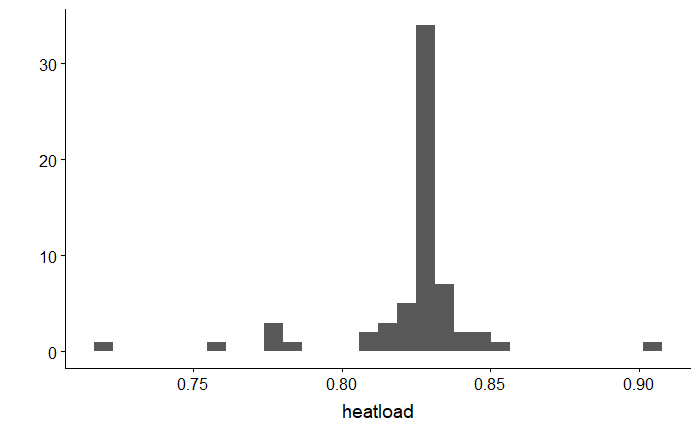

### Add Seedling Data

`r`r fire.seedeffort = read.csv(../data/chapter2_analysis34_seedlingeffort_11december2017.csv, header = TRUE, sep =  
```

|  | plot | seedling.ct | seedling.area |
| --- | --- | --- | --- |
| 1 | 1 | 3 | 4 |
| 2 | 2 | 68 | 4 |
| 3 | 3 | 15 | 4 |
| 4 | 4 | 6 | 4 |
| 5 | 5 | 15 | 4 |
| 6 | 6 | 0 | 4 |

`r`r seedling.weather = merge(postfire.weather, fire.seedeffort, by = c()) head(seedling.weather)

|  | plot | MPB | fire.severity | utm_zone | UTM_E | UTM_N | Elevation | fire.event | fire.year | lat | long | sum_PPT | avg_PPT | sum_NFFD | avg_NFFD | sum_PAS | avg_PAS | sum_CMD | avg_CMD | frost.events | aspect | slope | aspect_rad | foldaspect_rad | slope_rad | lat_degrees | lat_rad | heatload | seedling.ct | … |
| --- | --- | --- | --- | --- | --- | --- | --- | --- | --- | --- | --- | --- | --- | --- | --- | --- | --- | --- | --- | --- | --- | --- | --- | --- | --- | --- | --- | --- | --- | --- |
| 1 | 1 | low | moderate | 10 | 334151 | 5904342 | 937 | chelaslie | 2014 | 53.26237 | -125.4866 | 476 | 39.66667 | 156 | 13.00000 | 184 | 15.33333 | 379 | 31.58333 | 209 | 0 | 5 | 0.000000 | -0.7853982 | 0.08726646 | 53 | 0.9250245 | 0.7800685 | 3 | … |
| 2 | 2 | low | moderate | 10 | 334730 | 5905754 | 1039 | chelaslie | 2014 | 53.27523 | -125.4787 | 482 | 40.16667 | 151 | 12.58333 | 192 | 16.00000 | 365 | 30.41667 | 214 | 155 | 0 | 2.705260 | 1.9198622 | 0.00000000 | 53 | 0.9250245 | 0.8252665 | 68 | … |
| 3 | 3 | low | low | 10 | 334790 | 5905867 | 1043 | chelaslie | 2014 | 53.27626 | -125.4778 | 482 | 40.16667 | 150 | 12.50000 | 194 | 16.16667 | 365 | 30.41667 | 215 | 165 | 2 | 2.879793 | 2.0943951 | 0.03490659 | 53 | 0.9250245 | 0.8279182 | 15 | … |
| 4 | 4 | high | moderate | 10 | 334297 | 5905505 | 1025 | chelaslie | 2014 | 53.27285 | -125.4850 | 484 | 40.33333 | 151 | 12.58333 | 190 | 15.83333 | 366 | 30.50000 | 214 | 168 | 5 | 2.932153 | 2.1467550 | 0.08726646 | 53 | 0.9250245 | 0.8326532 | 6 | … |
| 5 | 5 | low | high | 10 | 334541 | 5905225 | 989 | chelaslie | 2014 | 53.27042 | -125.4812 | 479 | 39.91667 | 153 | 12.75000 | 187 | 15.58333 | 373 | 31.08333 | 212 | 227 | 0 | 3.961897 | 3.1066861 | 0.00000000 | 53 | 0.9250245 | 0.8252665 | 15 | … |
| 6 | 6 | low | low | 10 | 333922 | 5906030 | 1028 | chelaslie | 2014 | 53.27745 | -125.4909 | 487 | 40.58333 | 151 | 12.58333 | 194 | 16.16667 | 364 | 30.33333 | 214 | 264 | 5 | 4.607669 | 2.4609142 | 0.08726646 | 53 | 0.9250245 | 0.8424206 | 0 | … |

### Add Data with canopy structure

`r`r fire = read.csv(../data/2018-09-20_ch2-burnedplots-wcodes-edit43.csv, header = TRUE, sep =  
```

|  | plot | Plot_ID | plot.mpb | stems | bom | fire | live | upf | no.canopy | yes.canopy | no.seed | yes.seed | tot.stem | cone.ct | seed.density | disturbance | fire.type | burncon |
| --- | --- | --- | --- | --- | --- | --- | --- | --- | --- | --- | --- | --- | --- | --- | --- | --- | --- | --- |
| 1 | 1 | CEC0629M1 | LM1 | 7 | 0 | 7 | 0 | 0 | 0 | 7 | 0 | 7 | 7 | 282 | 75 | beetle+fire | sev.surf | moderate |
| 2 | 2 | CEC0630H1 | LM2 | 7 | 0 | 7 | 0 | 0 | 0 | 7 | 0 | 7 | 7 | 1150 | 1700 | beetle+fire | sev.surf | moderate |
| 3 | 3 | CEC0701L1 | LL3 | 42 | 17 | 21 | 3 | 1 | 4 | 38 | 28 | 14 | 42 | 3665 | 375 | beetle+fire | surface | moderate |
| 4 | 4 | CEC0702M1 | HM4 | 12 | 12 | 0 | 0 | 0 | 0 | 12 | 6 | 6 | 12 | 1286 | 150 | beetle+fire | sev.surf | moderate |
| 5 | 5 | CEC0702H1 | LH5 | 24 | 0 | 9 | 0 | 15 | 15 | 9 | 15 | 9 | 24 | 1585 | 375 | beetle+fire | crown | moderate |
| 6 | 6 | CEC0703M1 | LL6 | 20 | 16 | 4 | 0 | 0 | 10 | 10 | 15 | 5 | 20 | 680 | 2 | beetle+fire | surface | moderate |

`r`r seedling.weather = merge(seedling.weather, fire, by = c()) head(seedling.weather)

|  | plot | MPB | fire.severity | utm_zone | UTM_E | UTM_N | Elevation | fire.event | fire.year | lat | long | sum_PPT | avg_PPT | sum_NFFD | avg_NFFD | sum_PAS | avg_PAS | sum_CMD | avg_CMD | frost.events | aspect | slope | aspect_rad | foldaspect_rad | slope_rad | lat_degrees | lat_rad | heatload | seedling.ct | … |
| --- | --- | --- | --- | --- | --- | --- | --- | --- | --- | --- | --- | --- | --- | --- | --- | --- | --- | --- | --- | --- | --- | --- | --- | --- | --- | --- | --- | --- | --- | --- |
| 1 | 1 | low | moderate | 10 | 334151 | 5904342 | 937 | chelaslie | 2014 | 53.26237 | -125.4866 | 476 | 39.66667 | 156 | 13.00000 | 184 | 15.33333 | 379 | 31.58333 | 209 | 0 | 5 | 0.000000 | -0.7853982 | 0.08726646 | 53 | 0.9250245 | 0.7800685 | 3 | … |
| 2 | 2 | low | moderate | 10 | 334730 | 5905754 | 1039 | chelaslie | 2014 | 53.27523 | -125.4787 | 482 | 40.16667 | 151 | 12.58333 | 192 | 16.00000 | 365 | 30.41667 | 214 | 155 | 0 | 2.705260 | 1.9198622 | 0.00000000 | 53 | 0.9250245 | 0.8252665 | 68 | … |
| 3 | 3 | low | low | 10 | 334790 | 5905867 | 1043 | chelaslie | 2014 | 53.27626 | -125.4778 | 482 | 40.16667 | 150 | 12.50000 | 194 | 16.16667 | 365 | 30.41667 | 215 | 165 | 2 | 2.879793 | 2.0943951 | 0.03490659 | 53 | 0.9250245 | 0.8279182 | 15 | … |
| 4 | 4 | high | moderate | 10 | 334297 | 5905505 | 1025 | chelaslie | 2014 | 53.27285 | -125.4850 | 484 | 40.33333 | 151 | 12.58333 | 190 | 15.83333 | 366 | 30.50000 | 214 | 168 | 5 | 2.932153 | 2.1467550 | 0.08726646 | 53 | 0.9250245 | 0.8326532 | 6 | … |
| 5 | 5 | low | high | 10 | 334541 | 5905225 | 989 | chelaslie | 2014 | 53.27042 | -125.4812 | 479 | 39.91667 | 153 | 12.75000 | 187 | 15.58333 | 373 | 31.08333 | 212 | 227 | 0 | 3.961897 | 3.1066861 | 0.00000000 | 53 | 0.9250245 | 0.8252665 | 15 | … |
| 6 | 6 | low | low | 10 | 333922 | 5906030 | 1028 | chelaslie | 2014 | 53.27745 | -125.4909 | 487 | 40.58333 | 151 | 12.58333 | 194 | 16.16667 | 364 | 30.33333 | 214 | 264 | 5 | 4.607669 | 2.4609142 | 0.08726646 | 53 | 0.9250245 | 0.8424206 | 0 | … |

### Additional variables calculated

`r`r seedling.weather = mutate(seedling.weather, prop.bom = bom/stems) seedling.weather = mutate(seedling.weather, prop.canopy = yes.canopy/stems) seedling.weather = mutate(seedling.weather, prop.nocanopy = no.canopy/stems) seedling.weather = mutate(seedling.weather, prop.opencone = yes.seed/stems) seedling.weather = mutate(seedling.weather, prop.closedcone = no.seed/stems) seedling.weather = mutate(seedling.weather, prop.cone.ct = cone.ct/stems) head(seedling.weather)

|  | plot | MPB | fire.severity | utm_zone | UTM_E | UTM_N | Elevation | fire.event | fire.year | lat | long | sum_PPT | avg_PPT | sum_NFFD | avg_NFFD | sum_PAS | avg_PAS | sum_CMD | avg_CMD | frost.events | aspect | slope | aspect_rad | foldaspect_rad | slope_rad | lat_degrees | lat_rad | heatload | seedling.ct | … |
| --- | --- | --- | --- | --- | --- | --- | --- | --- | --- | --- | --- | --- | --- | --- | --- | --- | --- | --- | --- | --- | --- | --- | --- | --- | --- | --- | --- | --- | --- | --- |
| 1 | 1 | low | moderate | 10 | 334151 | 5904342 | 937 | chelaslie | 2014 | 53.26237 | -125.4866 | 476 | 39.66667 | 156 | 13.00000 | 184 | 15.33333 | 379 | 31.58333 | 209 | 0 | 5 | 0.000000 | -0.7853982 | 0.08726646 | 53 | 0.9250245 | 0.7800685 | 3 | … |
| 2 | 2 | low | moderate | 10 | 334730 | 5905754 | 1039 | chelaslie | 2014 | 53.27523 | -125.4787 | 482 | 40.16667 | 151 | 12.58333 | 192 | 16.00000 | 365 | 30.41667 | 214 | 155 | 0 | 2.705260 | 1.9198622 | 0.00000000 | 53 | 0.9250245 | 0.8252665 | 68 | … |
| 3 | 3 | low | low | 10 | 334790 | 5905867 | 1043 | chelaslie | 2014 | 53.27626 | -125.4778 | 482 | 40.16667 | 150 | 12.50000 | 194 | 16.16667 | 365 | 30.41667 | 215 | 165 | 2 | 2.879793 | 2.0943951 | 0.03490659 | 53 | 0.9250245 | 0.8279182 | 15 | … |
| 4 | 4 | high | moderate | 10 | 334297 | 5905505 | 1025 | chelaslie | 2014 | 53.27285 | -125.4850 | 484 | 40.33333 | 151 | 12.58333 | 190 | 15.83333 | 366 | 30.50000 | 214 | 168 | 5 | 2.932153 | 2.1467550 | 0.08726646 | 53 | 0.9250245 | 0.8326532 | 6 | … |
| 5 | 5 | low | high | 10 | 334541 | 5905225 | 989 | chelaslie | 2014 | 53.27042 | -125.4812 | 479 | 39.91667 | 153 | 12.75000 | 187 | 15.58333 | 373 | 31.08333 | 212 | 227 | 0 | 3.961897 | 3.1066861 | 0.00000000 | 53 | 0.9250245 | 0.8252665 | 15 | … |
| 6 | 6 | low | low | 10 | 333922 | 5906030 | 1028 | chelaslie | 2014 | 53.27745 | -125.4909 | 487 | 40.58333 | 151 | 12.58333 | 194 | 16.16667 | 364 | 30.33333 | 214 | 264 | 5 | 4.607669 | 2.4609142 | 0.08726646 | 53 | 0.9250245 | 0.8424206 | 0 | … |

`r`r seedling.weather

| plot | MPB | fire.severity | utm_zone | UTM_E | UTM_N | Elevation | fire.event | fire.year | lat | long | sum_PPT | avg_PPT | sum_NFFD | avg_NFFD | sum_PAS | avg_PAS | sum_CMD | avg_CMD | frost.events | aspect | slope | aspect_rad | foldaspect_rad | slope_rad | lat_degrees | lat_rad | heatload | seedling.ct | seedling.area | … |
| --- | --- | --- | --- | --- | --- | --- | --- | --- | --- | --- | --- | --- | --- | --- | --- | --- | --- | --- | --- | --- | --- | --- | --- | --- | --- | --- | --- | --- | --- | --- |
| 1 | low | moderate | 10 | 334151 | 5904342 | 937 | chelaslie | 2014 | 53.26237 | -125.4866 | 476 | 39.66667 | 156 | 13.00000 | 184 | 15.33333 | 379 | 31.58333 | 209 | 0 | 5.0 | 0.00000000 | -0.78539816 | 0.087266463 | 53 | 0.9250245 | 0.7800685 | 3 | 4 | … |
| 2 | low | moderate | 10 | 334730 | 5905754 | 1039 | chelaslie | 2014 | 53.27523 | -125.4787 | 482 | 40.16667 | 151 | 12.58333 | 192 | 16.00000 | 365 | 30.41667 | 214 | 155 | 0.0 | 2.70526034 | 1.91986218 | 0.000000000 | 53 | 0.9250245 | 0.8252665 | 68 | 4 | … |
| 3 | low | low | 10 | 334790 | 5905867 | 1043 | chelaslie | 2014 | 53.27626 | -125.4778 | 482 | 40.16667 | 150 | 12.50000 | 194 | 16.16667 | 365 | 30.41667 | 215 | 165 | 2.0 | 2.87979327 | 2.09439510 | 0.034906585 | 53 | 0.9250245 | 0.8279182 | 15 | 4 | … |
| 4 | high | moderate | 10 | 334297 | 5905505 | 1025 | chelaslie | 2014 | 53.27285 | -125.4850 | 484 | 40.33333 | 151 | 12.58333 | 190 | 15.83333 | 366 | 30.50000 | 214 | 168 | 5.0 | 2.93215314 | 2.14675498 | 0.087266463 | 53 | 0.9250245 | 0.8326532 | 6 | 4 | … |
| 5 | low | high | 10 | 334541 | 5905225 | 989 | chelaslie | 2014 | 53.27042 | -125.4812 | 479 | 39.91667 | 153 | 12.75000 | 187 | 15.58333 | 373 | 31.08333 | 212 | 227 | 0.0 | 3.96189740 | 3.10668607 | 0.000000000 | 53 | 0.9250245 | 0.8252665 | 15 | 4 | … |
| 6 | low | low | 10 | 333922 | 5906030 | 1028 | chelaslie | 2014 | 53.27745 | -125.4909 | 487 | 40.58333 | 151 | 12.58333 | 194 | 16.16667 | 364 | 30.33333 | 214 | 264 | 5.0 | 4.60766923 | 2.46091425 | 0.087266463 | 53 | 0.9250245 | 0.8424206 | 0 | 4 | … |
| 7 | high | high | 10 | 334510 | 5904882 | 960 | chelaslie | 2014 | 53.26733 | -125.4815 | 477 | 39.75000 | 155 | 12.91667 | 184 | 15.33333 | 376 | 31.33333 | 210 | 234 | 20.0 | 4.08407045 | 2.98451302 | 0.349065850 | 53 | 0.9250245 | 0.9052279 | 4 | 4 | … |
| 8 | moderate | high | 10 | 334391 | 5904692 | 949 | chelaslie | 2014 | 53.26558 | -125.4832 | 477 | 39.75000 | 155 | 12.91667 | 184 | 15.33333 | 377 | 31.41667 | 210 | 188 | 2.0 | 3.28121899 | 2.49582083 | 0.034906585 | 53 | 0.9250245 | 0.8329417 | 6 | 4 | … |
| 9 | low | high | 10 | 335119 | 5904973 | 985 | chelaslie | 2014 | 53.26833 | -125.4724 | 476 | 39.66667 | 154 | 12.83333 | 186 | 15.50000 | 374 | 31.16667 | 211 | 146 | 2.0 | 2.54818071 | 1.76278254 | 0.034906585 | 53 | 0.9250245 | 0.8227171 | 6 | 4 | … |
| 10 | low | high | 10 | 334978 | 5905205 | 997 | chelaslie | 2014 | 53.27037 | -125.4747 | 477 | 39.75000 | 152 | 12.66667 | 186 | 15.50000 | 372 | 31.00000 | 213 | 205 | 1.0 | 3.57792497 | 2.79252680 | 0.017453293 | 53 | 0.9250245 | 0.8303654 | 5 | 4 | … |

[output cut: 53 more lines]

# Analayses: Postfire Climate & Fire Severity

## Model: Frost*Fire

`r`r frostfire1 = glm.nb(seedling.ct ~ frost.events:fire.type + offset(log(seedling.area)), data = seedling.weather)

### Residuals with DHARMa

`r`r plotSimulatedResiduals(simulationOutput = frostfire1.res)

```
plotSimulatedResiduals is deprecated, switch your code to using the plot function
```

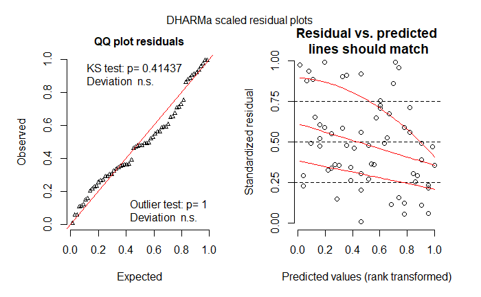

`r`r testOverdispersion(frostfire1.res)

```
testOverdispersion is deprecated, switch your code to using the testDispersion function

    DHARMa nonparametric dispersion test via sd of residuals fitted vs. simulated

data:  simulationOutput
ratioObsSim = 0.948, p-value = 0.992
alternative hypothesis: two.sided
```

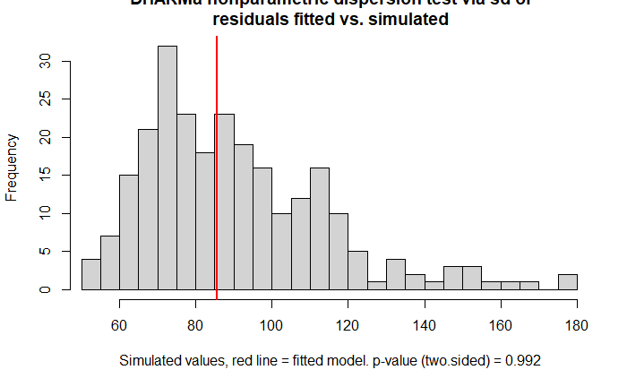

### Summary

`r`r summary(frostfire1)

```
Call:
glm.nb(formula = seedling.ct ~ frost.events:fire.type + offset(log(seedling.area)),
    data = seedling.weather, init.theta = 0.7238363269, link = log)

Deviance Residuals:
     Min        1Q    Median        3Q       Max
-2.49411  -0.99047  -0.49986   0.03758   2.74502

Coefficients:
                               Estimate Std. Error z value Pr(>|z|)
(Intercept)                     3.21839    4.30018   0.748    0.454
frost.events:fire.typecrown    -0.01271    0.02012  -0.631    0.528
frost.events:fire.typesev.surf -0.01189    0.02025  -0.587    0.557
frost.events:fire.typesurface  -0.01573    0.02025  -0.777    0.437

(Dispersion parameter for Negative Binomial(0.7238) family taken to be 1)

    Null deviance: 79.703  on 62  degrees of freedom
Residual deviance: 74.832  on 59  degrees of freedom
AIC: 607.76

Number of Fisher Scoring iterations: 1

              Theta:  0.724
          Std. Err.:  0.119

 2 x log-likelihood:  -597.757
```

### Estimates

`r`r ( frostfire1.est = cbind(Estimate = coef(frostfire1), confint(frostfire1)))

```
                                  Estimate       2.5 %      97.5 %
(Intercept)                     3.21839375 -7.99672804 14.12583221
frost.events:fire.typecrown    -0.01270596 -0.06402942  0.04057286
frost.events:fire.typesev.surf -0.01188538 -0.06238007  0.04034788
frost.events:fire.typesurface  -0.01573329 -0.06702267  0.03740323
```

`r`r ( exp(frostfire1.est))

```
                                 Estimate       2.5 %       97.5 %
(Intercept)                    24.9879510 0.000336562 1.363864e+06
frost.events:fire.typecrown     0.9873744 0.937977404 1.041407e+00
frost.events:fire.typesev.surf  0.9881850 0.939525731 1.041173e+00
frost.events:fire.typesurface   0.9843898 0.935173998 1.038112e+00
```

`r`r (frost_estimate=exp(coef(frostfire1)))

```
                   (Intercept)    frost.events:fire.typecrown frost.events:fire.typesev.surf
                    24.9879510                      0.9873744                      0.9881850
 frost.events:fire.typesurface
                     0.9843898
```

`r`r (frost_lcl_ucl=exp(confint(frostfire1)))

```
                                     2.5 %       97.5 %
(Intercept)                    0.000336562 1.363864e+06
frost.events:fire.typecrown    0.937977404 1.041407e+00
frost.events:fire.typesev.surf 0.939525731 1.041173e+00
frost.events:fire.typesurface  0.935173998 1.038112e+00
```

`r`r (frost_p_value=summary(frostfire1)$coefficients[,4] )

```
                   (Intercept)    frost.events:fire.typecrown frost.events:fire.typesev.surf
                     0.4541993                      0.5277679                      0.5573190
 frost.events:fire.typesurface
                     0.4372223
```

### Predict Frost*Fire

`r`r preddat.frostfire1 = data.frame(frost.events = seedling.weather$frost.events, fire.type = factor(seedling.weather$fire.type), seedling.area = 100) head(preddat.frostfire1) r predfrostfire1 = predict(frostfire1, newdata = preddat.frostfire1, se.fit = TRUE) ULfrostfire1 = with(predfrostfire1, fit + 1.96*se.fit) LLfrostfire1 = with(predfrostfire1, fit - 1.96*se.fit) seedling.weather = mutate(seedling.weather, predfrostfire1 = exp(predfrostfire1$fit), ULfrostfire1 = exp(ULfrostfire1), LLfrostfire1 = exp(LLfrostfire1), seedling.area = 100)

|  | frost.events | fire.type | seedling.area |
| --- | --- | --- | --- |
| 1 | 209 | sev.surf | 100 |
| 2 | 214 | sev.surf | 100 |
| 3 | 215 | surface | 100 |
| 4 | 214 | sev.surf | 100 |
| 5 | 212 | crown | 100 |
| 6 | 214 | surface | 100 |

### Figure with raw data

`r`r pfrostfire1 = ggplot(data = seedling.weather, aes(x = frost.events, y = seedling.ct, color = factor(fire.type))) + geom_point(size = 2) + geom_line(aes(y=LLfrostfire1, color = factor(fire.type)), linetype = ‘longdash’, size = 1) + geom_line(aes(y=ULfrostfire1, color = factor(fire.type)), linetype=‘longdash’, size = 1) + scale_linetype(guide = ) pfrostfire2 = pfrostfire1 + geom_ribbon(aes(ymin=LLfrostfire1, ymax=ULfrostfire1, fill= fire.type), linetype = 0, alpha=.25, show.legend = FALSE) + scale_fill_manual(values=c(#f03b20, #feb24c, #91cf60), guide = FALSE) ( pfrostfire3 = pfrostfire2 + geom_line(aes(y = predfrostfire1, color = factor(fire.type)), linetype = 1, size = 2) + scale_color_manual(values = c(#f03b20, #feb24c, #91cf60), name=Severity, breaks=c(, .surf, ), labels=c(, surface, surface)) + ylab(count) + xlab(Frost Days) + theme_bw() + theme(legend.position = ) + theme(plot.margin = unit(c(t = 0.3, r = 0.1, b = 0.3, l = 0.1), )) + theme(axis.title.x = element_text(size = 11, hjust = 0.5, vjust = -0.1), axis.title.y = element_text(size = 11, hjust = 0.5, vjust = 1.1), axis.text.x = element_text(size = 10, color = ), axis.text.y = element_text(size = 10, color = ), panel.background = element_blank(), axis.line = element_line(colour = )) )

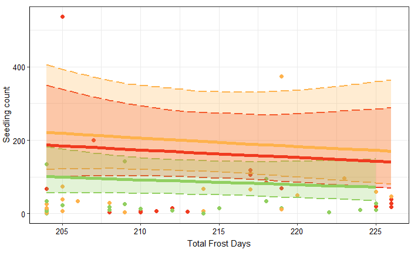

### Figure without raw data

`r`r pfrostfire4 = ggplot(data = seedling.weather, aes(x = frost.events, y = seedling.ct, color = factor(fire.type))) + geom_line(aes(y=LLfrostfire1, color = factor(fire.type)), linetype = ‘longdash’, size = 1) + geom_line(aes(y=ULfrostfire1, color = factor(fire.type)), linetype=‘longdash’, size = 1) + scale_linetype(guide = ) pfrostfire5 = pfrostfire4 + geom_ribbon(aes(ymin=LLfrostfire1, ymax=ULfrostfire1, fill= fire.type), linetype = 0, alpha=.25, show.legend = FALSE) + scale_fill_manual(values=c(#f03b20, #feb24c, #91cf60), guide = FALSE) ( pfrostfire6 = pfrostfire5 + geom_line(aes(y = predfrostfire1, color = factor(fire.type)), linetype = 1, size = 2) + scale_color_manual(values = c(#f03b20, #feb24c, #91cf60), name=Severity, breaks=c(, .surf, ), labels=c(, surface, surface)) + ylab(count) + xlab(events (days)) + theme_bw() + theme(legend.position = ) + theme(plot.margin = unit(c(t = 0.3, r = 0.1, b = 0.3, l = 0.1), )) + theme(axis.title.x = element_text(size = 11, hjust = 0.5, vjust = -0.1), axis.title.y = element_text(size = 11, hjust = 0.5, vjust = 1.1), axis.text.x = element_text(size = 10, color = ), axis.text.y = element_text(size = 10, color = ), panel.background = element_blank(), axis.line = element_line(colour = )) )

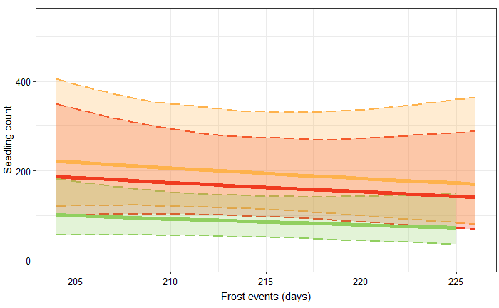

## Model: Snow & fire

`r`r snowfire1 = glm.nb(seedling.ct ~ sum_PAS:fire.type + offset(log(seedling.area)), data = seedling.weather)

### Residuals with DHARMa

`r`r plotSimulatedResiduals(simulationOutput = snowfire1.res)

```
plotSimulatedResiduals is deprecated, switch your code to using the plot function
```

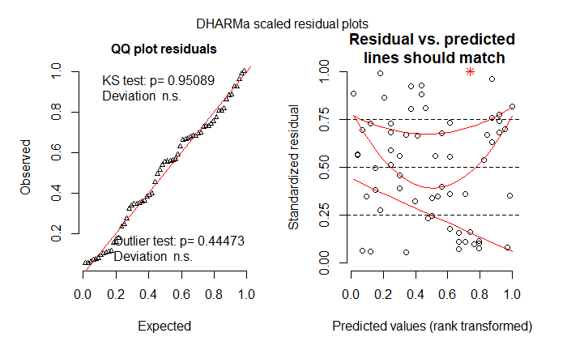

`r`r testOverdispersion(snowfire1.res)

```
testOverdispersion is deprecated, switch your code to using the testDispersion function

    DHARMa nonparametric dispersion test via sd of residuals fitted vs. simulated

data:  simulationOutput
ratioObsSim = 1.2315, p-value = 0.312
alternative hypothesis: two.sided
```

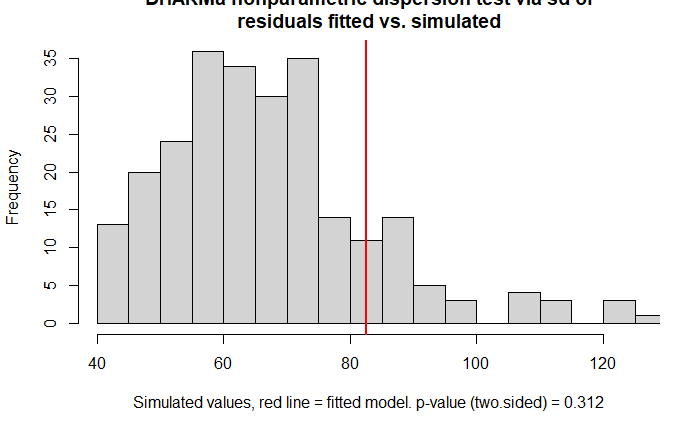

### Summary

`r`r summary(snowfire1)

```
Call:
glm.nb(formula = seedling.ct ~ sum_PAS:fire.type + offset(log(seedling.area)),
    data = seedling.weather, init.theta = 0.702587106, link = log)

Deviance Residuals:
    Min       1Q   Median       3Q      Max
-2.3182  -1.0757  -0.3543   0.1608   2.6072

Coefficients:
                          Estimate Std. Error z value Pr(>|z|)
(Intercept)               13.06764    5.40986   2.416  0.01571 *
sum_PAS:fire.typecrown    -0.07274    0.02907  -2.502  0.01236 *
sum_PAS:fire.typesev.surf -0.07286    0.02893  -2.519  0.01178 *
sum_PAS:fire.typesurface  -0.07688    0.02882  -2.668  0.00763 **
---
Signif. codes:  0 â***â 0.001 â**â 0.01 â*â 0.05 â.â 0.1 â â 1

(Dispersion parameter for Negative Binomial(0.7026) family taken to be 1)

    Null deviance: 87.394  on 62  degrees of freedom
Residual deviance: 74.853  on 59  degrees of freedom
AIC: 609.82

Number of Fisher Scoring iterations: 1

              Theta:  0.703
          Std. Err.:  0.115

 2 x log-likelihood:  -599.823
```

### Estimates

`r`r ( snowfire1.est = cbind(Estimate = coef(snowfire1), confint(snowfire1)))

```
                             Estimate      2.5 %      97.5 %
(Intercept)               13.06764330  2.7046756 22.94649991
sum_PAS:fire.typecrown    -0.07274022 -0.1256859 -0.01670516
sum_PAS:fire.typesev.surf -0.07285672 -0.1251136 -0.01751634
sum_PAS:fire.typesurface  -0.07688247 -0.1295277 -0.02129044
```

`r`r ( exp(snowfire1.est))

```
                              Estimate      2.5 %       97.5 %
(Intercept)               4.733751e+05 14.9494666 9.237156e+09
sum_PAS:fire.typecrown    9.298424e-01  0.8818918 9.834336e-01
sum_PAS:fire.typesev.surf 9.297340e-01  0.8823966 9.826362e-01
sum_PAS:fire.typesurface  9.259987e-01  0.8785103 9.789346e-01
```

`r`r snow_estimate=exp(coef(snowfire1)) snow_lcl_ucl=exp(confint(snowfire1))

`r`r snow_p_value=summary(snowfire1)$coefficients[,4]

`r`r preddat.snowfire1 = data.frame(sum_PAS = seedling.weather$sum_PAS, fire.type = factor(seedling.weather$fire.type), seedling.area = 100) head(preddat.snowfire1) r predsnowfire1 = predict(snowfire1, newdata = preddat.snowfire1, se.fit = TRUE) ULsnowfire1 = with(predsnowfire1, fit + 1.96*se.fit) LLsnowfire1 = with(predsnowfire1, fit - 1.96*se.fit) seedling.weather = mutate(seedling.weather, predsnowfire1 = exp(predsnowfire1$fit), ULsnowfire1 = exp(ULsnowfire1), LLsnowfire1 = exp(LLsnowfire1), seedling.area = 100)

|  | sum_PAS | fire.type | seedling.area |
| --- | --- | --- | --- |
| 1 | 184 | sev.surf | 100 |
| 2 | 192 | sev.surf | 100 |
| 3 | 194 | surface | 100 |
| 4 | 190 | sev.surf | 100 |
| 5 | 187 | crown | 100 |
| 6 | 194 | surface | 100 |

### Figure with raw data

`r`r psnowfire1 = ggplot(data = seedling.weather, aes(x = sum_PAS, y = seedling.ct, color = factor(fire.type))) + geom_point(size = 2) + geom_line(aes(y=LLsnowfire1, color = factor(fire.type)), linetype = ‘longdash’, size = 1) + geom_line(aes(y=ULsnowfire1, color = factor(fire.type)), linetype=‘longdash’, size = 1) + scale_linetype(guide = ) psnowfire2 = psnowfire1 + geom_ribbon(aes(ymin=LLsnowfire1, ymax=ULsnowfire1, fill= fire.type), linetype = 0, alpha=.25, show.legend = FALSE) + scale_fill_manual(values=c(#f03b20, #feb24c, #91cf60), guide = FALSE)  
( psnowfire3 = psnowfire2 + geom_line(aes(y = predsnowfire1, color = factor(fire.type)), linetype = 1, size = 2) + scale_color_manual(values = c(#f03b20, #feb24c, #91cf60), name=Severity, breaks=c(, .surf, ), labels=c(, surface, surface)) + ylab(count) + xlab((mm)) + theme_bw() + theme(legend.position = ) + theme(plot.margin = unit(c(t = 0.3, r = 0.1, b = 0.3, l = 0.1), )) + theme(axis.title.x = element_text(size = 11, hjust = 0.5, vjust = -0.1), axis.title.y = element_text(size = 11, hjust = 0.5, vjust = 1.1), axis.text.x = element_text(size = 10, color = ), axis.text.y = element_text(size = 10, color = ), panel.background = element_blank(), axis.line = element_line(colour = )) )

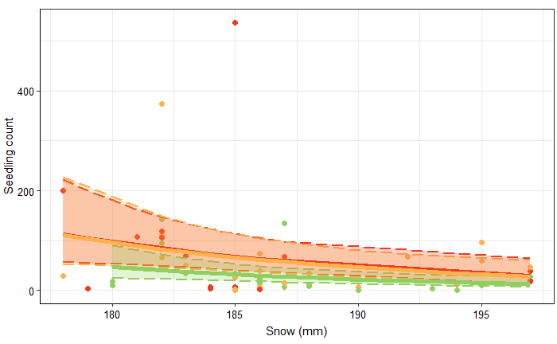

### Figure without raw data

`r`r psnowfire4 = ggplot(data = seedling.weather, aes(x = sum_PAS, y = seedling.ct, color = factor(fire.type))) +  
geom_line(aes(y=LLsnowfire1, color = factor(fire.type)), linetype = ‘longdash’, size = 1) + geom_line(aes(y=ULsnowfire1, color = factor(fire.type)), linetype=‘longdash’, size = 1) + scale_linetype(guide = ) psnowfire5 = psnowfire4 + geom_ribbon(aes(ymin=LLsnowfire1, ymax=ULsnowfire1, fill= fire.type), linetype = 0, alpha=.25, show.legend = FALSE) + scale_fill_manual(values=c(#f03b20, #feb24c, #91cf60), guide = FALSE)  
( psnowfire6 = psnowfire5 + geom_line(aes(y = predsnowfire1, color = factor(fire.type)), linetype = 1, size = 2) + scale_color_manual(values = c(#f03b20, #feb24c, #91cf60), name=Severity, breaks=c(, .surf, ), labels=c(, surface, surface)) + ylab(count) + xlab(accumulation (mm)) + ylim(0,300) + theme_bw() + theme(legend.position = ) + theme(plot.margin = unit(c(t = 0.3, r = 0.1, b = 0.3, l = 0.1), )) + theme(axis.title.x = element_text(size = 11, hjust = 0.5, vjust = -0.1), axis.title.y = element_text(size = 11, hjust = 0.5, vjust = 1.1), axis.text.x = element_text(size = 10, color = ), axis.text.y = element_text(size = 10, color = ), panel.background = element_blank(), axis.line = element_line(colour = )) )

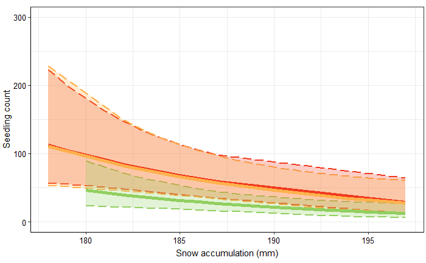

## Model: CMD & fire

`r`r CMDfire1 = glm.nb(seedling.ct ~ sum_CMD:fire.type + offset(log(seedling.area)), data = seedling.weather)

### Residuals with DHARMa

In the plot below we are looking for the points in the QQ plot to fall along the RED lines. In the Residuals vs.predicted plot were are looking for the lines to be relatively horizontal. All looks good.

`r`r plotSimulatedResiduals(simulationOutput = CMDfire1.res)

```
plotSimulatedResiduals is deprecated, switch your code to using the plot function
```

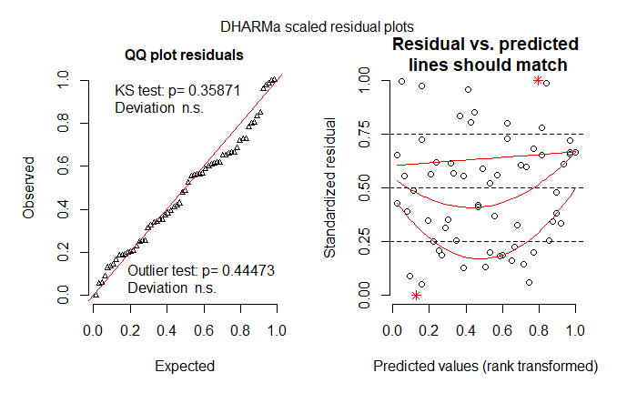

`r`r testOverdispersion(CMDfire1.res)

```
testOverdispersion is deprecated, switch your code to using the testDispersion function

    DHARMa nonparametric dispersion test via sd of residuals fitted vs. simulated

data:  simulationOutput
ratioObsSim = 1.2543, p-value = 0.32
alternative hypothesis: two.sided
```

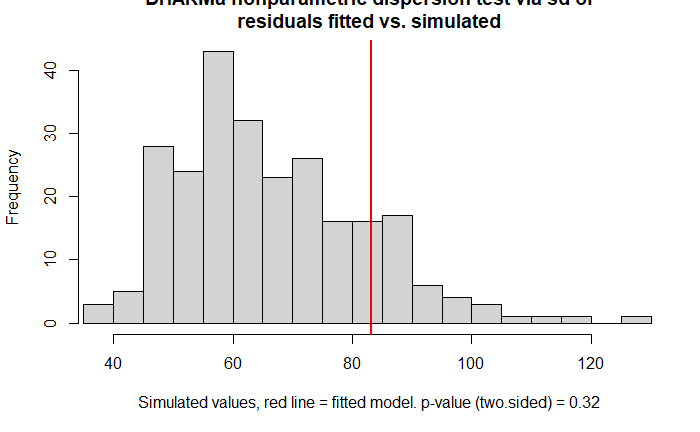

### Summary

`r`r summary(CMDfire1)

```
Call:
glm.nb(formula = seedling.ct ~ sum_CMD:fire.type + offset(log(seedling.area)),
    data = seedling.weather, init.theta = 0.6659619508, link = log)

Deviance Residuals:
     Min        1Q    Median        3Q       Max
-2.24842  -1.16881  -0.43699   0.01479   2.56909

Coefficients:
                           Estimate Std. Error z value Pr(>|z|)
(Intercept)                4.378454   3.347131   1.308   0.1908
sum_CMD:fire.typecrown    -0.013327   0.009360  -1.424   0.1545
sum_CMD:fire.typesev.surf -0.014406   0.009509  -1.515   0.1298
sum_CMD:fire.typesurface  -0.015560   0.009361  -1.662   0.0965 .
---
Signif. codes:  0 â***â 0.001 â**â 0.01 â*â 0.05 â.â 0.1 â â 1

(Dispersion parameter for Negative Binomial(0.666) family taken to be 1)

    Null deviance: 83.152  on 62  degrees of freedom
Residual deviance: 75.277  on 59  degrees of freedom
AIC: 613.95

Number of Fisher Scoring iterations: 1

              Theta:  0.666
          Std. Err.:  0.108

 2 x log-likelihood:  -603.953
```

### Estimates

`r`r ( CMDfire1.est = cbind(Estimate = coef(CMDfire1), confint(CMDfire1)))

```
                             Estimate       2.5 %       97.5 %
(Intercept)                4.37845373 -1.84274727 10.643040700
sum_CMD:fire.typecrown    -0.01332738 -0.03063897  0.004178586
sum_CMD:fire.typesev.surf -0.01440646 -0.03242527  0.003707262
sum_CMD:fire.typesurface  -0.01556042 -0.03272425  0.001713166
```

`r`r ( exp(CMDfire1.est))

```
                            Estimate     2.5 %       97.5 %
(Intercept)               79.7146779 0.1583817 41899.983007
sum_CMD:fire.typecrown     0.9867610 0.9698256     1.004187
sum_CMD:fire.typesev.surf  0.9856968 0.9680948     1.003714
sum_CMD:fire.typesurface   0.9845600 0.9678054     1.001715
```

`r`r cmd_estimate=exp(coef(CMDfire1)) cmd_lcl_ucl=exp(confint(CMDfire1))

`r`r cmd_p_value=summary(CMDfire1)$coefficients[,4]

`r`r sum_df=data.frame(frost_estimate, frost_lcl_ucl, frost_p_value, snow_estimate, snow_lcl_ucl, snow_p_value, cmd_estimate, cmd_lcl_ucl, cmd_p_value) sum_df r write.csv(sum_df, ‘../output/2019-02-06_climate_fire_summary.csv’, row.names = F)

|  | frost_estimate | X2.5.. | X97.5.. | frost_p_value | snow_estimate | X2.5...1 | X97.5...1 | snow_p_value | cmd_estimate | X2.5...2 | X97.5...2 | cmd_p_value |
| --- | --- | --- | --- | --- | --- | --- | --- | --- | --- | --- | --- | --- |
| (Intercept) | 24.9879510 | 0.000336562 | 1.363864e+06 | 0.4541993 | 4.733751e+05 | 14.9494666 | 9.237156e+09 | 0.015712622 | 79.7146779 | 0.1583817 | 41899.983007 | 0.19083207 |
| frost.events:fire.typecrown | 0.9873744 | 0.937977404 | 1.041407e+00 | 0.5277679 | 9.298424e-01 | 0.8818918 | 9.834336e-01 | 0.012355423 | 0.9867610 | 0.9698256 | 1.004187 | 0.15448293 |
| frost.events:fire.typesev.surf | 0.9881850 | 0.939525731 | 1.041173e+00 | 0.5573190 | 9.297340e-01 | 0.8823966 | 9.826362e-01 | 0.011775969 | 0.9856968 | 0.9680948 | 1.003714 | 0.12977965 |
| frost.events:fire.typesurface | 0.9843898 | 0.935173998 | 1.038112e+00 | 0.4372223 | 9.259987e-01 | 0.8785103 | 9.789346e-01 | 0.007633565 | 0.9845600 | 0.9678054 | 1.001715 | 0.09647649 |

### Predict CMD Data

`r`r preddat.cmdfire1 = data.frame(sum_CMD = seedling.weather$sum_CMD, fire.type = factor(seedling.weather$fire.type), seedling.area = 100) head(preddat.cmdfire1) r predcmdfire1 = predict(CMDfire1, newdata = preddat.cmdfire1, se.fit = TRUE) ULcmdfire1 = with(predcmdfire1, fit + 1.96*se.fit) LLcmdfire1 = with(predcmdfire1, fit - 1.96*se.fit) seedling.weather = mutate(seedling.weather, predcmdfire1 = exp(predcmdfire1$fit), ULcmdfire1 = exp(ULcmdfire1), LLcmdfire1 = exp(LLcmdfire1), seedling.area = 100)

|  | sum_CMD | fire.type | seedling.area |
| --- | --- | --- | --- |
| 1 | 379 | sev.surf | 100 |
| 2 | 365 | sev.surf | 100 |
| 3 | 365 | surface | 100 |
| 4 | 366 | sev.surf | 100 |
| 5 | 373 | crown | 100 |
| 6 | 364 | surface | 100 |

### Figure with raw data

`r`r pcmdfire1 = ggplot(data = seedling.weather, aes(x = sum_CMD, y = seedling.ct, color = factor(fire.type))) + geom_point(size = 2) + geom_line(aes(y=LLcmdfire1, color = factor(fire.type)), linetype = ‘longdash’, size = 1) + geom_line(aes(y=ULcmdfire1, color = factor(fire.type)), linetype=‘longdash’, size = 1) + scale_linetype(guide = ) pcmdfire2 = pcmdfire1 + geom_ribbon(aes(ymin=LLcmdfire1, ymax=ULcmdfire1, fill= fire.type), linetype = 0, alpha=.25, show.legend = FALSE) + scale_fill_manual(values=c(#f03b20, #feb24c, #91cf60), guide = FALSE)  
( pcmdfire3 = pcmdfire2 + geom_line(aes(y = predcmdfire1, color = factor(fire.type)), linetype = 1, size = 2) + scale_color_manual(values = c(#f03b20, #feb24c, #91cf60), name=Severity, breaks=c(, .surf, ), labels=c(, surface, surface)) + ylab(count) + xlab() + theme_bw() + theme(legend.position = ) + theme(plot.margin = unit(c(t = 0.3, r = 0.1, b = 0.3, l = 0.1), )) + theme(axis.title.x = element_text(size = 11, hjust = 0.5, vjust = -0.1), axis.title.y = element_text(size = 11, hjust = 0.5, vjust = 1.1), axis.text.x = element_text(size = 10, color = ), axis.text.y = element_text(size = 10, color = ), panel.background = element_blank(), axis.line = element_line(colour = )) )

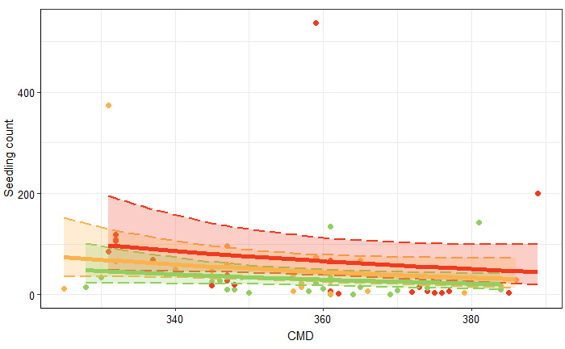

### Figure without raw data

`r`r pcmdfire4 = ggplot(data = seedling.weather, aes(x = sum_CMD, y = seedling.ct, color = factor(fire.type))) + geom_line(aes(y=LLcmdfire1, color = factor(fire.type)), linetype = ‘longdash’, size = 1) + geom_line(aes(y=ULcmdfire1, color = factor(fire.type)), linetype=‘longdash’, size = 1) + scale_linetype(guide = ) pcmdfire5 = pcmdfire4 + geom_ribbon(aes(ymin=LLcmdfire1, ymax=ULcmdfire1, fill= fire.type), linetype = 0, alpha=.25, show.legend = FALSE) + scale_fill_manual(values=c(#f03b20, #feb24c, #91cf60), guide = FALSE)  
( pcmdfire6 = pcmdfire5 + geom_line(aes(y = predcmdfire1, color = factor(fire.type)), linetype = 1, size = 2) + scale_color_manual(values = c(#f03b20, #feb24c, #91cf60), name=Severity, breaks=c(, .surf, ), labels=c(, surface, surface)) + ylab(count) + xlab(moisture deficit (mm)) + ylim(0, 200) + theme_bw() + theme(legend.position = ) + theme(plot.margin = unit(c(t = 0.3, r = 0.1, b = 0.3, l = 0.1), )) + theme(axis.title.x = element_text(size = 11, hjust = 0.5, vjust = -0.1), axis.title.y = element_text(size = 11, hjust = 0.5, vjust = 1.1), axis.text.x = element_text(size = 10, color = ), axis.text.y = element_text(size = 10, color = ), panel.background = element_blank(), axis.line = element_line(colour = )) )

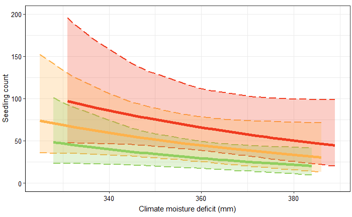

# Remove outliers

Outliers: Plots - 27, 34, 40

`r`r head(seedling.weather)

|  | plot | MPB | fire.severity | utm_zone | UTM_E | UTM_N | Elevation | fire.event | fire.year | lat | long | sum_PPT | avg_PPT | sum_NFFD | avg_NFFD | sum_PAS | avg_PAS | sum_CMD | avg_CMD | frost.events | aspect | slope | aspect_rad | foldaspect_rad | slope_rad | lat_degrees | lat_rad | heatload | seedling.ct | … |
| --- | --- | --- | --- | --- | --- | --- | --- | --- | --- | --- | --- | --- | --- | --- | --- | --- | --- | --- | --- | --- | --- | --- | --- | --- | --- | --- | --- | --- | --- | --- |
| 1 | 1 | low | moderate | 10 | 334151 | 5904342 | 937 | chelaslie | 2014 | 53.26237 | -125.4866 | 476 | 39.66667 | 156 | 13.00000 | 184 | 15.33333 | 379 | 31.58333 | 209 | 0 | 5 | 0.000000 | -0.7853982 | 0.08726646 | 53 | 0.9250245 | 0.7800685 | 3 | … |
| 2 | 2 | low | moderate | 10 | 334730 | 5905754 | 1039 | chelaslie | 2014 | 53.27523 | -125.4787 | 482 | 40.16667 | 151 | 12.58333 | 192 | 16.00000 | 365 | 30.41667 | 214 | 155 | 0 | 2.705260 | 1.9198622 | 0.00000000 | 53 | 0.9250245 | 0.8252665 | 68 | … |
| 3 | 3 | low | low | 10 | 334790 | 5905867 | 1043 | chelaslie | 2014 | 53.27626 | -125.4778 | 482 | 40.16667 | 150 | 12.50000 | 194 | 16.16667 | 365 | 30.41667 | 215 | 165 | 2 | 2.879793 | 2.0943951 | 0.03490659 | 53 | 0.9250245 | 0.8279182 | 15 | … |
| 4 | 4 | high | moderate | 10 | 334297 | 5905505 | 1025 | chelaslie | 2014 | 53.27285 | -125.4850 | 484 | 40.33333 | 151 | 12.58333 | 190 | 15.83333 | 366 | 30.50000 | 214 | 168 | 5 | 2.932153 | 2.1467550 | 0.08726646 | 53 | 0.9250245 | 0.8326532 | 6 | … |
| 5 | 5 | low | high | 10 | 334541 | 5905225 | 989 | chelaslie | 2014 | 53.27042 | -125.4812 | 479 | 39.91667 | 153 | 12.75000 | 187 | 15.58333 | 373 | 31.08333 | 212 | 227 | 0 | 3.961897 | 3.1066861 | 0.00000000 | 53 | 0.9250245 | 0.8252665 | 15 | … |
| 6 | 6 | low | low | 10 | 333922 | 5906030 | 1028 | chelaslie | 2014 | 53.27745 | -125.4909 | 487 | 40.58333 | 151 | 12.58333 | 194 | 16.16667 | 364 | 30.33333 | 214 | 264 | 5 | 4.607669 | 2.4609142 | 0.08726646 | 53 | 0.9250245 | 0.8424206 | 0 | … |

`r`r seed_clim_out = subset(seedling.weather, plot != 27 & plot != 34 & plot != 40) seed_clim_out

|  | plot | MPB | fire.severity | utm_zone | UTM_E | UTM_N | Elevation | fire.event | fire.year | lat | long | sum_PPT | avg_PPT | sum_NFFD | avg_NFFD | sum_PAS | avg_PAS | sum_CMD | avg_CMD | frost.events | aspect | slope | aspect_rad | foldaspect_rad | slope_rad | lat_degrees | lat_rad | heatload | seedling.ct | … |
| --- | --- | --- | --- | --- | --- | --- | --- | --- | --- | --- | --- | --- | --- | --- | --- | --- | --- | --- | --- | --- | --- | --- | --- | --- | --- | --- | --- | --- | --- | --- |
| 1 | 1 | low | moderate | 10 | 334151 | 5904342 | 937 | chelaslie | 2014 | 53.26237 | -125.4866 | 476 | 39.66667 | 156 | 13.00000 | 184 | 15.33333 | 379 | 31.58333 | 209 | 0 | 5.0 | 0.00000000 | -0.78539816 | 0.087266463 | 53 | 0.9250245 | 0.7800685 | 3 | … |
| 2 | 2 | low | moderate | 10 | 334730 | 5905754 | 1039 | chelaslie | 2014 | 53.27523 | -125.4787 | 482 | 40.16667 | 151 | 12.58333 | 192 | 16.00000 | 365 | 30.41667 | 214 | 155 | 0.0 | 2.70526034 | 1.91986218 | 0.000000000 | 53 | 0.9250245 | 0.8252665 | 68 | … |
| 3 | 3 | low | low | 10 | 334790 | 5905867 | 1043 | chelaslie | 2014 | 53.27626 | -125.4778 | 482 | 40.16667 | 150 | 12.50000 | 194 | 16.16667 | 365 | 30.41667 | 215 | 165 | 2.0 | 2.87979327 | 2.09439510 | 0.034906585 | 53 | 0.9250245 | 0.8279182 | 15 | … |
| 4 | 4 | high | moderate | 10 | 334297 | 5905505 | 1025 | chelaslie | 2014 | 53.27285 | -125.4850 | 484 | 40.33333 | 151 | 12.58333 | 190 | 15.83333 | 366 | 30.50000 | 214 | 168 | 5.0 | 2.93215314 | 2.14675498 | 0.087266463 | 53 | 0.9250245 | 0.8326532 | 6 | … |
| 5 | 5 | low | high | 10 | 334541 | 5905225 | 989 | chelaslie | 2014 | 53.27042 | -125.4812 | 479 | 39.91667 | 153 | 12.75000 | 187 | 15.58333 | 373 | 31.08333 | 212 | 227 | 0.0 | 3.96189740 | 3.10668607 | 0.000000000 | 53 | 0.9250245 | 0.8252665 | 15 | … |
| 6 | 6 | low | low | 10 | 333922 | 5906030 | 1028 | chelaslie | 2014 | 53.27745 | -125.4909 | 487 | 40.58333 | 151 | 12.58333 | 194 | 16.16667 | 364 | 30.33333 | 214 | 264 | 5.0 | 4.60766923 | 2.46091425 | 0.087266463 | 53 | 0.9250245 | 0.8424206 | 0 | … |
| 7 | 7 | high | high | 10 | 334510 | 5904882 | 960 | chelaslie | 2014 | 53.26733 | -125.4815 | 477 | 39.75000 | 155 | 12.91667 | 184 | 15.33333 | 376 | 31.33333 | 210 | 234 | 20.0 | 4.08407045 | 2.98451302 | 0.349065850 | 53 | 0.9250245 | 0.9052279 | 4 | … |
| 8 | 8 | moderate | high | 10 | 334391 | 5904692 | 949 | chelaslie | 2014 | 53.26558 | -125.4832 | 477 | 39.75000 | 155 | 12.91667 | 184 | 15.33333 | 377 | 31.41667 | 210 | 188 | 2.0 | 3.28121899 | 2.49582083 | 0.034906585 | 53 | 0.9250245 | 0.8329417 | 6 | … |
| 9 | 9 | low | high | 10 | 335119 | 5904973 | 985 | chelaslie | 2014 | 53.26833 | -125.4724 | 476 | 39.66667 | 154 | 12.83333 | 186 | 15.50000 | 374 | 31.16667 | 211 | 146 | 2.0 | 2.54818071 | 1.76278254 | 0.034906585 | 53 | 0.9250245 | 0.8227171 | 6 | … |
| 10 | 10 | low | high | 10 | 334978 | 5905205 | 997 | chelaslie | 2014 | 53.27037 | -125.4747 | 477 | 39.75000 | 152 | 12.66667 | 186 | 15.50000 | 372 | 31.00000 | 213 | 205 | 1.0 | 3.57792497 | 2.79252680 | 0.017453293 | 53 | 0.9250245 | 0.8303654 | 5 | … |

[output cut: 50 more lines]

## Analayses: Postfire Climate & Fire Severity

### Model: Frost*Fire

`r`r ofrostfire1 = glm.nb(seedling.ct ~ frost.events:fire.type + offset(log(seedling.area)), data = seed_clim_out)

#### Residuals with DHARMa

In the plot below we are looking for the points in the QQ plot to fall along the RED lines. In the Residuals vs.predicted plot were are looking for the lines to be relatively horizontal. All looks good.

`r`r plotSimulatedResiduals(simulationOutput = ofrostfire1.res)

```
plotSimulatedResiduals is deprecated, switch your code to using the plot function
```

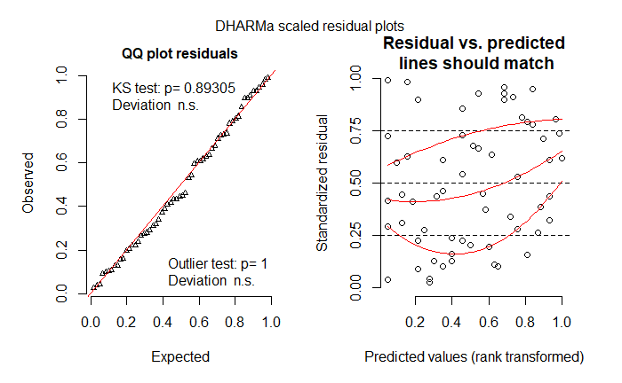

`r`r testOverdispersion(ofrostfire1.res)

```
testOverdispersion is deprecated, switch your code to using the testDispersion function

    DHARMa nonparametric dispersion test via sd of residuals fitted vs. simulated

data:  simulationOutput
ratioObsSim = 0.93102, p-value = 0.784
alternative hypothesis: two.sided
```

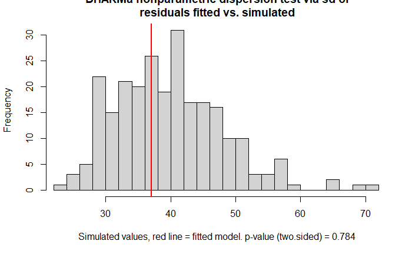

#### Summary

`r`r summary(ofrostfire1)

```
Call:
glm.nb(formula = seedling.ct ~ frost.events:fire.type + offset(log(seedling.area)),
    data = seed_clim_out, init.theta = 0.8117805378, link = log)

Deviance Residuals:
    Min       1Q   Median       3Q      Max
-2.4370  -1.0765  -0.4919   0.1992   2.1005

Coefficients:
                               Estimate Std. Error z value Pr(>|z|)
(Intercept)                    -6.02277    4.19352  -1.436    0.151
frost.events:fire.typecrown     0.02329    0.01955   1.191    0.234
frost.events:fire.typesev.surf  0.02387    0.01978   1.207    0.227
frost.events:fire.typesurface   0.02262    0.01974   1.146    0.252

(Dispersion parameter for Negative Binomial(0.8118) family taken to be 1)

    Null deviance: 72.857  on 59  degrees of freedom
Residual deviance: 70.572  on 56  degrees of freedom
AIC: 553.97

Number of Fisher Scoring iterations: 1

              Theta:  0.812
          Std. Err.:  0.141

 2 x log-likelihood:  -543.971
```

#### Estimates

`r`r ( ofrostfire1.est = cbind(Estimate = coef(ofrostfire1), confint(ofrostfire1)))

```
                                  Estimate        2.5 %     97.5 %
(Intercept)                    -6.02276794 -15.22052697 3.10363828
frost.events:fire.typecrown     0.02328960  -0.01885032 0.06603726
frost.events:fire.typesev.surf  0.02387112  -0.01861958 0.06716539
frost.events:fire.typesurface   0.02262140  -0.02067835 0.06660615
```

`r`r ( exp(ofrostfire1.est))

```
                                  Estimate        2.5 %    97.5 %
(Intercept)                    0.002422954 2.453630e-07 22.278861
frost.events:fire.typecrown    1.023562924 9.813262e-01  1.068267
frost.events:fire.typesev.surf 1.024158320 9.815527e-01  1.069472
frost.events:fire.typesurface  1.022879202 9.795340e-01  1.068874
```

`r`r ofrost_estimate=exp(coef(ofrostfire1)) ofrost_lcl_ucl=exp(confint(ofrostfire1))

`r`r ofrost_p_value=summary(ofrostfire1)$coefficients[,4]

#### Predict Frost*Fire

`r`r preddat.ofrostfire1 = data.frame(frost.events = seed_clim_out$frost.events, fire.type = factor(seed_clim_out$fire.type), seedling.area = 100) head(preddat.ofrostfire1) r predofrostfire1 = predict(ofrostfire1, newdata = preddat.ofrostfire1, se.fit = TRUE) ULofrostfire1 = with(predofrostfire1, fit + 1.96*se.fit) LLofrostfire1 = with(predofrostfire1, fit - 1.96*se.fit) seed_clim_out = mutate(seed_clim_out, predofrostfire1 = exp(predofrostfire1$fit), ULofrostfire1 = exp(ULofrostfire1), LLofrostfire1 = exp(LLofrostfire1), seedling.area = 100)

|  | frost.events | fire.type | seedling.area |
| --- | --- | --- | --- |
| 1 | 209 | sev.surf | 100 |
| 2 | 214 | sev.surf | 100 |
| 3 | 215 | surface | 100 |
| 4 | 214 | sev.surf | 100 |
| 5 | 212 | crown | 100 |
| 6 | 214 | surface | 100 |

#### Figure with raw data

`r`r pofrostfire1 = ggplot(data = seed_clim_out, aes(x = frost.events, y = seedling.ct, color = factor(fire.type))) + geom_point(size = 2) + geom_line(aes(y=LLofrostfire1, color = factor(fire.type)), linetype = ‘longdash’, size = 1) + geom_line(aes(y=ULofrostfire1, color = factor(fire.type)), linetype=‘longdash’, size = 1) + scale_linetype(guide = ) pofrostfire2 = pofrostfire1 + geom_ribbon(aes(ymin=LLofrostfire1, ymax=ULofrostfire1, fill= fire.type), linetype = 0, alpha=.25, show.legend = FALSE) + scale_fill_manual(values=c(#f03b20, #feb24c, #91cf60), guide = FALSE) ( pofrostfire3 = pofrostfire2 + geom_line(aes(y = predofrostfire1, color = factor(fire.type)), linetype = 1, size = 2) + scale_color_manual(values = c(#f03b20, #feb24c, #91cf60), name=Severity, breaks=c(, .surf, ), labels=c(, surface, surface)) + ylab(count) + xlab(Frost Days) + theme_bw() + theme(legend.position = ) + theme(plot.margin = unit(c(t = 0.3, r = 0.1, b = 0.3, l = 0.1), )) + theme(axis.title.x = element_text(size = 11, hjust = 0.5, vjust = -0.1), axis.title.y = element_text(size = 11, hjust = 0.5, vjust = 1.1), axis.text.x = element_text(size = 10, color = ), axis.text.y = element_text(size = 10, color = ), panel.background = element_blank(), axis.line = element_line(colour = )) )

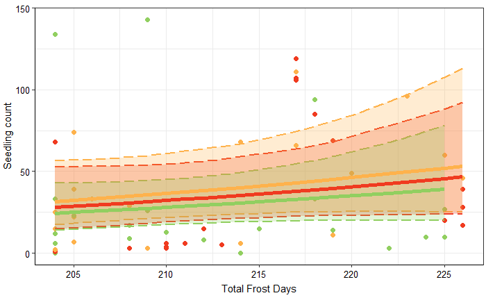

#### Figure without raw data

`r`r pofrostfire4 = ggplot(data = seed_clim_out, aes(x = frost.events, y = seedling.ct, color = factor(fire.type))) + geom_line(aes(y=LLofrostfire1, color = factor(fire.type)), linetype = ‘longdash’, size = 1) + geom_line(aes(y=ULofrostfire1, color = factor(fire.type)), linetype=‘longdash’, size = 1) + scale_linetype(guide = ) pofrostfire5 = pofrostfire4 + geom_ribbon(aes(ymin=LLofrostfire1, ymax=ULofrostfire1, fill= fire.type), linetype = 0, alpha=.25, show.legend = FALSE) + scale_fill_manual(values=c(#f03b20, #feb24c, #91cf60), guide = FALSE) ( pofrostfire6 = pofrostfire5 + geom_line(aes(y = predofrostfire1, color = factor(fire.type)), linetype = 1, size = 2) + scale_color_manual(values = c(#f03b20, #feb24c, #91cf60), name=Severity, breaks=c(, .surf, ), labels=c(, surface, surface)) + ylab(count) + xlab(Frost Days) + theme_bw() + theme(legend.position = ) + theme(plot.margin = unit(c(t = 0.3, r = 0.1, b = 0.3, l = 0.1), )) + theme(axis.title.x = element_text(size = 11, hjust = 0.5, vjust = -0.1), axis.title.y = element_text(size = 11, hjust = 0.5, vjust = 1.1), axis.text.x = element_text(size = 10, color = ), axis.text.y = element_text(size = 10, color = ), panel.background = element_blank(), axis.line = element_line(colour = )) )

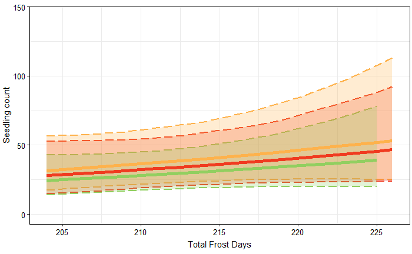

## Model: Snow & fire

`r`r osnowfire1 = glm.nb(seedling.ct ~ sum_PAS:fire.type + offset(log(seedling.area)), data = seed_clim_out)

### Residuals with DHARMa

`r`r plotSimulatedResiduals(simulationOutput = osnowfire1.res)

```
plotSimulatedResiduals is deprecated, switch your code to using the plot function
```

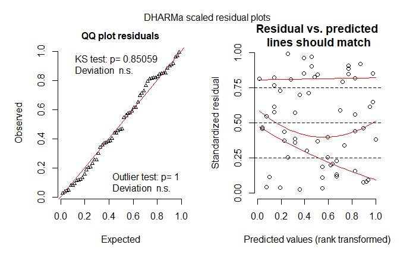

`r`r testOverdispersion(osnowfire1.res)

```
testOverdispersion is deprecated, switch your code to using the testDispersion function

    DHARMa nonparametric dispersion test via sd of residuals fitted vs. simulated

data:  simulationOutput
ratioObsSim = 0.91784, p-value = 0.768
alternative hypothesis: two.sided
```

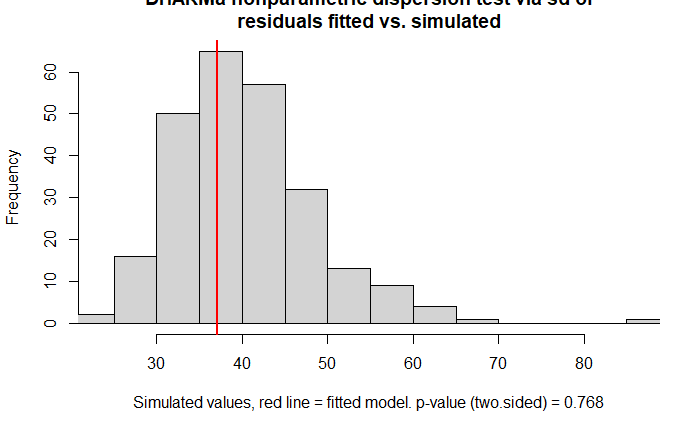

#### Summary

`r`r summary(osnowfire1)

```
Call:
glm.nb(formula = seedling.ct ~ sum_PAS:fire.type + offset(log(seedling.area)),
    data = seed_clim_out, init.theta = 0.8333535009, link = log)

Deviance Residuals:
    Min       1Q   Median       3Q      Max
-2.4508  -1.2462  -0.4966   0.4854   1.9586

Coefficients:
                          Estimate Std. Error z value Pr(>|z|)
(Intercept)                7.57189    5.14309   1.472   0.1410
sum_PAS:fire.typecrown    -0.04613    0.02757  -1.673   0.0943 .
sum_PAS:fire.typesev.surf -0.04496    0.02746  -1.637   0.1015
sum_PAS:fire.typesurface  -0.04748    0.02739  -1.733   0.0831 .
---
Signif. codes:  0 â***â 0.001 â**â 0.01 â*â 0.05 â.â 0.1 â â 1

(Dispersion parameter for Negative Binomial(0.8334) family taken to be 1)

    Null deviance: 74.599  on 59  degrees of freedom
Residual deviance: 70.420  on 56  degrees of freedom
AIC: 552.16

Number of Fisher Scoring iterations: 1

              Theta:  0.833
          Std. Err.:  0.145

 2 x log-likelihood:  -542.160
```

#### Estimates

`r`r ( osnowfire1.est = cbind(Estimate = coef(osnowfire1), confint(osnowfire1)))

```
                             Estimate       2.5 %       97.5 %
(Intercept)                7.57188844 -2.12298932 16.862963240
sum_PAS:fire.typecrown    -0.04612767 -0.09572241  0.006148307
sum_PAS:fire.typesev.surf -0.04496232 -0.09390876  0.006515166
sum_PAS:fire.typesurface  -0.04747715 -0.09718715  0.004689114
```

`r`r ( exp(osnowfire1.est))

```
                              Estimate     2.5 %       97.5 %
(Intercept)               1942.8056970 0.1196734 2.106163e+07
sum_PAS:fire.typecrown       0.9549200 0.9087162 1.006167e+00
sum_PAS:fire.typesev.surf    0.9560335 0.9103658 1.006536e+00
sum_PAS:fire.typesurface     0.9536323 0.9073862 1.004700e+00
```

`r`r osnow_estimate=exp(coef(osnowfire1)) osnow_lcl_ucl=exp(confint(osnowfire1))

`r`r osnow_p_value=summary(osnowfire1)$coefficients[,4]

`r`r preddat.osnowfire1 = data.frame(sum_PAS = seed_clim_out$sum_PAS, fire.type = factor(seed_clim_out$fire.type), seedling.area = 100) head(preddat.osnowfire1) r predosnowfire1 = predict(osnowfire1, newdata = preddat.osnowfire1, se.fit = TRUE) ULosnowfire1 = with(predosnowfire1, fit + 1.96*se.fit) LLosnowfire1 = with(predosnowfire1, fit - 1.96*se.fit) seed_clim_out = mutate(seed_clim_out, predosnowfire1 = exp(predosnowfire1$fit), ULosnowfire1 = exp(ULosnowfire1), LLosnowfire1 = exp(LLosnowfire1), seedling.area = 100)

|  | sum_PAS | fire.type | seedling.area |
| --- | --- | --- | --- |
| 1 | 184 | sev.surf | 100 |
| 2 | 192 | sev.surf | 100 |
| 3 | 194 | surface | 100 |
| 4 | 190 | sev.surf | 100 |
| 5 | 187 | crown | 100 |
| 6 | 194 | surface | 100 |

#### Figure with raw data

`r`r posnowfire1 = ggplot(data = seed_clim_out, aes(x = sum_PAS, y = seedling.ct, color = factor(fire.type))) + geom_point(size = 2) + geom_line(aes(y=LLosnowfire1, color = factor(fire.type)), linetype = ‘longdash’, size = 1) + geom_line(aes(y=ULosnowfire1, color = factor(fire.type)), linetype=‘longdash’, size = 1) + scale_linetype(guide = ) posnowfire2 = posnowfire1 + geom_ribbon(aes(ymin=LLosnowfire1, ymax=ULosnowfire1, fill= fire.type), linetype = 0, alpha=.25, show.legend = FALSE) + scale_fill_manual(values=c(#f03b20, #feb24c, #91cf60), guide = FALSE)  
( posnowfire3 = posnowfire2 + geom_line(aes(y = predosnowfire1, color = factor(fire.type)), linetype = 1, size = 2) + scale_color_manual(values = c(#f03b20, #feb24c, #91cf60), name=Severity, breaks=c(, .surf, ), labels=c(, surface, surface)) + ylab(count) + xlab((mm)) + theme_bw() + theme(legend.position = ) + theme(plot.margin = unit(c(t = 0.3, r = 0.1, b = 0.3, l = 0.1), )) + theme(axis.title.x = element_text(size = 11, hjust = 0.5, vjust = -0.1), axis.title.y = element_text(size = 11, hjust = 0.5, vjust = 1.1), axis.text.x = element_text(size = 10, color = ), axis.text.y = element_text(size = 10, color = ), panel.background = element_blank(), axis.line = element_line(colour = )) )

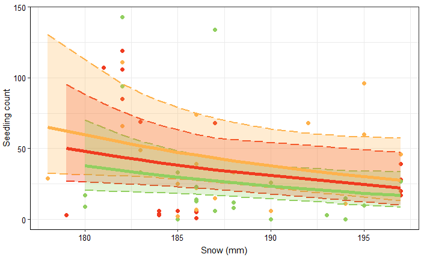

#### Figure without raw data

`r`r posnowfire4 = ggplot(data = seed_clim_out, aes(x = sum_PAS, y = seedling.ct, color = factor(fire.type))) + geom_line(aes(y=LLosnowfire1, color = factor(fire.type)), linetype = ‘longdash’, size = 1) + geom_line(aes(y=ULosnowfire1, color = factor(fire.type)), linetype=‘longdash’, size = 1) + scale_linetype(guide = ) posnowfire5 = posnowfire4 + geom_ribbon(aes(ymin=LLosnowfire1, ymax=ULosnowfire1, fill= fire.type), linetype = 0, alpha=.25, show.legend = FALSE) + scale_fill_manual(values=c(#f03b20, #feb24c, #91cf60), guide = FALSE)  
( posnowfire6 = posnowfire5 + geom_line(aes(y = predosnowfire1, color = factor(fire.type)), linetype = 1, size = 2) + scale_color_manual(values = c(#f03b20, #feb24c, #91cf60), name=Severity, breaks=c(, .surf, ), labels=c(, surface, surface)) + ylab(count) + xlab((mm)) + theme_bw() + theme(legend.position = ) + theme(plot.margin = unit(c(t = 0.3, r = 0.1, b = 0.3, l = 0.1), )) + theme(axis.title.x = element_text(size = 11, hjust = 0.5, vjust = -0.1), axis.title.y = element_text(size = 11, hjust = 0.5, vjust = 1.1), axis.text.x = element_text(size = 10, color = ), axis.text.y = element_text(size = 10, color = ), panel.background = element_blank(), axis.line = element_line(colour = )) )

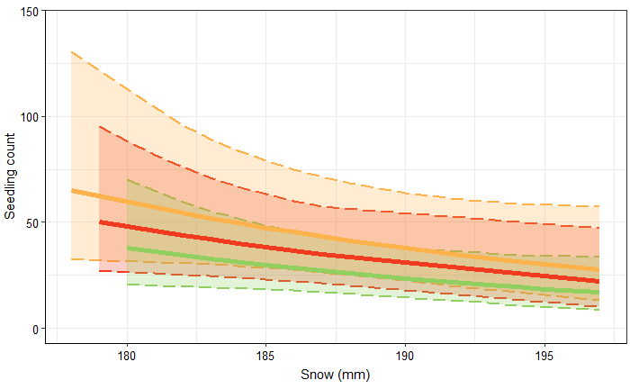

## Model: CMD & fire

`r`r oCMDfire1 = glm.nb(seedling.ct ~ sum_CMD:fire.type + offset(log(seedling.area)), data = seed_clim_out)

### Residuals with DHARMa

`r`r plotSimulatedResiduals(simulationOutput = oCMDfire1.res)

```
plotSimulatedResiduals is deprecated, switch your code to using the plot function
```

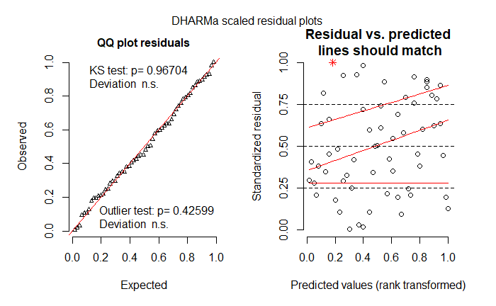

`r`r testOverdispersion(oCMDfire1.res)

```
testOverdispersion is deprecated, switch your code to using the testDispersion function

    DHARMa nonparametric dispersion test via sd of residuals fitted vs. simulated

data:  simulationOutput
ratioObsSim = 0.88791, p-value = 0.664
alternative hypothesis: two.sided
```

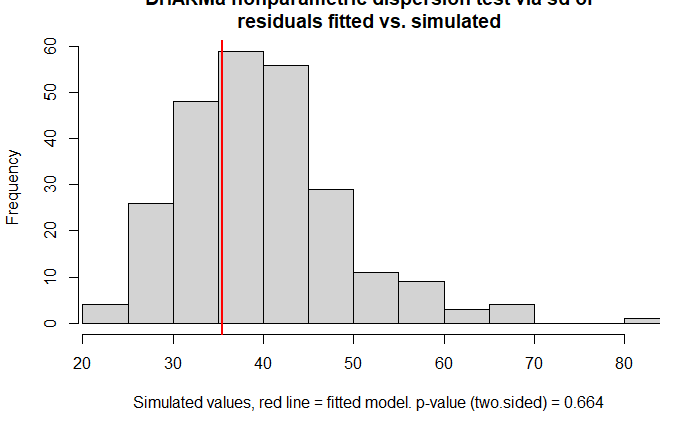

#### Summary

`r`r summary(oCMDfire1)

```
Call:
glm.nb(formula = seedling.ct ~ sum_CMD:fire.type + offset(log(seedling.area)),
    data = seed_clim_out, init.theta = 0.9093029377, link = log)

Deviance Residuals:
    Min       1Q   Median       3Q      Max
-2.5373  -1.0177  -0.4418   0.2002   2.9576

Coefficients:
                           Estimate Std. Error z value Pr(>|z|)
(Intercept)                8.522808   3.023364   2.819  0.00482 **
sum_CMD:fire.typecrown    -0.027790   0.008503  -3.268  0.00108 **
sum_CMD:fire.typesev.surf -0.026850   0.008564  -3.135  0.00172 **
sum_CMD:fire.typesurface  -0.026904   0.008456  -3.182  0.00146 **
---
Signif. codes:  0 â***â 0.001 â**â 0.01 â*â 0.05 â.â 0.1 â â 1

(Dispersion parameter for Negative Binomial(0.9093) family taken to be 1)

    Null deviance: 80.683  on 59  degrees of freedom
Residual deviance: 70.040  on 56  degrees of freedom
AIC: 546.32

Number of Fisher Scoring iterations: 1

              Theta:  0.909
          Std. Err.:  0.161

 2 x log-likelihood:  -536.320
```

#### Estimates

`r`r ( oCMDfire1.est = cbind(Estimate = coef(oCMDfire1), confint(oCMDfire1)))

```
                             Estimate       2.5 %       97.5 %
(Intercept)                8.52280770  2.48637793 14.605182453
sum_CMD:fire.typecrown    -0.02778972 -0.04525243 -0.010239806
sum_CMD:fire.typesev.surf -0.02684999 -0.04396501 -0.009691786
sum_CMD:fire.typesurface  -0.02690431 -0.04344564 -0.010306154
```

`r`r ( exp(oCMDfire1.est))

```
                              Estimate      2.5 %       97.5 %
(Intercept)               5028.1514960 12.0176683 2.202674e+06
sum_CMD:fire.typecrown       0.9725929  0.9557562 9.898124e-01
sum_CMD:fire.typesev.surf    0.9735073  0.9569874 9.903550e-01
sum_CMD:fire.typesurface     0.9734544  0.9574846 9.897468e-01
```

`r`r summary(oCMDfire1)$coefficients[,4]

```
              (Intercept)    sum_CMD:fire.typecrown sum_CMD:fire.typesev.surf
              0.004817630               0.001082383               0.001718133
 sum_CMD:fire.typesurface
              0.001463794
```

`r`r ocmd_estimate=exp(coef(oCMDfire1)) ocmd_lcl_ucl=exp(confint(oCMDfire1))

`r`r ocmd_p_value=summary(oCMDfire1)$coefficients[,4]

`r`r out_df=data.frame(ofrost_estimate, ofrost_lcl_ucl, ofrost_p_value, osnow_estimate, osnow_lcl_ucl, osnow_p_value, ocmd_estimate, ocmd_lcl_ucl, ocmd_p_value) out_df r write.csv(out_df, ‘../output/2019-02-06_climate_fire_outliers.csv’, row.names = F)

|  | ofrost_estimate | X2.5.. | X97.5.. | ofrost_p_value | osnow_estimate | X2.5...1 | X97.5...1 | osnow_p_value | ocmd_estimate | X2.5...2 | X97.5...2 | ocmd_p_value |
| --- | --- | --- | --- | --- | --- | --- | --- | --- | --- | --- | --- | --- |
| (Intercept) | 0.002422954 | 2.453630e-07 | 22.278861 | 0.1509429 | 1942.8056970 | 0.1196734 | 2.106163e+07 | 0.14095442 | 5028.1514960 | 12.0176683 | 2.202674e+06 | 0.004817630 |
| frost.events:fire.typecrown | 1.023562924 | 9.813262e-01 | 1.068267 | 0.2336555 | 0.9549200 | 0.9087162 | 1.006167e+00 | 0.09432080 | 0.9725929 | 0.9557562 | 9.898124e-01 | 0.001082383 |
| frost.events:fire.typesev.surf | 1.024158320 | 9.815527e-01 | 1.069472 | 0.2274957 | 0.9560335 | 0.9103658 | 1.006536e+00 | 0.10153410 | 0.9735073 | 0.9569874 | 9.903550e-01 | 0.001718133 |
| frost.events:fire.typesurface | 1.022879202 | 9.795340e-01 | 1.068874 | 0.2518335 | 0.9536323 | 0.9073862 | 1.004700e+00 | 0.08305502 | 0.9734544 | 0.9574846 | 9.897468e-01 | 0.001463794 |

`r`r preddat.ocmdfire1 = data.frame(sum_CMD = seed_clim_out$sum_CMD, fire.type = factor(seed_clim_out$fire.type), seedling.area = 100) head(preddat.ocmdfire1) r predocmdfire1 = predict(oCMDfire1, newdata = preddat.ocmdfire1, se.fit = TRUE) ULocmdfire1 = with(predocmdfire1, fit + 1.96*se.fit) LLocmdfire1 = with(predocmdfire1, fit - 1.96*se.fit) seed_clim_out = mutate(seed_clim_out, predocmdfire1 = exp(predocmdfire1$fit), ULocmdfire1 = exp(ULocmdfire1), LLocmdfire1 = exp(LLocmdfire1), seedling.area = 100)

|  | sum_CMD | fire.type | seedling.area |
| --- | --- | --- | --- |
| 1 | 379 | sev.surf | 100 |
| 2 | 365 | sev.surf | 100 |
| 3 | 365 | surface | 100 |
| 4 | 366 | sev.surf | 100 |
| 5 | 373 | crown | 100 |
| 6 | 364 | surface | 100 |

#### Figure with raw data

`r`r pocmdfire1 = ggplot(data = seed_clim_out, aes(x = sum_CMD, y = seedling.ct, color = factor(fire.type))) + geom_point(size = 2) + geom_line(aes(y=LLocmdfire1, color = factor(fire.type)), linetype = ‘longdash’, size = 1) + geom_line(aes(y=ULocmdfire1, color = factor(fire.type)), linetype=‘longdash’, size = 1) + scale_linetype(guide = ) pocmdfire2 = pocmdfire1 + geom_ribbon(aes(ymin=LLocmdfire1, ymax=ULocmdfire1, fill= fire.type), linetype = 0, alpha=.25, show.legend = FALSE) + scale_fill_manual(values=c(#f03b20, #feb24c, #91cf60), guide = FALSE)  
( pocmdfire3 = pocmdfire2 + geom_line(aes(y = predocmdfire1, color = factor(fire.type)), linetype = 1, size = 2) + scale_color_manual(values = c(#f03b20, #feb24c, #91cf60), name=Severity, breaks=c(, .surf, ), labels=c(, surface, surface)) + ylab(count) + xlab() + theme_bw() + theme(legend.position = ) + theme(plot.margin = unit(c(t = 0.3, r = 0.1, b = 0.3, l = 0.1), )) + theme(axis.title.x = element_text(size = 11, hjust = 0.5, vjust = -0.1), axis.title.y = element_text(size = 11, hjust = 0.5, vjust = 1.1), axis.text.x = element_text(size = 10, color = ), axis.text.y = element_text(size = 10, color = ), panel.background = element_blank(), axis.line = element_line(colour = )) )

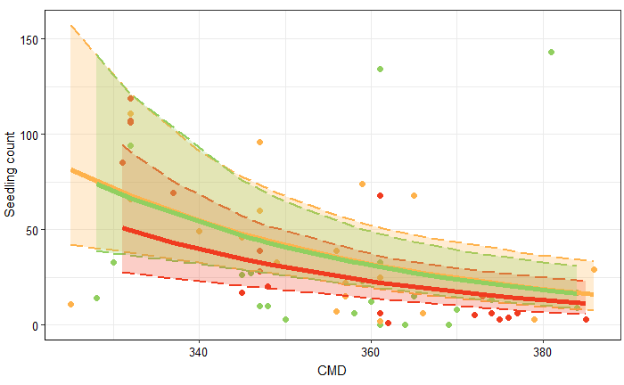

#### Figure without raw data

`r`r pocmdfire4 = ggplot(data = seed_clim_out, aes(x = sum_CMD, y = seedling.ct, color = factor(fire.type))) + geom_line(aes(y=LLocmdfire1, color = factor(fire.type)), linetype = ‘longdash’, size = 1) + geom_line(aes(y=ULocmdfire1, color = factor(fire.type)), linetype=‘longdash’, size = 1) + scale_linetype(guide = ) pocmdfire5 = pocmdfire4 + geom_ribbon(aes(ymin=LLocmdfire1, ymax=ULocmdfire1, fill= fire.type), linetype = 0, alpha=.25, show.legend = FALSE) + scale_fill_manual(values=c(#f03b20, #feb24c, #91cf60), guide = FALSE)  
( pocmdfire6 = pocmdfire5 + geom_line(aes(y = predocmdfire1, color = factor(fire.type)), linetype = 1, size = 2) + scale_color_manual(values = c(#f03b20, #feb24c, #91cf60), name=Severity, breaks=c(, .surf, ), labels=c(, surface, surface)) + ylab(count) + xlab(moisture deficit (mm)) + ylim(0, 200) + theme_bw() + theme(legend.position = ) + theme(plot.margin = unit(c(t = 0.3, r = 0.1, b = 0.3, l = 0.1), )) + theme(axis.title.x = element_text(size = 11, hjust = 0.5, vjust = -0.1), axis.title.y = element_text(size = 11, hjust = 0.5, vjust = 1.1), axis.text.x = element_text(size = 10, color = ), axis.text.y = element_text(size = 10, color = ), panel.background = element_blank(), axis.line = element_line(colour = )) )

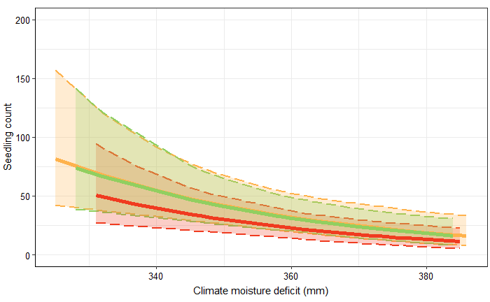

#### Legend

`r`r legend1 = ggplot(data = seed_clim_out, aes(x = sum_CMD, y = seedling.ct, color = factor(fire.type))) + geom_line(aes(y=LLocmdfire1, color = factor(fire.type)), linetype = ‘longdash’, size = 1) + geom_line(aes(y=ULocmdfire1, color = factor(fire.type)), linetype=‘longdash’, size = 1) + scale_linetype(guide = ) legend2 = legend1 + geom_ribbon(aes(ymin=LLocmdfire1, ymax=ULocmdfire1, fill= fire.type), linetype = 0, alpha=.25, show.legend = FALSE) + scale_fill_manual(values=c(#f03b20, #feb24c, #91cf60), guide = FALSE)  
( legend3 = legend2 + geom_line(aes(y = predocmdfire1, color = factor(fire.type)), linetype = 1, size = 2) + scale_color_manual(values = c(#f03b20, #feb24c, #91cf60), name=Severity, breaks=c(, .surf, ), labels=c(, surface, surface)) + ylab(count) + xlab() + theme_bw() + theme(legend.title = element_text(size = 10), legend.position = ) + theme(plot.margin = unit(c(t = 0.3, r = 0.1, b = 0.3, l = 0.1), )) + theme(axis.title.x = element_text(size = 11, hjust = 0.5, vjust = -0.1), axis.title.y = element_text(size = 11, hjust = 0.5, vjust = 1.1), axis.text.x = element_text(size = 10, color = ), axis.text.y = element_text(size = 10, color = ), panel.background = element_blank(), axis.line = element_line(colour = )) )

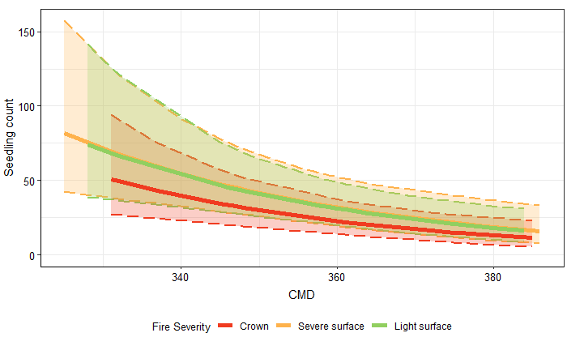

# Figures Grid

`r`r gridcmd=cowplot::plot_grid(pcmdfire3, pocmdfire3, labels = c(, ), align = , ncol= 2)

`r`r gridsnow=cowplot::plot_grid(psnowfire3, posnowfire3, labels = c(, ), align = , ncol= 2)

`r`r gridfrost=cowplot::plot_grid(pfrostfire3, pofrostfire3, labels = c(, ), align = , ncol= 2)

## Grid graph all climate variables

`r`r legend = cowplot::get_legend(legend3) gridall1=cowplot::plot_grid(pfrostfire6, psnowfire6, pcmdfire6, pocmdfire6, labels = c(, ,,), align = , ncol= 2) + draw_label(*, x = .98, y = .165, size = 20, fontface = ) + draw_label(*, x = .98, y = .147, size = 20, fontface = ) + draw_label(*, x = .98, y = .13, size = 20, fontface = ) + draw_label(*, x = .98, y = .66, size = 20, fontface = ) + draw_label(*, x = .98, y = .645, size = 20, fontface = ) + draw_label(*, x = .98, y = .63, size = 20, fontface = ) (gridall2 = plot_grid(gridall1, legend, ncol=1, rel_widths = c(1, .1), rel_heights = c(1, .05)) )

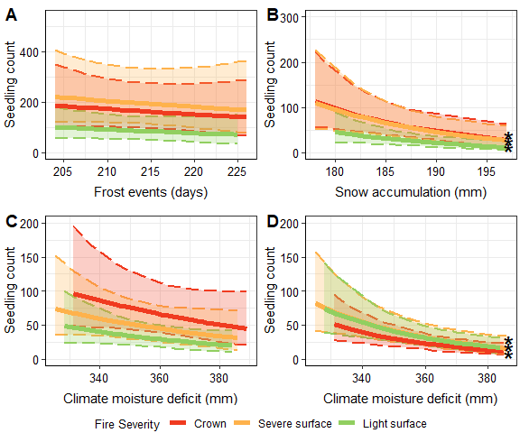

**THE END**